# Analysis - Temperature - All models

Tom Offrede

# Summary of Results

- Most people increased the temperature in most of their ROIs, with some exceptions.

**Significant number of increases/decreases in temperature** (per speaker)

- There were overall **more significant increases** in the **impersonal** condition. In more detail:
  - First part of experiment (**Question lists**)
    - none
  - Second part of experiment (**Diapix**)
    - All ROIs together: more increases in *impersonal*; more changes overall in *impersonal*
    - Forehead: more increases in *impersonal* (adjusted p a bit above .05)
    - Cheeks: more increases in *impersonal* (adjusted p slightly above .05)
  - Across the entire experiment
    - Cheeks: more increases in *impersonal* (adjusted p above .05)
- Sometimes, there were a few temperature decreases in the close condition, but no decreases in the impersonal condition. This was true for the following:
  - First part of experiment (**Question lists**)
    - Eyes
    - Forehead
  - Second part of experiment (**Diapix**)
    - Eyes
    - Forehead
- Some effects of perception of partner:
  - First part of experiment (**Lists**)
    - Nose temperature *increased more often* when the speaker wanted *more* to be friends.
  - Second part of experiment (**Diapix**)
    - Nose temperature *decreased less often* when the speaker wanted *more* to be *friends*.
    - Eye temperature *increased less often* when the speaker felt *closer* to their partner.
    - Forehead temperature *increased less often* when the speaker *liked* their partner *more*.
- Some effects of personality scores:
  - First part of experiment (**Lists**)
    - Cheek temperature *increased less often* when the speaker scored higher in *agreeableness*.
  - Second part of experiment (**Diapix**)
    - Nose temperature *increased less often* when the speaker scored higher in *extraversion*.
    - Nose temperature *increased and decreased less often* when the speaker scored higher in *openness*.
    - Eye temperature *increased less often* when the speaker scored higher in *agreeableness*.
    - Forehead temperature *increased less often* when the speaker scored higher in *extraversion*.
    - Forehead temperature *increased less often* when the speaker scored higher in *openness* (small effect).
    - Cheek temperature *increased less often* when the speaker scored higher in *agreeableness*.
  - Across the entire experiment
    - Eye temperature *increased less often* when the speaker scored higher in *neuroticism*.
    - Cheek temperature *increased less often* when the speaker scored higher in *agreeableness*.
- Some effects of thermal comfort:
  - Second part of the experiment (**Diapix**)
    - Nose temperature had *increased and decreased less often* when the speaker felt more comfortable at the end of the experiment.

**Participants’ temperature change across experiment** (all speakers together)

- All ROIs *except cheeks* increased temperature reliably (accounting for room temperature).
- There was no overall condition effect.
- Some effects of perception of partner:
  - Second part of experiment (**Diapix**)
    - Forehead temperature change was *less positive* when the speaker *liked* their partner *more*. (and almost significant effects in the same direction here for feelings of *closeness* and *similarity*)
  - Across the entire experiment
    - Forehead temperature change was *less positive* when the speaker *liked* their partner *more*. (and almost significant effects in the same direction here for feelings of *similarity* and *wanting to be friends*)
    - Cheek temperature change was *less positive* when the speaker *liked* their partner *more*.
- Some effects of personality scores:
  - First part of experiment (**Question lists**)
    - Nose temperature change was *less positive* when the speaker scored higher in *extraversion*.
    - Forehead temperature change was *more positive* when the speaker scored higher in *agreeableness*.
  - Second part of experiment (**Diapix**)
    - Forehead temperature change was *less positive* when the speaker scored higher in *extraversion*.
    - Cheek temperature change was *less positive* when the speaker scored higher in *agreeableness*.
  - Across the entire experiment
    - Nose temperature change was *less positive* when the speaker scored higher in *extraversion*.
    - Forehead temperature change was *less positive* when the speaker scored higher in *openness*.

**Temperature convergence**

- Some dyads converged or diverged in some ROIs, but there were no significant effects of condition.

# Notes

- There are 2 types of analysis:
  - Run a regression on ROI’s temperature ~ time passing *for each speaker*, and then use the result of these regressions (significant increase, significant decrease, not significant) as a dependent variable of other predictors (e.g., condition and questionnaire ratings)
  - Run a regression with the speakers’ absolute temperature change across the experiment (numerical) and use this as a dependent variable of other predictors.
- In the models of temperature change across time, I originally wanted to add `room temperature` as a predictor to account for the increasing room temperature. However, there is high collinearity between `room temperature` and `time`, so the models don’t make sense. Hence, only `time` is kept.
- There are 2 conditions: `close`, where in the first task of the experiment the participants talked about increasingly intimate questions (adapted from the Relationship Closeness Induction Task), and `impersonal`, where they talked about impersonal questions.
- The check of residuals of logistic models below, was done following: https://cran.r-project.org/web/packages/DHARMa/vignettes/DHARMa.html

# Individual plots

See folder: R project temperatureExp > figures > temperature > tempChange OR convergence

```r
# for(roi in unique(dat$ROI)){
#   ggplot(dat |> filter(ROI==roi), aes(time, temperature, color=speaker))+
#     geom_point()+
#     geom_smooth(method="lm")+
#     facet_wrap(~dyad, scales = "free_x")+
#     ggtitle(roi)
#   ggsave(paste0(folderFig1, roi, ".png"), width=3000, height=2600, units = "px")
#
#   for(con in unique(dat$condition)){
#     ggplot(dat |> filter(ROI==roi, condition==con), aes(time, temperature, color=speaker))+
#     geom_point()+
#     geom_smooth(method="lm")+
#     facet_wrap(~dyad, scales = "free_x")+
#     ggtitle(paste(roi, "-", con, "condition"))
#   ggsave(paste0(folderFig1, "/", con, "/", roi, ".png"), width=3000, height=2600, units = "px")
#   }
# }
```

```r
# for(roi in unique(dat$ROI)){
#   d <- dat |>
#     filter(ROI==roi) |>
#     group_by(speaker) |>
#     filter(length(unique(task))==2) |>
#     ungroup()
#     ggplot(d, aes(time, temperature, color=task))+
#       geom_point()+
#       geom_smooth(method="lm")+
#       facet_wrap(~speaker, scales = "free_x")+
#       ggtitle(roi)
#     ggsave(paste0(folderFig1, roi, "PerTask.png"), width=3000, height=2600, units = "px")
# }
```

```r
# for(roi in unique(dat$ROI)){
#   ggplot(dat |> filter(ROI==roi, grepl("-A", speaker)), aes(time, tempDiff))+
#     geom_point()+
#     geom_smooth(method="lm")+
#     facet_wrap(~dyad, scales = "free_x")+
#     ggtitle(roi)
#   ggsave(paste0(folderFig2, roi, ".png"), width=3000, height=2600, units = "px")
#
#   for(con in unique(dat$condition)){
#     ggplot(dat |> filter(ROI==roi, grepl("-A", speaker), condition==con), aes(time, tempDiff))+
#     geom_point()+
#     geom_smooth(method="lm")+
#     facet_wrap(~dyad, scales = "free_x")+
#     ggtitle(paste(roi, "-", con, "condition"))
#   ggsave(paste0(folderFig2, "/", con, "/", roi, ".png"), width=3000, height=2600, units = "px")
#   }
# }
```

# Temperature change across time and across conditions

## Per speaker

```r
all <- data.frame(matrix(nrow=0, ncol=7))
names(all) <- c("speaker", "condition", "ROI", "direction", "t", "p", "section")
```

```r
for(s in unique(dat$speaker)){
  for(r in unique(dat$ROI)){
    d <- dat |> filter(speaker==s, ROI==r)
    if(nrow(d)<=1){next}
    c <- tidy(lm(tempz ~ time, d))
    all[nrow(all)+1,] <- c(s, unique(d$condition), r,
                           ifelse(c$estimate[2] < 0, "negative", "positive"),
                           c$statistic[2],
                           c$p.value[2],
                           "entireExp")
    for(section in c("Lists", "Diapix")){
      d <- dat |> filter(speaker==s, ROI==r, task==section)
      if(nrow(d)==0){next}
      c <- tidy(lm(tempz ~ time, d))
      all[nrow(all)+1,] <- c(s, unique(d$condition), r,
                             ifelse(c$estimate[2] < 0, "negative", "positive"),
                             c$statistic[2],
                             c$p.value[2],
                             section)
    }
  }
}

all <- all |>
  mutate_at(c("t", "p"), as.numeric) |>
  mutate(sign = ifelse(p < 0.05, "yes", "ns"),
         effect = case_when(
           sign == "yes" & direction == "positive" ~ "increase",
           sign == "yes" & direction == "negative" ~ "decrease",
           sign == "ns" ~ "ns",
         )) |>
  mutate_at(c("direction", "speaker", "effect", "condition", "section", "ROI"), as.factor)

all$section <- factor(all$section, levels=c("Lists", "Diapix", "entireExp"))
all$effect <- relevel(all$effect, ref="ns")

# # save it
# indTemp <- all
# save(indTemp, file=paste0(here::here(), "/data/individualTemp.RData"))
```

```r
table(paste(all$sign, all$section))
```

```
##
##     ns Diapix  ns entireExp      ns Lists    yes Diapix yes entireExp
##            63            34            60            82           113
##     yes Lists
##            71
```

But the direction of temperature change was always the same (mostly positive) in each section.

The individual plots divided per 1st vs 2nd part of experiment show that most participants had a linear change across the experiment, but not all.

```r
summary(glmer(direction ~ section + (1|speaker), all |> filter(section!="entireExp"), family=binomial))
```

```
## Generalized linear mixed model fit by maximum likelihood (Laplace
##   Approximation) [glmerMod]
##  Family: binomial  ( logit )
## Formula: direction ~ section + (1 | speaker)
##    Data: filter(all, section != "entireExp")
##
##      AIC      BIC   logLik deviance df.resid
##    291.7    302.6   -142.9    285.7      273
##
## Scaled residuals:
##     Min      1Q  Median      3Q     Max
## -2.4880  0.2883  0.3362  0.4582  1.0615
##
## Random effects:
##  Groups  Name        Variance Std.Dev.
##  speaker (Intercept) 1.423    1.193
## Number of obs: 276, groups:  speaker, 38
##
## Fixed effects:
##               Estimate Std. Error z value Pr(>|z|)
## (Intercept)     1.5415     0.3288   4.688 2.75e-06 ***
## sectionDiapix  -0.1675     0.3200  -0.523    0.601
## ---
## Signif. codes:  0 '***' 0.001 '**' 0.01 '*' 0.05 '.' 0.1 ' ' 1
##
## Correlation of Fixed Effects:
##             (Intr)
## sectionDipx -0.547
```

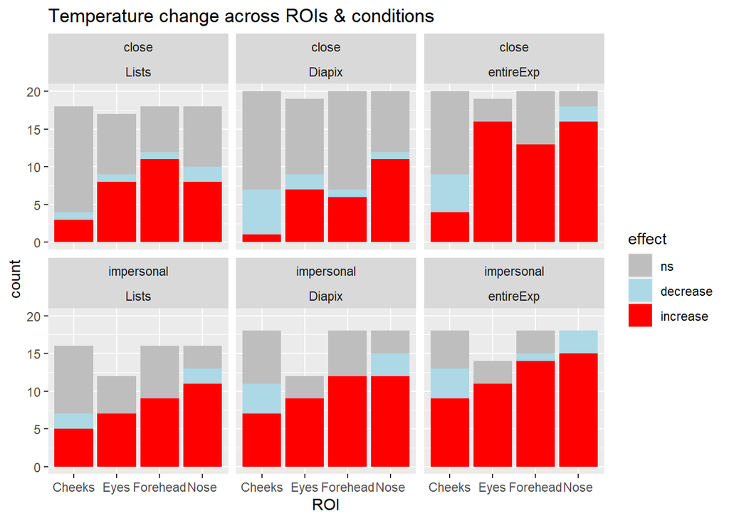

```r
ggplot(all, aes(ROI, fill=effect))+
  geom_bar()+
  facet_wrap(condition~section)+
  ggtitle("Temperature change across ROIs & conditions")+
  scale_fill_manual(values = c("decrease" = "lightblue", "increase" = "red", "ns" = "gray"))
```

### Questionnaire scores as predictors?

#### First part of experiment (Lists)

```r
d <- merge(all |>
             filter(section == "Lists") |>
             select(-condition) |>
             mutate_at(c("sign", "effect"), as.factor),
           meta, by="speaker") |>
  mutate_at("condition", as.factor)
```

```r
# data set for poisson regression

dt <- d |>
  group_by(effect, condition, ROI) |>
  summarize(count = n()) |>
  right_join(crossing(effect = unique(d$effect), condition = unique(d$condition), ROI = unique(d$ROI))) |>
  mutate(count = replace_na(count, 0))
conditionCount <- d |>
  group_by(condition, ROI) |>
  summarize(condCount = n())
dt <- merge(dt, conditionCount, by=c("condition", "ROI"))

dt$effect <- relevel(dt$effect, ref="ns")
# contrasts(dt$condition) <- c(-.5,+.5)
dt$condition <- relevel(dt$condition, ref="close")
```

##### All ROIs together

No condition effect

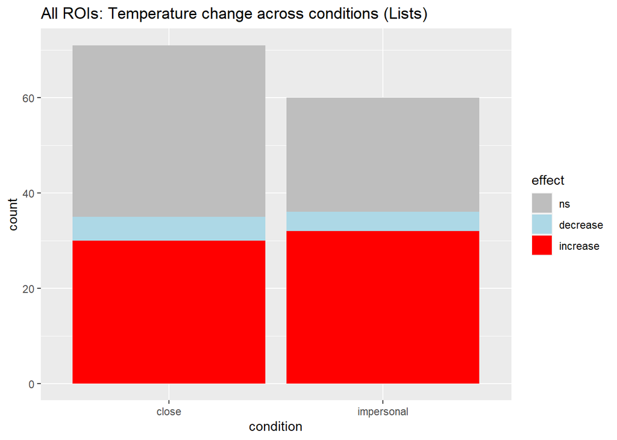

```r
ggplot(d, aes(condition, fill=effect))+
  geom_bar()+
  # facet_wrap(~condition)+
  ggtitle("All ROIs: Temperature change across conditions (Lists)")+
  scale_fill_manual(values = c("decrease" = "lightblue", "increase" = "red", "ns" = "gray"))
```

```r
tidy(m <- nnet::multinom(effect ~ condition, data=d)) |>
  as_tibble() |>
  mutate(estimate = plogis(estimate)) # plogis transforms log odds (the output of the model) into probabilities
```

```
## # A tibble: 4 × 6
##   y.level  term                estimate std.error statistic   p.value
##   <chr>    <chr>                  <dbl>     <dbl>     <dbl>     <dbl>
## 1 decrease (Intercept)            0.122     0.477    -4.14  0.0000353
## 2 decrease conditionimpersonal    0.545     0.721     0.253 0.800
## 3 increase (Intercept)            0.455     0.247    -0.738 0.461
## 4 increase conditionimpersonal    0.615     0.366     1.28  0.199
```

```r
emmeans(m, pairwise~condition, by="effect")
```

```
## $emmeans
## effect = ns:
##  condition    prob     SE df lower.CL upper.CL
##  close      0.5070 0.0593  4   0.3423    0.672
##  impersonal 0.4000 0.0632  4   0.2244    0.576
##
## effect = decrease:
##  condition    prob     SE df lower.CL upper.CL
##  close      0.0704 0.0304  4  -0.0139    0.155
##  impersonal 0.0667 0.0322  4  -0.0227    0.156
##
## effect = increase:
##  condition    prob     SE df lower.CL upper.CL
##  close      0.4225 0.0586  4   0.2598    0.585
##  impersonal 0.5333 0.0644  4   0.3545    0.712
##
## Confidence level used: 0.95
##
## $contrasts
## effect = ns:
##  contrast           estimate     SE df t.ratio p.value
##  close - impersonal  0.10704 0.0867  4   1.234  0.2846
##
## effect = decrease:
##  contrast           estimate     SE df t.ratio p.value
##  close - impersonal  0.00375 0.0443  4   0.085  0.9365
##
## effect = increase:
##  contrast           estimate     SE df t.ratio p.value
##  close - impersonal -0.11079 0.0871  4  -1.272  0.2722
```

```r
summary(m <- glmer(sign ~ condition + (1|speaker), d, family=binomial))
```

```
## Generalized linear mixed model fit by maximum likelihood (Laplace
##   Approximation) [glmerMod]
##  Family: binomial  ( logit )
## Formula: sign ~ condition + (1 | speaker)
##    Data: d
##
##      AIC      BIC   logLik deviance df.resid
##    183.9    192.5    -88.9    177.9      128
##
## Scaled residuals:
##     Min      1Q  Median      3Q     Max
## -1.3525 -0.9884  0.6416  0.8495  1.1604
##
## Random effects:
##  Groups  Name        Variance Std.Dev.
##  speaker (Intercept) 0.3767   0.6138
## Number of obs: 131, groups:  speaker, 34
##
## Fixed effects:
##                     Estimate Std. Error z value Pr(>|z|)
## (Intercept)         -0.03219    0.28724  -0.112    0.911
## conditionimpersonal  0.48020    0.42954   1.118    0.264
##
## Correlation of Fixed Effects:
##             (Intr)
## cndtnmprsnl -0.670
```

##### Nose

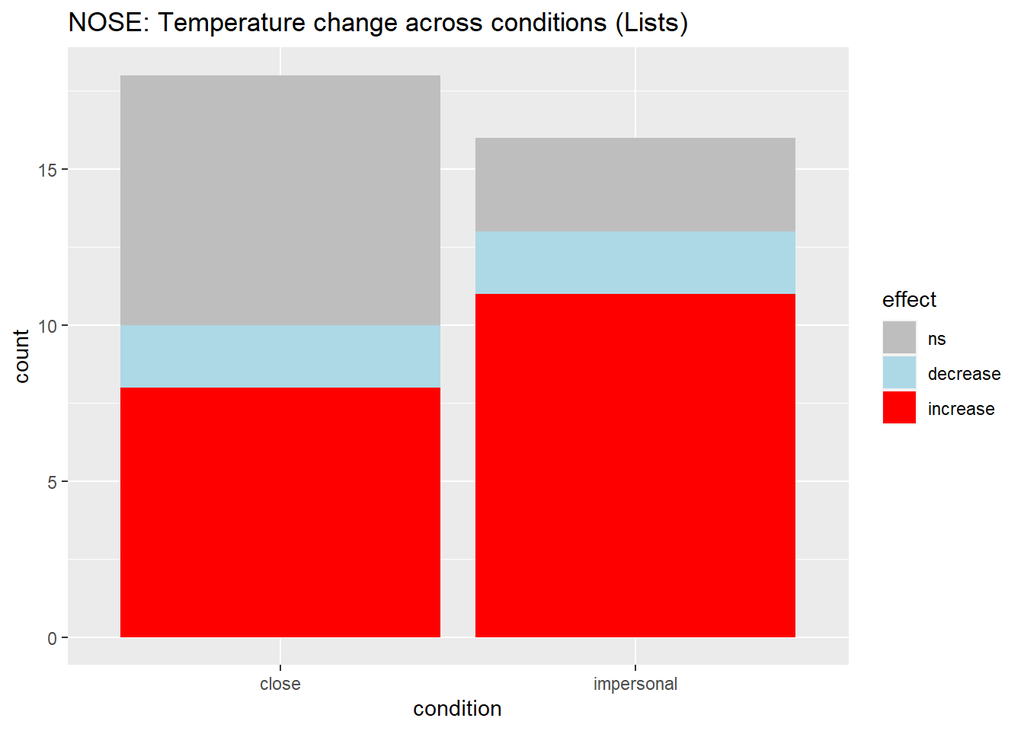

```r
ggplot(d |> filter(ROI=="Nose"), aes(condition, fill=effect))+
  geom_bar()+
  ggtitle("NOSE: Temperature change across conditions (Lists)")+
  scale_fill_manual(values = c("decrease" = "lightblue", "increase" = "red", "ns" = "gray"))
```

No effect of condition

```r
tidy(m <- nnet::multinom(effect ~ condition, data=d |> filter(ROI=="Nose"))) |>
  as_tibble() |>
  mutate(estimate = plogis(estimate)) # plogis transforms log odds (the output of the model) into probabilities
```

```
## # A tibble: 4 × 6
##   y.level  term                estimate std.error   statistic p.value
##   <chr>    <chr>                  <dbl>     <dbl>       <dbl>   <dbl>
## 1 decrease (Intercept)            0.200     0.791 -1.75        0.0795
## 2 decrease conditionimpersonal    0.727     1.21   0.812       0.417
## 3 increase (Intercept)            0.500     0.500  0.00000342  1.00
## 4 increase conditionimpersonal    0.786     0.821  1.58        0.114
```

```r
emmeans(m, pairwise~condition, by="effect")
```

```
## $emmeans
## effect = ns:
##  condition   prob     SE df lower.CL upper.CL
##  close      0.444 0.1171  4   0.1193    0.770
##  impersonal 0.187 0.0976  4  -0.0834    0.458
##
## effect = decrease:
##  condition   prob     SE df lower.CL upper.CL
##  close      0.111 0.0741  4  -0.0946    0.317
##  impersonal 0.125 0.0827  4  -0.1046    0.355
##
## effect = increase:
##  condition   prob     SE df lower.CL upper.CL
##  close      0.444 0.1171  4   0.1193    0.770
##  impersonal 0.688 0.1159  4   0.3658    1.009
##
## Confidence level used: 0.95
##
## $contrasts
## effect = ns:
##  contrast           estimate    SE df t.ratio p.value
##  close - impersonal   0.2569 0.152  4   1.686  0.1672
##
## effect = decrease:
##  contrast           estimate    SE df t.ratio p.value
##  close - impersonal  -0.0139 0.111  4  -0.125  0.9065
##
## effect = increase:
##  contrast           estimate    SE df t.ratio p.value
##  close - impersonal  -0.2431 0.165  4  -1.475  0.2142
```

```r
summary(glmer(sign ~ condition + (1|speaker), d |> filter(ROI=="Nose"), family=binomial))
```

```
## boundary (singular) fit: see help('isSingular')
```

```
## Generalized linear mixed model fit by maximum likelihood (Laplace
##   Approximation) [glmerMod]
##  Family: binomial  ( logit )
## Formula: sign ~ condition + (1 | speaker)
##    Data: filter(d, ROI == "Nose")
##
##      AIC      BIC   logLik deviance df.resid
##     46.2     50.8    -20.1     40.2       31
##
## Scaled residuals:
##     Min      1Q  Median      3Q     Max
## -2.0817 -1.1180  0.4804  0.8944  0.8944
##
## Random effects:
##  Groups  Name        Variance  Std.Dev.
##  speaker (Intercept) 3.735e-10 1.933e-05
## Number of obs: 34, groups:  speaker, 34
##
## Fixed effects:
##                     Estimate Std. Error z value Pr(>|z|)
## (Intercept)           0.2231     0.4743    0.47    0.638
## conditionimpersonal   1.2432     0.7971    1.56    0.119
##
## Correlation of Fixed Effects:
##             (Intr)
## cndtnmprsnl -0.595
## optimizer (Nelder_Mead) convergence code: 0 (OK)
## boundary (singular) fit: see help('isSingular')
```

```r
# two (more) options of plots:

# ggeffects::ggpredict(m, terms=c("effect", "condition")) |>
#   as_tibble()  |>
#   ggplot() +
#   aes(x = group, y = predicted) +
#   facet_grid(.~x) +
#   geom_point() +
#   geom_errorbar(aes(ymin=conf.low, ymax = conf.high)) +
#   geom_line(group = 1)
#
# ggeffects::ggpredict(m, terms=c("effect", "condition")) |>
#   as_tibble()  |>
#   ggplot() +
#   aes(x = group, y = predicted) +
#   facet_grid(.~x) +
#   geom_col() +
#   geom_errorbar(aes(ymin=conf.low, ymax = conf.high), width = .3)
```

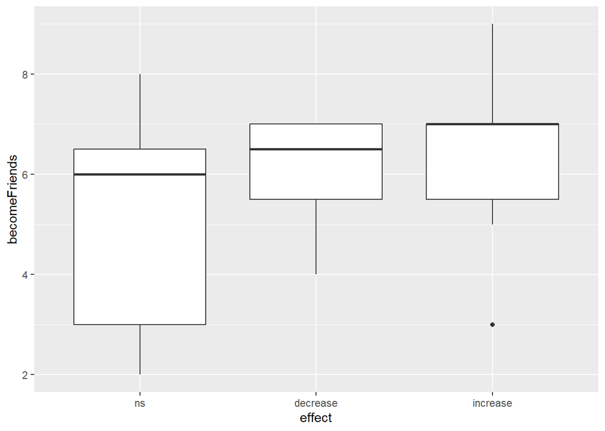

```r
ggplot(d |> filter(ROI=="Nose"), aes(effect, becomeFriends))+
  geom_boxplot()
```

```r
tidy(m <- nnet::multinom(effect ~ becomeFriends, data=d |> filter(ROI=="Nose"))) |>
  as_tibble() |>
  mutate(estimate = plogis(estimate)) # plogis transforms log odds (the output of the model) into probabilities
```

```
## # A tibble: 4 × 6
##   y.level  term          estimate std.error statistic p.value
##   <chr>    <chr>            <dbl>     <dbl>     <dbl>   <dbl>
## 1 decrease (Intercept)     0.0611     2.16     -1.27   0.206
## 2 decrease becomeFriends   0.577      0.359     0.863  0.388
## 3 increase (Intercept)     0.0806     1.53     -1.59   0.111
## 4 increase becomeFriends   0.625      0.255     2.00   0.0454
```

```r
tidy(m <- nnet::multinom(effect ~ closeness, data=d |> filter(ROI=="Nose"))) |>
  as_tibble() |>
  mutate(estimate = plogis(estimate)) # plogis transforms log odds (the output of the model) into probabilities
```

```
## # A tibble: 4 × 6
##   y.level  term        estimate std.error statistic p.value
##   <chr>    <chr>          <dbl>     <dbl>     <dbl>   <dbl>
## 1 decrease (Intercept)    0.282     1.35    -0.692    0.489
## 2 decrease closeness      0.495     0.322   -0.0642   0.949
## 3 increase (Intercept)    0.627     0.881    0.589    0.556
## 4 increase closeness      0.502     0.208    0.0346   0.972
```

```r
tidy(m <- nnet::multinom(effect ~ similarity, data=d |> filter(ROI=="Nose"))) |>
  as_tibble() |>
  mutate(estimate = plogis(estimate)) # plogis transforms log odds (the output of the model) into probabilities
```

```
## # A tibble: 4 × 6
##   y.level  term        estimate std.error statistic p.value
##   <chr>    <chr>          <dbl>     <dbl>     <dbl>   <dbl>
## 1 decrease (Intercept)    0.155     1.96     -0.864   0.388
## 2 decrease similarity     0.531     0.332     0.371   0.711
## 3 increase (Intercept)    0.374     1.27     -0.404   0.686
## 4 increase similarity     0.547     0.218     0.863   0.388
```

```r
tidy(m <- nnet::multinom(effect ~ likeability, data=d |> filter(ROI=="Nose"))) |>
  as_tibble() |>
  mutate(estimate = plogis(estimate)) # plogis transforms log odds (the output of the model) into probabilities
```

```
## # A tibble: 4 × 6
##   y.level  term        estimate std.error statistic p.value
##   <chr>    <chr>          <dbl>     <dbl>     <dbl>   <dbl>
## 1 decrease (Intercept)  0.00183     4.02     -1.57    0.117
## 2 decrease likeability  0.676       0.529     1.39    0.165
## 3 increase (Intercept)  0.302       1.87     -0.449   0.653
## 4 increase likeability  0.551       0.273     0.752   0.452
```

No effect of BFI scores

```r
tidy(m <- nnet::multinom(effect ~ extraversion, data=d |> filter(ROI=="Nose"))) |>
  as_tibble() |>
  mutate(estimate = plogis(estimate)) # plogis transforms log odds (the output of the model) into probabilities
```

```
## # A tibble: 4 × 6
##   y.level  term         estimate std.error statistic p.value
##   <chr>    <chr>           <dbl>     <dbl>     <dbl>   <dbl>
## 1 decrease (Intercept)   0.00141     4.19     -1.57    0.117
## 2 decrease extraversion  0.817       1.08      1.38    0.166
## 3 increase (Intercept)   0.772       2.27      0.537   0.591
## 4 increase extraversion  0.451       0.651    -0.301   0.763
```

```r
tidy(m <- nnet::multinom(effect ~ openness, data=d |> filter(ROI=="Nose"))) |>
  as_tibble() |>
  mutate(estimate = plogis(estimate)) # plogis transforms log odds (the output of the model) into probabilities
```

```
## # A tibble: 4 × 6
##   y.level  term        estimate std.error statistic p.value
##   <chr>    <chr>          <dbl>     <dbl>     <dbl>   <dbl>
## 1 decrease (Intercept)   0.0940     2.68     -0.847   0.397
## 2 decrease openness      0.587      0.724     0.488   0.626
## 3 increase (Intercept)   0.353      1.68     -0.361   0.718
## 4 increase openness      0.581      0.466     0.699   0.484
```

```r
tidy(m <- nnet::multinom(effect ~ agreeableness, data=d |> filter(ROI=="Nose"))) |>
  as_tibble() |>
  mutate(estimate = plogis(estimate)) # plogis transforms log odds (the output of the model) into probabilities
```

```
## # A tibble: 4 × 6
##   y.level  term          estimate std.error statistic p.value
##   <chr>    <chr>            <dbl>     <dbl>     <dbl>   <dbl>
## 1 decrease (Intercept)    0.00161     4.91     -1.31    0.191
## 2 decrease agreeableness  0.817       1.32      1.13    0.257
## 3 increase (Intercept)    0.840       2.76      0.600   0.548
## 4 increase agreeableness  0.419       0.798    -0.408   0.684
```

```r
tidy(m <- nnet::multinom(effect ~ conscientiousness, data=d |> filter(ROI=="Nose"))) |>
  as_tibble() |>
  mutate(estimate = plogis(estimate)) # plogis transforms log odds (the output of the model) into probabilities
```

```
## # A tibble: 4 × 6
##   y.level  term              estimate std.error statistic p.value
##   <chr>    <chr>                <dbl>     <dbl>     <dbl>   <dbl>
## 1 decrease (Intercept)         0.0514     4.16     -0.701   0.484
## 2 decrease conscientiousness   0.617      1.03      0.467   0.641
## 3 increase (Intercept)         0.175      2.60     -0.595   0.552
## 4 increase conscientiousness   0.629      0.649     0.811   0.418
```

```r
tidy(m <- nnet::multinom(effect ~ neuroticism, data=d |> filter(ROI=="Nose"))) |>
  as_tibble() |>
  mutate(estimate = plogis(estimate)) # plogis transforms log odds (the output of the model) into probabilities
```

```
## # A tibble: 4 × 6
##   y.level  term        estimate std.error statistic p.value
##   <chr>    <chr>          <dbl>     <dbl>     <dbl>   <dbl>
## 1 decrease (Intercept)   0.0283     2.78     -1.27    0.203
## 2 decrease neuroticism   0.686      0.816     0.959   0.337
## 3 increase (Intercept)   0.441      1.62     -0.147   0.883
## 4 increase neuroticism   0.563      0.514     0.496   0.620
```

No effect of thermal comfort

```r
tidy(m <- nnet::multinom(effect ~ comfortPre, data=d |> filter(ROI=="Nose"))) |>
  as_tibble() |>
  mutate(estimate = plogis(estimate)) # plogis transforms log odds (the output of the model) into probabilities
```

```
## # A tibble: 4 × 6
##   y.level  term        estimate std.error statistic p.value
##   <chr>    <chr>          <dbl>     <dbl>     <dbl>   <dbl>
## 1 decrease (Intercept)    0.994     3.60     1.40     0.162
## 2 decrease comfortPre     0.261     0.638   -1.63     0.102
## 3 increase (Intercept)    0.627     2.37     0.219    0.827
## 4 increase comfortPre     0.501     0.367    0.0124   0.990
```

```r
tidy(m <- nnet::multinom(effect ~ comfortPost, data=d |> filter(ROI=="Nose"))) |>
  as_tibble() |>
  mutate(estimate = plogis(estimate)) # plogis transforms log odds (the output of the model) into probabilities
```

```
## # A tibble: 4 × 6
##   y.level  term        estimate std.error statistic p.value
##   <chr>    <chr>          <dbl>     <dbl>     <dbl>   <dbl>
## 1 decrease (Intercept)    0.781     3.40      0.375   0.708
## 2 decrease comfortPost    0.401     0.598    -0.671   0.502
## 3 increase (Intercept)    0.203     2.24     -0.611   0.541
## 4 increase comfortPost    0.578     0.365     0.861   0.389
```

##### Eyes

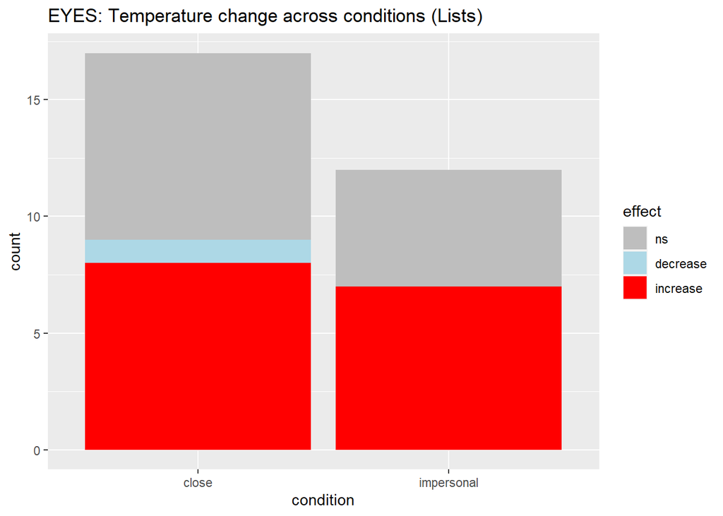

```r
ggplot(d |> filter(ROI=="Eyes"), aes(condition, fill=effect))+
  geom_bar()+
  ggtitle("EYES: Temperature change across conditions (Lists)")+
  scale_fill_manual(values = c("decrease" = "lightblue", "increase" = "red", "ns" = "gray"))
```

No effect of condition

```r
tidy(m <- nnet::multinom(effect ~ condition, data=d |> filter(ROI=="Eyes"))) |>
  as_tibble() |>
  mutate(estimate = plogis(estimate)) # plogis transforms log odds (the output of the model) into probabilities
```

```
## # A tibble: 4 × 6
##   y.level  term                estimate std.error statistic p.value
##   <chr>    <chr>                  <dbl>     <dbl>     <dbl>   <dbl>
## 1 decrease (Intercept)         0.111        1.06  -1.96      0.0499
## 2 decrease conditionimpersonal 0.000518    55.6   -0.136     0.892
## 3 increase (Intercept)         0.500        0.500  0.000103  1.00
## 4 increase conditionimpersonal 0.583        0.770  0.437     0.662
```

```r
emmeans(m, pairwise~condition, by="effect")
```

```
## $emmeans
## effect = ns:
##  condition      prob     SE df lower.CL upper.CL
##  close      0.470588 0.1211  4  0.13448  0.80670
##  impersonal 0.416645 0.1423  4  0.02151  0.81178
##
## effect = decrease:
##  condition      prob     SE df lower.CL upper.CL
##  close      0.058800 0.0571  4 -0.09961  0.21721
##  impersonal 0.000027 0.0015  4 -0.00414  0.00419
##
## effect = increase:
##  condition      prob     SE df lower.CL upper.CL
##  close      0.470612 0.1211  4  0.13450  0.80672
##  impersonal 0.583328 0.1423  4  0.18819  0.97847
##
## Confidence level used: 0.95
##
## $contrasts
## effect = ns:
##  contrast           estimate     SE df t.ratio p.value
##  close - impersonal   0.0539 0.1868  4   0.289  0.7871
##
## effect = decrease:
##  contrast           estimate     SE df t.ratio p.value
##  close - impersonal   0.0588 0.0571  4   1.030  0.3613
##
## effect = increase:
##  contrast           estimate     SE df t.ratio p.value
##  close - impersonal  -0.1127 0.1868  4  -0.603  0.5789
```

```r
summary(glmer(sign ~ condition + (1|speaker), d |> filter(ROI=="Eyes"), family=binomial))
```

```
## boundary (singular) fit: see help('isSingular')
```

```
## Generalized linear mixed model fit by maximum likelihood (Laplace
##   Approximation) [glmerMod]
##  Family: binomial  ( logit )
## Formula: sign ~ condition + (1 | speaker)
##    Data: filter(d, ROI == "Eyes")
##
##      AIC      BIC   logLik deviance df.resid
##     45.8     49.9    -19.9     39.8       26
##
## Scaled residuals:
##     Min      1Q  Median      3Q     Max
## -1.1832 -1.0607  0.8451  0.9428  0.9428
##
## Random effects:
##  Groups  Name        Variance Std.Dev.
##  speaker (Intercept) 5.95e-11 7.714e-06
## Number of obs: 29, groups:  speaker, 29
##
## Fixed effects:
##                     Estimate Std. Error z value Pr(>|z|)
## (Intercept)           0.1178     0.4859   0.242    0.808
## conditionimpersonal   0.2187     0.7609   0.287    0.774
##
## Correlation of Fixed Effects:
##             (Intr)
## cndtnmprsnl -0.639
## optimizer (Nelder_Mead) convergence code: 0 (OK)
## boundary (singular) fit: see help('isSingular')
```

No effect of the perception of their partner.

```r
tidy(m <- nnet::multinom(effect ~ becomeFriends, data=d |> filter(ROI=="Eyes"))) |>
  as_tibble() |>
  mutate(estimate = plogis(estimate)) # plogis transforms log odds (the output of the model) into probabilities
```

```
## # A tibble: 4 × 6
##   y.level  term          estimate std.error statistic p.value
##   <chr>    <chr>            <dbl>     <dbl>     <dbl>   <dbl>
## 1 decrease (Intercept)   4.83e-32    87.3      -0.826   0.409
## 2 decrease becomeFriends 1.00e+ 0    10.2       0.832   0.405
## 3 increase (Intercept)   6.73e- 1     1.60      0.451   0.652
## 4 increase becomeFriends 4.76e- 1     0.258    -0.375   0.707
```

```r
tidy(m <- nnet::multinom(effect ~ closeness, data=d |> filter(ROI=="Eyes"))) |>
  as_tibble() |>
  mutate(estimate = plogis(estimate)) # plogis transforms log odds (the output of the model) into probabilities
```

```
## # A tibble: 4 × 6
##   y.level  term        estimate std.error statistic p.value
##   <chr>    <chr>          <dbl>     <dbl>     <dbl>   <dbl>
## 1 decrease (Intercept)  0.00292     3.96     -1.47    0.141
## 2 decrease closeness    0.659       0.655     1.00    0.315
## 3 increase (Intercept)  0.622       0.868     0.574   0.566
## 4 increase closeness    0.476       0.211    -0.456   0.649
```

```r
tidy(m <- nnet::multinom(effect ~ similarity, data=d |> filter(ROI=="Eyes"))) |>
  as_tibble() |>
  mutate(estimate = plogis(estimate)) # plogis transforms log odds (the output of the model) into probabilities
```

```
## # A tibble: 4 × 6
##   y.level  term          estimate std.error statistic p.value
##   <chr>    <chr>            <dbl>     <dbl>     <dbl>   <dbl>
## 1 decrease (Intercept) 0.00000491    10.3     -1.19     0.236
## 2 decrease similarity  0.792          1.30     1.03     0.302
## 3 increase (Intercept) 0.557          1.29     0.176    0.860
## 4 increase similarity  0.496          0.212   -0.0682   0.946
```

```r
tidy(m <- nnet::multinom(effect ~ likeability, data=d |> filter(ROI=="Eyes"))) |>
  as_tibble() |>
  mutate(estimate = plogis(estimate)) # plogis transforms log odds (the output of the model) into probabilities
```

```
## # A tibble: 4 × 6
##   y.level  term        estimate std.error statistic p.value
##   <chr>    <chr>          <dbl>     <dbl>     <dbl>   <dbl>
## 1 decrease (Intercept) 5.12e-14    26.3       -1.16   0.245
## 2 decrease likeability 9.67e- 1     2.98       1.13   0.258
## 3 increase (Intercept) 9.11e- 1     2.14       1.08   0.278
## 4 increase likeability 4.22e- 1     0.303     -1.04   0.297
```

No effect of BFI scores

```r
tidy(m <- nnet::multinom(effect ~ extraversion, data=d |> filter(ROI=="Eyes"))) |>
  as_tibble() |>
  mutate(estimate = plogis(estimate)) # plogis transforms log odds (the output of the model) into probabilities
```

```
## # A tibble: 4 × 6
##   y.level  term         estimate std.error statistic p.value
##   <chr>    <chr>           <dbl>     <dbl>     <dbl>   <dbl>
## 1 decrease (Intercept)    0.999      9.89      0.681   0.496
## 2 decrease extraversion   0.0427     3.55     -0.877   0.380
## 3 increase (Intercept)    0.0745     2.25     -1.12    0.263
## 4 increase extraversion   0.681      0.633     1.20    0.232
```

```r
tidy(m <- nnet::multinom(effect ~ openness, data=d |> filter(ROI=="Eyes"))) |>
  as_tibble() |>
  mutate(estimate = plogis(estimate)) # plogis transforms log odds (the output of the model) into probabilities
```

```
## # A tibble: 4 × 6
##   y.level  term        estimate std.error statistic p.value
##   <chr>    <chr>          <dbl>     <dbl>     <dbl>   <dbl>
## 1 decrease (Intercept) 0.000306     7.88     -1.03    0.304
## 2 decrease openness    0.798        1.82      0.756   0.450
## 3 increase (Intercept) 0.811        1.66      0.875   0.381
## 4 increase openness    0.408        0.459    -0.814   0.416
```

```r
tidy(m <- nnet::multinom(effect ~ agreeableness, data=d |> filter(ROI=="Eyes"))) |>
  as_tibble() |>
  mutate(estimate = plogis(estimate)) # plogis transforms log odds (the output of the model) into probabilities
```

```
## # A tibble: 4 × 6
##   y.level  term          estimate std.error statistic p.value
##   <chr>    <chr>            <dbl>     <dbl>     <dbl>   <dbl>
## 1 decrease (Intercept)    0.00411     8.04     -0.683   0.494
## 2 decrease agreeableness  0.699       2.24      0.375   0.707
## 3 increase (Intercept)    0.205       2.80     -0.484   0.628
## 4 increase agreeableness  0.607       0.809     0.540   0.589
```

```r
tidy(m <- nnet::multinom(effect ~ conscientiousness, data=d |> filter(ROI=="Eyes"))) |>
  as_tibble() |>
  mutate(estimate = plogis(estimate)) # plogis transforms log odds (the output of the model) into probabilities
```

```
## # A tibble: 4 × 6
##   y.level  term              estimate std.error statistic p.value
##   <chr>    <chr>                <dbl>     <dbl>     <dbl>   <dbl>
## 1 decrease (Intercept)       9.15e-20    36.9      -1.19    0.234
## 2 decrease conscientiousness 1.00e+ 0     7.97      1.17    0.243
## 3 increase (Intercept)       2.17e- 1     2.66     -0.482   0.630
## 4 increase conscientiousness 5.90e- 1     0.674     0.540   0.589
```

```r
tidy(m <- nnet::multinom(effect ~ neuroticism, data=d |> filter(ROI=="Eyes"))) |>
  as_tibble() |>
  mutate(estimate = plogis(estimate)) # plogis transforms log odds (the output of the model) into probabilities
```

```
## # A tibble: 4 × 6
##   y.level  term        estimate std.error statistic p.value
##   <chr>    <chr>          <dbl>     <dbl>     <dbl>   <dbl>
## 1 decrease (Intercept)    0.126     4.85     -0.399   0.690
## 2 decrease neuroticism    0.450     1.51     -0.132   0.895
## 3 increase (Intercept)    0.883     1.83      1.11    0.268
## 4 increase neuroticism    0.352     0.581    -1.05    0.292
```

No effect of thermal comfort

```r
tidy(m <- nnet::multinom(effect ~ comfortPre, data=d |> filter(ROI=="Eyes"))) |>
  as_tibble() |>
  mutate(estimate = plogis(estimate)) # plogis transforms log odds (the output of the model) into probabilities
```

```
## # A tibble: 4 × 6
##   y.level  term        estimate std.error statistic p.value
##   <chr>    <chr>          <dbl>     <dbl>     <dbl>   <dbl>
## 1 decrease (Intercept)    0.995     6.76      0.792   0.428
## 2 decrease comfortPre     0.196     1.31     -1.08    0.280
## 3 increase (Intercept)    0.389     2.45     -0.184   0.854
## 4 increase comfortPre     0.523     0.381     0.245   0.806
```

```r
tidy(m <- nnet::multinom(effect ~ comfortPost, data=d |> filter(ROI=="Eyes"))) |>
  as_tibble() |>
  mutate(estimate = plogis(estimate)) # plogis transforms log odds (the output of the model) into probabilities
```

```
## # A tibble: 4 × 6
##   y.level  term        estimate std.error statistic p.value
##   <chr>    <chr>          <dbl>     <dbl>     <dbl>   <dbl>
## 1 decrease (Intercept)    0.336     5.71     -0.119   0.905
## 2 decrease comfortPost    0.425     0.932    -0.326   0.744
## 3 increase (Intercept)    0.952     2.20      1.36    0.174
## 4 increase comfortPost    0.385     0.355    -1.32    0.187
```

##### Forehead

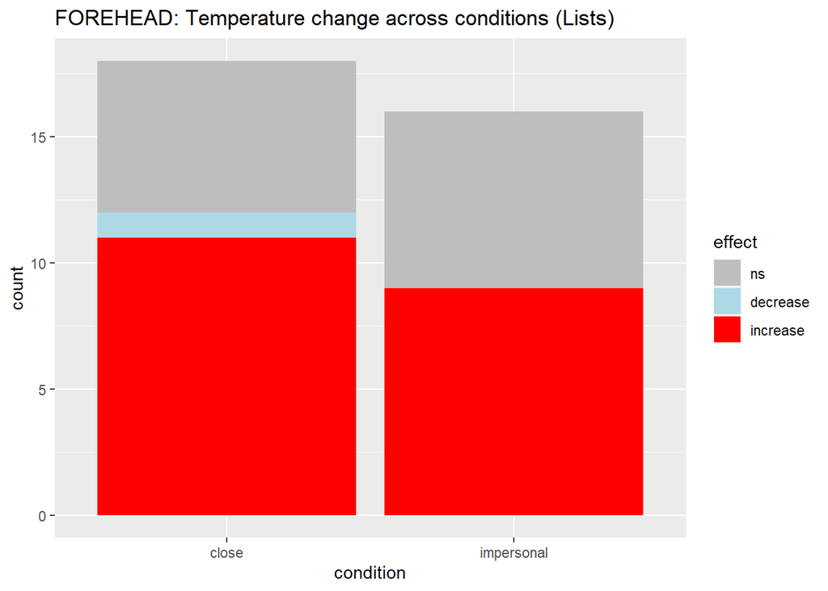

```r
ggplot(d |> filter(ROI=="Forehead"), aes(condition, fill=effect))+
  geom_bar()+
  ggtitle("FOREHEAD: Temperature change across conditions (Lists)")+
  scale_fill_manual(values = c("decrease" = "lightblue", "increase" = "red", "ns" = "gray"))
```

No effect of condition

```r
tidy(m <- nnet::multinom(effect ~ condition, data=d |> filter(ROI=="Forehead"))) |>
  as_tibble() |>
  mutate(estimate = plogis(estimate)) # plogis transforms log odds (the output of the model) into probabilities
```

```
## # A tibble: 4 × 6
##   y.level  term                estimate std.error statistic p.value
##   <chr>    <chr>                  <dbl>     <dbl>     <dbl>   <dbl>
## 1 decrease (Intercept)         0.143        1.08     -1.66   0.0971
## 2 decrease conditionimpersonal 0.000219    62.5      -0.135  0.893
## 3 increase (Intercept)         0.647        0.508     1.19   0.232
## 4 increase conditionimpersonal 0.412        0.715    -0.496  0.620
```

```r
emmeans(m, pairwise~condition, by="effect")
```

```
## $emmeans
## effect = ns:
##  condition      prob       SE df lower.CL upper.CL
##  close      0.333327 0.111111  4  0.02483  0.64182
##  impersonal 0.437446 0.124018  4  0.09312  0.78178
##
## effect = decrease:
##  condition      prob       SE df lower.CL upper.CL
##  close      0.055540 0.053983  4 -0.09434  0.20542
##  impersonal 0.000016 0.000999  4 -0.00276  0.00279
##
## effect = increase:
##  condition      prob       SE df lower.CL upper.CL
##  close      0.611134 0.114903  4  0.29211  0.93016
##  impersonal 0.562538 0.124018  4  0.21821  0.90687
##
## Confidence level used: 0.95
##
## $contrasts
## effect = ns:
##  contrast           estimate    SE df t.ratio p.value
##  close - impersonal  -0.1041 0.167  4  -0.625  0.5657
##
## effect = decrease:
##  contrast           estimate    SE df t.ratio p.value
##  close - impersonal   0.0555 0.054  4   1.028  0.3619
##
## effect = increase:
##  contrast           estimate    SE df t.ratio p.value
##  close - impersonal   0.0486 0.169  4   0.287  0.7881
```

```r
summary(glmer(sign ~ condition + (1|speaker), d |> filter(ROI=="Forehead"), family=binomial))
```

```
## boundary (singular) fit: see help('isSingular')
```

```
## Generalized linear mixed model fit by maximum likelihood (Laplace
##   Approximation) [glmerMod]
##  Family: binomial  ( logit )
## Formula: sign ~ condition + (1 | speaker)
##    Data: filter(d, ROI == "Forehead")
##
##      AIC      BIC   logLik deviance df.resid
##     50.8     55.4    -22.4     44.8       31
##
## Scaled residuals:
##     Min      1Q  Median      3Q     Max
## -1.4142 -1.1339  0.7071  0.8382  0.8819
##
## Random effects:
##  Groups  Name        Variance Std.Dev.
##  speaker (Intercept) 5.83e-11 7.636e-06
## Number of obs: 34, groups:  speaker, 34
##
## Fixed effects:
##                     Estimate Std. Error z value Pr(>|z|)
## (Intercept)           0.6931     0.5000   1.386    0.166
## conditionimpersonal  -0.4418     0.7099  -0.622    0.534
##
## Correlation of Fixed Effects:
##             (Intr)
## cndtnmprsnl -0.704
## optimizer (Nelder_Mead) convergence code: 0 (OK)
## boundary (singular) fit: see help('isSingular')
```

No effect of the perception of their partner.

```r
tidy(m <- nnet::multinom(effect ~ becomeFriends, data=d |> filter(ROI=="Forehead"))) |>
  as_tibble() |>
  mutate(estimate = plogis(estimate)) # plogis transforms log odds (the output of the model) into probabilities
```

```
## # A tibble: 4 × 6
##   y.level  term          estimate std.error statistic p.value
##   <chr>    <chr>            <dbl>     <dbl>     <dbl>   <dbl>
## 1 decrease (Intercept)    0.00597     5.45     -0.939   0.348
## 2 decrease becomeFriends  0.595       0.769     0.502   0.616
## 3 increase (Intercept)    0.765       1.34      0.878   0.380
## 4 increase becomeFriends  0.469       0.215    -0.582   0.560
```

```r
tidy(m <- nnet::multinom(effect ~ closeness, data=d |> filter(ROI=="Forehead"))) |>
  as_tibble() |>
  mutate(estimate = plogis(estimate)) # plogis transforms log odds (the output of the model) into probabilities
```

```
## # A tibble: 4 × 6
##   y.level  term        estimate std.error statistic p.value
##   <chr>    <chr>          <dbl>     <dbl>     <dbl>   <dbl>
## 1 decrease (Intercept)    0.230     2.28     -0.531   0.596
## 2 decrease closeness      0.405     0.658    -0.582   0.560
## 3 increase (Intercept)    0.736     0.858     1.19    0.233
## 4 increase closeness      0.462     0.197    -0.770   0.441
```

```r
tidy(m <- nnet::multinom(effect ~ similarity, data=d |> filter(ROI=="Forehead"))) |>
  as_tibble() |>
  mutate(estimate = plogis(estimate)) # plogis transforms log odds (the output of the model) into probabilities
```

```
## # A tibble: 4 × 6
##   y.level  term        estimate std.error statistic p.value
##   <chr>    <chr>          <dbl>     <dbl>     <dbl>   <dbl>
## 1 decrease (Intercept)  0.00311     5.21    -1.11     0.268
## 2 decrease similarity   0.623       0.736    0.680    0.496
## 3 increase (Intercept)  0.603       1.20     0.347    0.729
## 4 increase similarity   0.501       0.202    0.0122   0.990
```

```r
tidy(m <- nnet::multinom(effect ~ likeability, data=d |> filter(ROI=="Forehead"))) |>
  as_tibble() |>
  mutate(estimate = plogis(estimate)) # plogis transforms log odds (the output of the model) into probabilities
```

```
## # A tibble: 4 × 6
##   y.level  term        estimate std.error statistic p.value
##   <chr>    <chr>          <dbl>     <dbl>     <dbl>   <dbl>
## 1 decrease (Intercept) 0.000264     8.43     -0.977   0.329
## 2 decrease likeability 0.680        1.05      0.717   0.474
## 3 increase (Intercept) 0.666        1.80      0.384   0.701
## 4 increase likeability 0.491        0.255    -0.147   0.883
```

No effect of BFI scores

```r
tidy(m <- nnet::multinom(effect ~ extraversion, data=d |> filter(ROI=="Forehead"))) |>
  as_tibble() |>
  mutate(estimate = plogis(estimate)) # plogis transforms log odds (the output of the model) into probabilities
```

```
## # A tibble: 4 × 6
##   y.level  term          estimate std.error statistic p.value
##   <chr>    <chr>            <dbl>     <dbl>     <dbl>   <dbl>
## 1 decrease (Intercept)  0.0000471     7.77     -1.28    0.200
## 2 decrease extraversion 0.883         1.95      1.04    0.300
## 3 increase (Intercept)  0.107         2.19     -0.968   0.333
## 4 increase extraversion 0.678         0.635     1.17    0.242
```

```r
tidy(m <- nnet::multinom(effect ~ openness, data=d |> filter(ROI=="Forehead"))) |>
  as_tibble() |>
  mutate(estimate = plogis(estimate)) # plogis transforms log odds (the output of the model) into probabilities
```

```
## # A tibble: 4 × 6
##   y.level  term           estimate std.error statistic p.value
##   <chr>    <chr>             <dbl>     <dbl>     <dbl>   <dbl>
## 1 decrease (Intercept) 0.000000188    13.9      -1.11    0.266
## 2 decrease openness    0.952           2.99      1.00    0.317
## 3 increase (Intercept) 0.883           1.70      1.19    0.235
## 4 increase openness    0.390           0.461    -0.966   0.334
```

```r
tidy(m <- nnet::multinom(effect ~ agreeableness, data=d |> filter(ROI=="Forehead"))) |>
  as_tibble() |>
  mutate(estimate = plogis(estimate)) # plogis transforms log odds (the output of the model) into probabilities
```

```
## # A tibble: 4 × 6
##   y.level  term          estimate std.error statistic p.value
##   <chr>    <chr>            <dbl>     <dbl>     <dbl>   <dbl>
## 1 decrease (Intercept)     0.0720     7.52   -0.340     0.734
## 2 decrease agreeableness   0.499      2.27   -0.00114   0.999
## 3 increase (Intercept)     0.0195     2.76   -1.42      0.156
## 4 increase agreeableness   0.781      0.807   1.57      0.116
```

```r
tidy(m <- nnet::multinom(effect ~ conscientiousness, data=d |> filter(ROI=="Forehead"))) |>
  as_tibble() |>
  mutate(estimate = plogis(estimate)) # plogis transforms log odds (the output of the model) into probabilities
```

```
## # A tibble: 4 × 6
##   y.level  term                   estimate std.error statistic p.value
##   <chr>    <chr>                     <dbl>     <dbl>     <dbl>   <dbl>
## 1 decrease (Intercept)       0.00000000400    16.5       -1.17   0.242
## 2 decrease conscientiousness 0.981             3.64       1.08   0.282
## 3 increase (Intercept)       0.0326            2.64      -1.29   0.198
## 4 increase conscientiousness 0.723             0.659      1.46   0.144
```

```r
tidy(m <- nnet::multinom(effect ~ neuroticism, data=d |> filter(ROI=="Forehead"))) |>
  as_tibble() |>
  mutate(estimate = plogis(estimate)) # plogis transforms log odds (the output of the model) into probabilities
```

```
## # A tibble: 4 × 6
##   y.level  term        estimate std.error statistic p.value
##   <chr>    <chr>          <dbl>     <dbl>     <dbl>   <dbl>
## 1 decrease (Intercept)    0.203     4.23    -0.324    0.746
## 2 decrease neuroticism    0.401     1.42    -0.282    0.778
## 3 increase (Intercept)    0.489     1.53    -0.0291   0.977
## 4 increase neuroticism    0.538     0.477    0.318    0.751
```

No effect of thermal comfort

```r
tidy(m <- nnet::multinom(effect ~ comfortPre, data=d |> filter(ROI=="Forehead"))) |>
  as_tibble() |>
  mutate(estimate = plogis(estimate)) # plogis transforms log odds (the output of the model) into probabilities
```

```
## # A tibble: 4 × 6
##   y.level  term        estimate std.error statistic p.value
##   <chr>    <chr>          <dbl>     <dbl>     <dbl>   <dbl>
## 1 decrease (Intercept) 0.000322     8.07    -0.996    0.319
## 2 decrease comfortPre  0.696        1.15     0.720    0.471
## 3 increase (Intercept) 0.480        2.07    -0.0381   0.970
## 4 increase comfortPre  0.521        0.329    0.250    0.803
```

```r
tidy(m <- nnet::multinom(effect ~ comfortPost, data=d |> filter(ROI=="Forehead"))) |>
  as_tibble() |>
  mutate(estimate = plogis(estimate)) # plogis transforms log odds (the output of the model) into probabilities
```

```
## # A tibble: 4 × 6
##   y.level  term        estimate std.error statistic p.value
##   <chr>    <chr>          <dbl>     <dbl>     <dbl>   <dbl>
## 1 decrease (Intercept) 1.19e-16    54.4      -0.674   0.501
## 2 decrease comfortPost 9.89e- 1     6.83      0.661   0.509
## 3 increase (Intercept) 9.29e- 1     2.17      1.18    0.236
## 4 increase comfortPost 4.12e- 1     0.352    -1.01    0.313
```

##### Cheeks

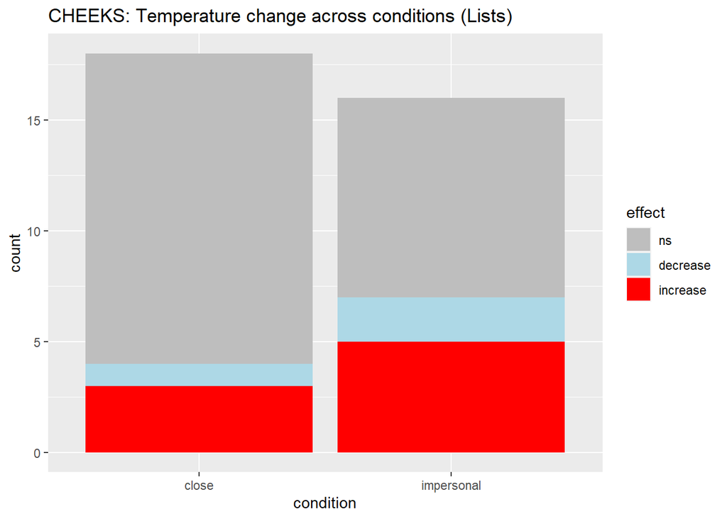

```r
ggplot(d |> filter(ROI=="Cheeks"), aes(condition, fill=effect))+
  geom_bar()+
  ggtitle("CHEEKS: Temperature change across conditions (Lists)")+
  scale_fill_manual(values = c("decrease" = "lightblue", "increase" = "red", "ns" = "gray"))
```

No effect of condition

```r
tidy(m <- nnet::multinom(effect ~ condition, data=d |> filter(ROI=="Cheeks"))) |>
  as_tibble() |>
  mutate(estimate = plogis(estimate)) # plogis transforms log odds (the output of the model) into probabilities
```

```
## # A tibble: 4 × 6
##   y.level  term                estimate std.error statistic p.value
##   <chr>    <chr>                  <dbl>     <dbl>     <dbl>   <dbl>
## 1 decrease (Intercept)           0.0667     1.04     -2.55   0.0108
## 2 decrease conditionimpersonal   0.757      1.30      0.875  0.382
## 3 increase (Intercept)           0.176      0.636    -2.42   0.0155
## 4 increase conditionimpersonal   0.722      0.846     1.13   0.260
```

```r
emmeans(m, pairwise~condition, by="effect")
```

```
## $emmeans
## effect = ns:
##  condition    prob     SE df lower.CL upper.CL
##  close      0.7778 0.0980  4  0.50571    1.050
##  impersonal 0.5625 0.1240  4  0.21817    0.907
##
## effect = decrease:
##  condition    prob     SE df lower.CL upper.CL
##  close      0.0556 0.0540  4 -0.09435    0.205
##  impersonal 0.1250 0.0827  4 -0.10456    0.355
##
## effect = increase:
##  condition    prob     SE df lower.CL upper.CL
##  close      0.1667 0.0878  4 -0.07722    0.411
##  impersonal 0.3125 0.1159  4 -0.00923    0.634
##
## Confidence level used: 0.95
##
## $contrasts
## effect = ns:
##  contrast           estimate     SE df t.ratio p.value
##  close - impersonal   0.2153 0.1581  4   1.362  0.2449
##
## effect = decrease:
##  contrast           estimate     SE df t.ratio p.value
##  close - impersonal  -0.0694 0.0987  4  -0.703  0.5207
##
## effect = increase:
##  contrast           estimate     SE df t.ratio p.value
##  close - impersonal  -0.1458 0.1454  4  -1.003  0.3727
```

```r
summary(m <- glmer(sign ~ condition + (1|speaker), d |> filter(ROI=="Cheeks"), family=binomial))
```

```
## boundary (singular) fit: see help('isSingular')
```

```
## Generalized linear mixed model fit by maximum likelihood (Laplace
##   Approximation) [glmerMod]
##  Family: binomial  ( logit )
## Formula: sign ~ condition + (1 | speaker)
##    Data: filter(d, ROI == "Cheeks")
##
##      AIC      BIC   logLik deviance df.resid
##     47.0     51.6    -20.5     41.0       31
##
## Scaled residuals:
##     Min      1Q  Median      3Q     Max
## -0.8819 -0.7951 -0.5345  1.1339  1.8708
##
## Random effects:
##  Groups  Name        Variance  Std.Dev.
##  speaker (Intercept) 7.206e-13 8.489e-07
## Number of obs: 34, groups:  speaker, 34
##
## Fixed effects:
##                     Estimate Std. Error z value Pr(>|z|)
## (Intercept)          -1.2528     0.5669   -2.21   0.0271 *
## conditionimpersonal   1.0014     0.7585    1.32   0.1868
## ---
## Signif. codes:  0 '***' 0.001 '**' 0.01 '*' 0.05 '.' 0.1 ' ' 1
##
## Correlation of Fixed Effects:
##             (Intr)
## cndtnmprsnl -0.747
## optimizer (Nelder_Mead) convergence code: 0 (OK)
## boundary (singular) fit: see help('isSingular')
```

No effect of the perception of their partner.

```r
tidy(m <- nnet::multinom(effect ~ becomeFriends, data=d |> filter(ROI=="Cheeks"))) |>
  as_tibble() |>
  mutate(estimate = plogis(estimate)) # plogis transforms log odds (the output of the model) into probabilities
```

```
## # A tibble: 4 × 6
##   y.level  term          estimate std.error statistic p.value
##   <chr>    <chr>            <dbl>     <dbl>     <dbl>   <dbl>
## 1 decrease (Intercept)      0.136     2.27    -0.815    0.415
## 2 decrease becomeFriends    0.492     0.364   -0.0847   0.932
## 3 increase (Intercept)      0.463     1.42    -0.103    0.918
## 4 increase becomeFriends    0.461     0.237   -0.655    0.512
```

```r
tidy(m <- nnet::multinom(effect ~ closeness, data=d |> filter(ROI=="Cheeks"))) |>
  as_tibble() |>
  mutate(estimate = plogis(estimate)) # plogis transforms log odds (the output of the model) into probabilities
```

```
## # A tibble: 4 × 6
##   y.level  term        estimate std.error  statistic p.value
##   <chr>    <chr>          <dbl>     <dbl>      <dbl>   <dbl>
## 1 decrease (Intercept)    0.338     1.38  -0.487       0.626
## 2 decrease closeness      0.405     0.396 -0.973       0.331
## 3 increase (Intercept)    0.500     0.960  0.0000900   1.00
## 4 increase closeness      0.429     0.250 -1.15        0.250
```

```r
tidy(m <- nnet::multinom(effect ~ similarity, data=d |> filter(ROI=="Cheeks"))) |>
  as_tibble() |>
  mutate(estimate = plogis(estimate)) # plogis transforms log odds (the output of the model) into probabilities
```

```
## # A tibble: 4 × 6
##   y.level  term        estimate std.error statistic p.value
##   <chr>    <chr>          <dbl>     <dbl>     <dbl>   <dbl>
## 1 decrease (Intercept)   0.0626     2.48     -1.09   0.275
## 2 decrease similarity    0.527      0.381     0.284  0.777
## 3 increase (Intercept)   0.826      1.40      1.11   0.268
## 4 increase similarity    0.380      0.266    -1.84   0.0652
```

```r
tidy(m <- nnet::multinom(effect ~ likeability, data=d |> filter(ROI=="Cheeks"))) |>
  as_tibble() |>
  mutate(estimate = plogis(estimate)) # plogis transforms log odds (the output of the model) into probabilities
```

```
## # A tibble: 4 × 6
##   y.level  term        estimate std.error statistic p.value
##   <chr>    <chr>          <dbl>     <dbl>     <dbl>   <dbl>
## 1 decrease (Intercept) 0.000404     5.20     -1.50    0.133
## 2 decrease likeability 0.682        0.652     1.17    0.241
## 3 increase (Intercept) 0.820        2.01      0.757   0.449
## 4 increase likeability 0.404        0.303    -1.28    0.200
```

Cheek temperature *increased less often* when the speaker scored higher in *agreeableness*. BUT pairwise comparison not running.

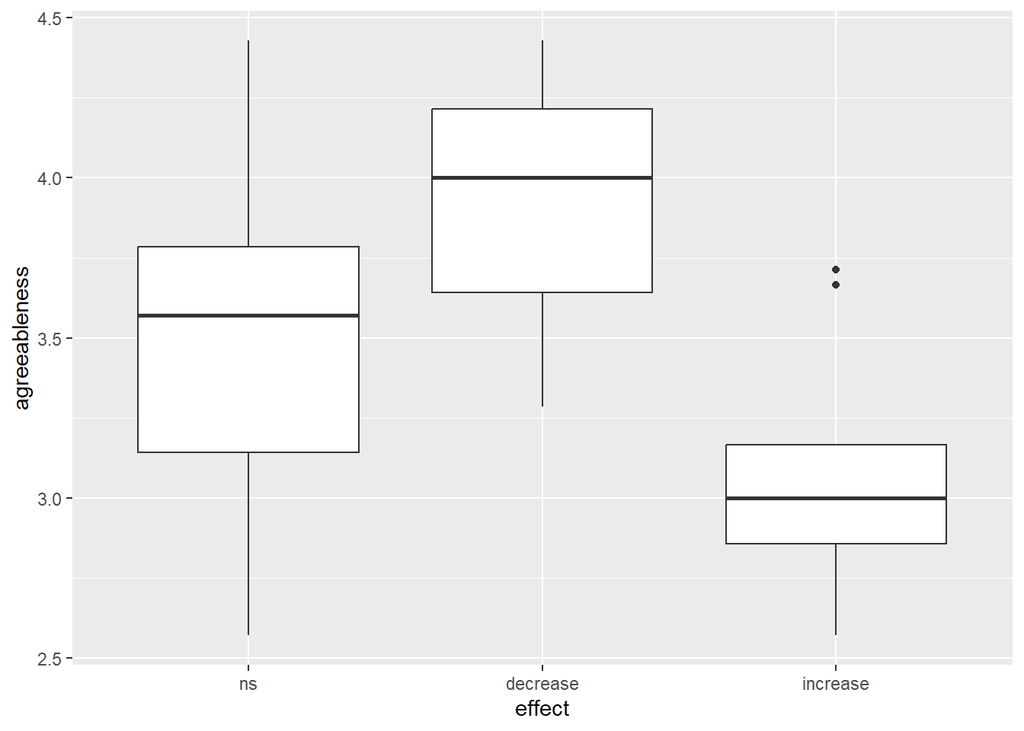

```r
ggplot(d |> filter(ROI=="Cheeks"), aes(effect, agreeableness))+
  geom_boxplot()
```

```r
tidy(m <- nnet::multinom(effect ~ agreeableness, data=d |> filter(ROI=="Cheeks"))) |>
  as_tibble() |>
  mutate(estimate = plogis(estimate)) # plogis transforms log odds (the output of the model) into probabilities
```

```
## # A tibble: 4 × 6
##   y.level  term           estimate std.error statistic p.value
##   <chr>    <chr>             <dbl>     <dbl>     <dbl>   <dbl>
## 1 decrease (Intercept)   0.0000652      6.16     -1.56  0.118
## 2 decrease agreeableness 0.885          1.59      1.28  0.199
## 3 increase (Intercept)   0.999          3.73      1.84  0.0658
## 4 increase agreeableness 0.0827         1.16     -2.08  0.0379
```

```r
tidy(m <- nnet::multinom(effect ~ extraversion, data=d |> filter(ROI=="Cheeks"))) |>
  as_tibble() |>
  mutate(estimate = plogis(estimate)) # plogis transforms log odds (the output of the model) into probabilities
```

```
## # A tibble: 4 × 6
##   y.level  term         estimate std.error statistic p.value
##   <chr>    <chr>           <dbl>     <dbl>     <dbl>   <dbl>
## 1 decrease (Intercept)   0.00138     4.29     -1.53    0.125
## 2 decrease extraversion  0.773       1.10      1.12    0.264
## 3 increase (Intercept)   0.699       2.49      0.338   0.735
## 4 increase extraversion  0.363       0.734    -0.763   0.445
```

```r
tidy(m <- nnet::multinom(effect ~ openness, data=d |> filter(ROI=="Cheeks"))) |>
  as_tibble() |>
  mutate(estimate = plogis(estimate)) # plogis transforms log odds (the output of the model) into probabilities
```

```
## # A tibble: 4 × 6
##   y.level  term        estimate std.error statistic p.value
##   <chr>    <chr>          <dbl>     <dbl>     <dbl>   <dbl>
## 1 decrease (Intercept)   0.0845     2.85     -0.836   0.403
## 2 decrease openness      0.524      0.760     0.125   0.901
## 3 increase (Intercept)   0.401      1.80     -0.224   0.823
## 4 increase openness      0.454      0.498    -0.370   0.711
```

```r
tidy(m <- nnet::multinom(effect ~ conscientiousness, data=d |> filter(ROI=="Cheeks"))) |>
  as_tibble() |>
  mutate(estimate = plogis(estimate)) # plogis transforms log odds (the output of the model) into probabilities
```

```
## # A tibble: 4 × 6
##   y.level  term              estimate std.error statistic p.value
##   <chr>    <chr>                <dbl>     <dbl>     <dbl>   <dbl>
## 1 decrease (Intercept)       0.000485     6.40     -1.19    0.233
## 2 decrease conscientiousness 0.792        1.48      0.903   0.366
## 3 increase (Intercept)       0.623        2.71      0.186   0.853
## 4 increase conscientiousness 0.403        0.683    -0.578   0.563
```

```r
tidy(m <- nnet::multinom(effect ~ neuroticism, data=d |> filter(ROI=="Cheeks"))) |>
  as_tibble() |>
  mutate(estimate = plogis(estimate)) # plogis transforms log odds (the output of the model) into probabilities
```

```
## # A tibble: 4 × 6
##   y.level  term        estimate std.error statistic p.value
##   <chr>    <chr>          <dbl>     <dbl>     <dbl>   <dbl>
## 1 decrease (Intercept)  0.00538     3.14      -1.66  0.0960
## 2 decrease neuroticism  0.727       0.894      1.10  0.273
## 3 increase (Intercept)  0.0218      2.04      -1.87  0.0620
## 4 increase neuroticism  0.702       0.601      1.42  0.155
```

No effect of thermal comfort

```r
tidy(m <- nnet::multinom(effect ~ comfortPre, data=d |> filter(ROI=="Cheeks"))) |>
  as_tibble() |>
  mutate(estimate = plogis(estimate)) # plogis transforms log odds (the output of the model) into probabilities
```

```
## # A tibble: 4 × 6
##   y.level  term        estimate std.error statistic p.value
##   <chr>    <chr>          <dbl>     <dbl>     <dbl>   <dbl>
## 1 decrease (Intercept)    0.953     3.53      0.853   0.393
## 2 decrease comfortPre     0.295     0.636    -1.37    0.171
## 3 increase (Intercept)    0.188     2.52     -0.579   0.563
## 4 increase comfortPre     0.516     0.392     0.162   0.871
```

```r
tidy(m <- nnet::multinom(effect ~ comfortPost, data=d |> filter(ROI=="Cheeks"))) |>
  as_tibble() |>
  mutate(estimate = plogis(estimate)) # plogis transforms log odds (the output of the model) into probabilities
```

```
## # A tibble: 4 × 6
##   y.level  term        estimate std.error statistic p.value
##   <chr>    <chr>          <dbl>     <dbl>     <dbl>   <dbl>
## 1 decrease (Intercept)    0.659     3.53      0.186   0.852
## 2 decrease comfortPost    0.388     0.606    -0.751   0.452
## 3 increase (Intercept)    0.627     2.36      0.220   0.826
## 4 increase comfortPost    0.435     0.391    -0.669   0.503
```

#### Second part of experiment (Diapix)

```r
d <- merge(all |>
             filter(section == "Diapix") |>
             select(-condition) |>
             mutate_at(c("sign", "effect"), as.factor),
           meta, by="speaker") |>
  mutate_at("condition", as.factor)
```

```r
# data set for poisson regression

dt <- d |>
  group_by(effect, condition, ROI) |>
  summarize(count = n()) |>
  right_join(crossing(effect = unique(d$effect), condition = unique(d$condition), ROI = unique(d$ROI))) |>
  mutate(count = replace_na(count, 0))
conditionCount <- d |>
  group_by(condition, ROI) |>
  summarize(condCount = n())
dt <- merge(dt, conditionCount, by=c("condition", "ROI"))

dt$effect <- relevel(dt$effect, ref="ns")
# contrasts(dt$condition) <- c(-.5,+.5)
dt$condition <- relevel(dt$condition, ref="close")
```

##### All ROIs together

Overall, there were more temperature *increases* in the *impersonal* condition.

There were also *fewer* non-effects in the *impersonal* condition.

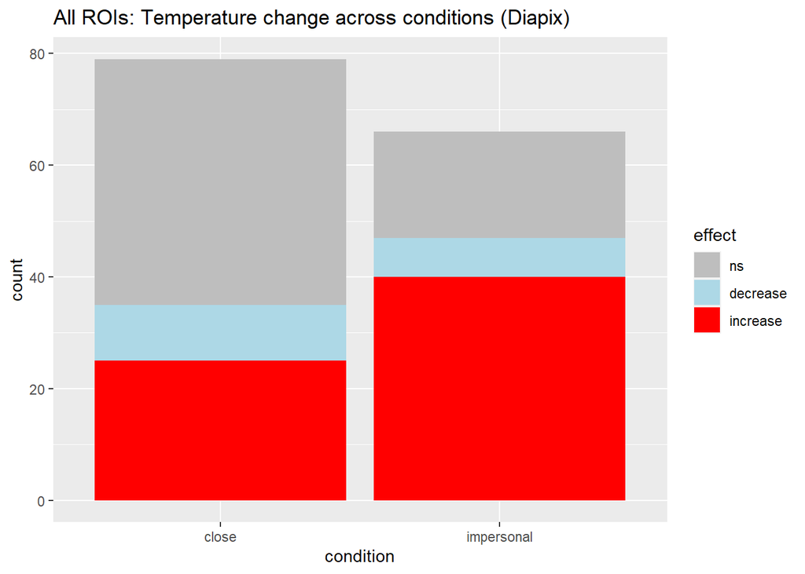

```r
ggplot(d, aes(condition, fill=effect))+
  geom_bar()+
  # facet_wrap(~condition)+
  ggtitle("All ROIs: Temperature change across conditions (Diapix)")+
  scale_fill_manual(values = c("decrease" = "lightblue", "increase" = "red", "ns" = "gray"))
```

```r
tidy(m <- nnet::multinom(effect ~ condition, data=d)) |>
  as_tibble() |>
  mutate(estimate = plogis(estimate)) # plogis transforms log odds (the output of the model) into probabilities
```

```
## # A tibble: 4 × 6
##   y.level  term                estimate std.error statistic   p.value
##   <chr>    <chr>                  <dbl>     <dbl>     <dbl>     <dbl>
## 1 decrease (Intercept)            0.185     0.350    -4.23  0.0000235
## 2 decrease conditionimpersonal    0.618     0.564     0.856 0.392
## 3 increase (Intercept)            0.362     0.250    -2.26  0.0240
## 4 increase conditionimpersonal    0.787     0.375     3.50  0.000473
```

```r
emmeans(m, pairwise~condition, by="effect")
```

```
## $emmeans
## effect = ns:
##  condition   prob     SE df lower.CL upper.CL
##  close      0.557 0.0559  4  0.40177    0.712
##  impersonal 0.288 0.0557  4  0.13316    0.443
##
## effect = decrease:
##  condition   prob     SE df lower.CL upper.CL
##  close      0.127 0.0374  4  0.02272    0.230
##  impersonal 0.106 0.0379  4  0.00083    0.211
##
## effect = increase:
##  condition   prob     SE df lower.CL upper.CL
##  close      0.316 0.0523  4  0.17118    0.462
##  impersonal 0.606 0.0601  4  0.43904    0.773
##
## Confidence level used: 0.95
##
## $contrasts
## effect = ns:
##  contrast           estimate     SE df t.ratio p.value
##  close - impersonal   0.2690 0.0789  4   3.409  0.0271
##
## effect = decrease:
##  contrast           estimate     SE df t.ratio p.value
##  close - impersonal   0.0205 0.0533  4   0.385  0.7195
##
## effect = increase:
##  contrast           estimate     SE df t.ratio p.value
##  close - impersonal  -0.2896 0.0797  4  -3.632  0.0221
```

```r
summary(m <- glmer(sign ~ condition + (1|speaker), d, family=binomial))
```

```
## Generalized linear mixed model fit by maximum likelihood (Laplace
##   Approximation) [glmerMod]
##  Family: binomial  ( logit )
## Formula: sign ~ condition + (1 | speaker)
##    Data: d
##
##      AIC      BIC   logLik deviance df.resid
##    193.6    202.5    -93.8    187.6      142
##
## Scaled residuals:
##     Min      1Q  Median      3Q     Max
## -1.5947 -0.8992  0.5985  0.6663  1.1643
##
## Random effects:
##  Groups  Name        Variance Std.Dev.
##  speaker (Intercept) 0.1007   0.3174
## Number of obs: 145, groups:  speaker, 38
##
## Fixed effects:
##                     Estimate Std. Error z value Pr(>|z|)
## (Intercept)          -0.2338     0.2406  -0.972  0.33109
## conditionimpersonal   1.1542     0.3778   3.055  0.00225 **
## ---
## Signif. codes:  0 '***' 0.001 '**' 0.01 '*' 0.05 '.' 0.1 ' ' 1
##
## Correlation of Fixed Effects:
##             (Intr)
## cndtnmprsnl -0.645
```

##### Nose

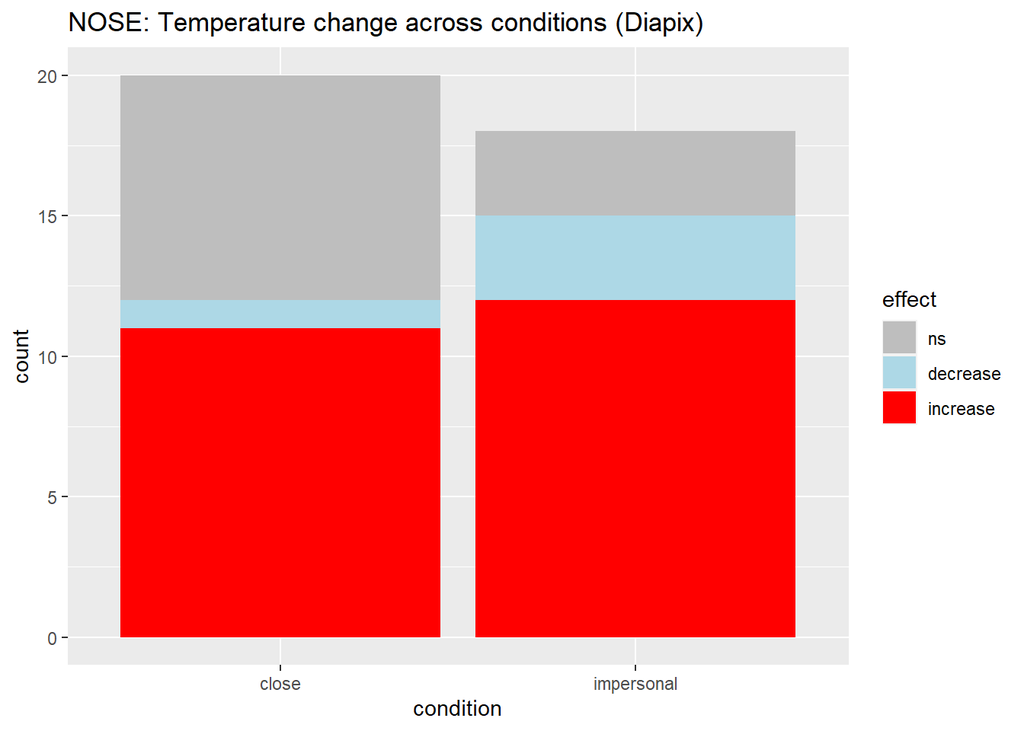

```r
ggplot(d |> filter(ROI=="Nose"), aes(condition, fill=effect))+
  geom_bar()+
  ggtitle("NOSE: Temperature change across conditions (Diapix)")+
  scale_fill_manual(values = c("decrease" = "lightblue", "increase" = "red", "ns" = "gray"))
```

No effect of condition

```r
tidy(m <- nnet::multinom(effect ~ condition, data=d |> filter(ROI=="Nose"))) |>
  as_tibble() |>
  mutate(estimate = plogis(estimate)) # plogis transforms log odds (the output of the model) into probabilities
```

```
## # A tibble: 4 × 6
##   y.level  term                estimate std.error statistic p.value
##   <chr>    <chr>                  <dbl>     <dbl>     <dbl>   <dbl>
## 1 decrease (Intercept)            0.111     1.06     -1.96   0.0499
## 2 decrease conditionimpersonal    0.889     1.34      1.55   0.120
## 3 increase (Intercept)            0.579     0.465     0.685  0.493
## 4 increase conditionimpersonal    0.744     0.795     1.34   0.179
```

```r
emmeans(m, pairwise~condition, by="effect")
```

```
## $emmeans
## effect = ns:
##  condition   prob     SE df lower.CL upper.CL
##  close      0.400 0.1095  4   0.0959    0.704
##  impersonal 0.167 0.0878  4  -0.0772    0.411
##
## effect = decrease:
##  condition   prob     SE df lower.CL upper.CL
##  close      0.050 0.0487  4  -0.0853    0.185
##  impersonal 0.167 0.0878  4  -0.0772    0.411
##
## effect = increase:
##  condition   prob     SE df lower.CL upper.CL
##  close      0.550 0.1112  4   0.2411    0.859
##  impersonal 0.667 0.1111  4   0.3582    0.975
##
## Confidence level used: 0.95
##
## $contrasts
## effect = ns:
##  contrast           estimate    SE df t.ratio p.value
##  close - impersonal    0.233 0.140  4   1.662  0.1719
##
## effect = decrease:
##  contrast           estimate    SE df t.ratio p.value
##  close - impersonal   -0.117 0.100  4  -1.161  0.3101
##
## effect = increase:
##  contrast           estimate    SE df t.ratio p.value
##  close - impersonal   -0.117 0.157  4  -0.742  0.4993
```

```r
summary(glmer(sign ~ condition + (1|speaker), d |> filter(ROI=="Nose"), family=binomial))
```

```
## boundary (singular) fit: see help('isSingular')
```

```
## Generalized linear mixed model fit by maximum likelihood (Laplace
##   Approximation) [glmerMod]
##  Family: binomial  ( logit )
## Formula: sign ~ condition + (1 | speaker)
##    Data: filter(d, ROI == "Nose")
##
##      AIC      BIC   logLik deviance df.resid
##     49.1     54.1    -21.6     43.1       35
##
## Scaled residuals:
##     Min      1Q  Median      3Q     Max
## -2.2361 -1.2247  0.4472  0.8165  0.8165
##
## Random effects:
##  Groups  Name        Variance  Std.Dev.
##  speaker (Intercept) 9.765e-11 9.882e-06
## Number of obs: 38, groups:  speaker, 38
##
## Fixed effects:
##                     Estimate Std. Error z value Pr(>|z|)
## (Intercept)           0.4055     0.4564   0.888    0.374
## conditionimpersonal   1.2040     0.7800   1.544    0.123
##
## Correlation of Fixed Effects:
##             (Intr)
## cndtnmprsnl -0.585
## optimizer (Nelder_Mead) convergence code: 0 (OK)
## boundary (singular) fit: see help('isSingular')
```

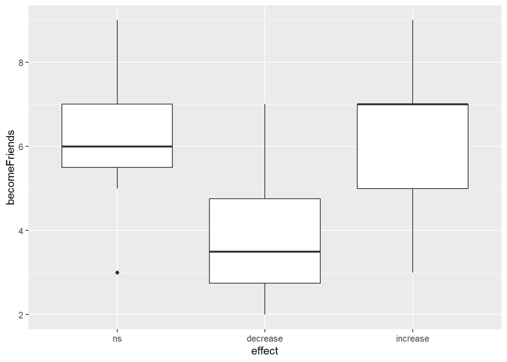

```r
ggplot(d |> filter(ROI=="Nose"), aes(effect, becomeFriends))+
  geom_boxplot()
```

```r
tidy(m <- nnet::multinom(effect ~ becomeFriends, data=d |> filter(ROI=="Nose"))) |>
  as_tibble() |>
  mutate(estimate = plogis(estimate)) # plogis transforms log odds (the output of the model) into probabilities
```

```
## # A tibble: 4 × 6
##   y.level  term          estimate std.error statistic p.value
##   <chr>    <chr>            <dbl>     <dbl>     <dbl>   <dbl>
## 1 decrease (Intercept)      0.950     1.95      1.51   0.130
## 2 decrease becomeFriends    0.317     0.388    -1.98   0.0474
## 3 increase (Intercept)      0.748     1.50      0.728  0.467
## 4 increase becomeFriends    0.486     0.233    -0.243  0.808
```

```r
tidy(m <- nnet::multinom(effect ~ closeness, data=d |> filter(ROI=="Nose"))) |>
  as_tibble() |>
  mutate(estimate = plogis(estimate)) # plogis transforms log odds (the output of the model) into probabilities
```

```
## # A tibble: 4 × 6
##   y.level  term        estimate std.error statistic p.value
##   <chr>    <chr>          <dbl>     <dbl>     <dbl>   <dbl>
## 1 decrease (Intercept)    0.784     1.35      0.955  0.340
## 2 decrease closeness      0.337     0.408    -1.66   0.0963
## 3 increase (Intercept)    0.864     0.934     1.98   0.0477
## 4 increase closeness      0.431     0.207    -1.35   0.178
```

```r
tidy(m <- nnet::multinom(effect ~ similarity, data=d |> filter(ROI=="Nose"))) |>
  as_tibble() |>
  mutate(estimate = plogis(estimate)) # plogis transforms log odds (the output of the model) into probabilities
```

```
## # A tibble: 4 × 6
##   y.level  term        estimate std.error statistic p.value
##   <chr>    <chr>          <dbl>     <dbl>     <dbl>   <dbl>
## 1 decrease (Intercept)    0.841     1.90      0.876   0.381
## 2 decrease similarity     0.375     0.367    -1.39    0.164
## 3 increase (Intercept)    0.805     1.32      1.08    0.281
## 4 increase similarity     0.471     0.215    -0.546   0.585
```

```r
tidy(m <- nnet::multinom(effect ~ likeability, data=d |> filter(ROI=="Nose"))) |>
  as_tibble() |>
  mutate(estimate = plogis(estimate)) # plogis transforms log odds (the output of the model) into probabilities
```

```
## # A tibble: 4 × 6
##   y.level  term        estimate std.error statistic p.value
##   <chr>    <chr>          <dbl>     <dbl>     <dbl>   <dbl>
## 1 decrease (Intercept)    0.902     3.15      0.706  0.480
## 2 decrease likeability    0.389     0.440    -1.02   0.305
## 3 increase (Intercept)    0.990     2.25      2.04   0.0415
## 4 increase likeability    0.368     0.304    -1.78   0.0746
```

Nose temperature *increased less often* when the person scored higher on *extraversion.*

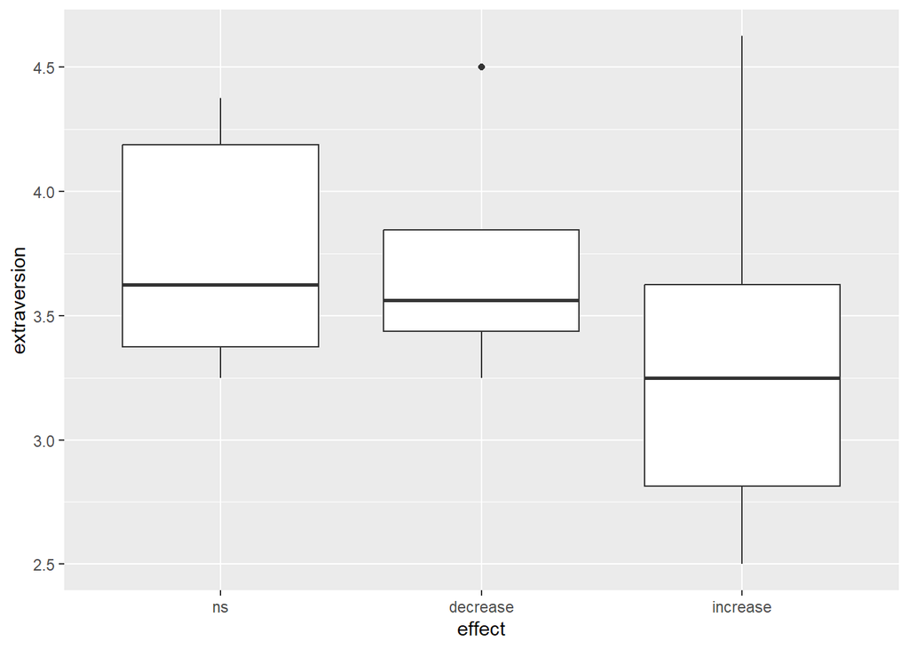

```r
ggplot(d |> filter(ROI=="Nose"), aes(effect, extraversion))+
  geom_boxplot()
```

```r
tidy(m <- nnet::multinom(effect ~ extraversion, data=d |> filter(ROI=="Nose"))) |>
  as_tibble() |>
  mutate(estimate = plogis(estimate)) # plogis transforms log odds (the output of the model) into probabilities
```

```
## # A tibble: 4 × 6
##   y.level  term         estimate std.error statistic p.value
##   <chr>    <chr>           <dbl>     <dbl>     <dbl>   <dbl>
## 1 decrease (Intercept)     0.374     3.87     -0.133  0.894
## 2 decrease extraversion    0.467     1.03     -0.129  0.897
## 3 increase (Intercept)     0.998     2.63      2.38   0.0172
## 4 increase extraversion    0.171     0.729    -2.16   0.0304
```

Nose temperature tended to *change less often* (both directions) when the person scored higher on *openness*. But only the p value of the temperature *increases* stayed significant after adjustment.

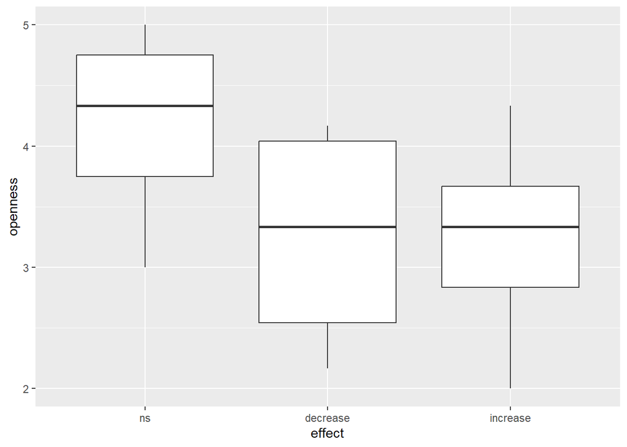

```r
ggplot(d |> filter(ROI=="Nose"), aes(effect, openness))+
  geom_boxplot()
```

```r
tidy(m <- nnet::multinom(effect ~ openness, data=d |> filter(ROI=="Nose"))) |>
  as_tibble() |>
  mutate(estimate = plogis(estimate)) # plogis transforms log odds (the output of the model) into probabilities
```

```
## # A tibble: 4 × 6
##   y.level  term        estimate std.error statistic p.value
##   <chr>    <chr>          <dbl>     <dbl>     <dbl>   <dbl>
## 1 decrease (Intercept)   0.999      3.74       1.96 0.0502
## 2 decrease openness      0.0994     1.00      -2.20 0.0278
## 3 increase (Intercept)   1.00       3.09       2.95 0.00321
## 4 increase openness      0.0980     0.780     -2.85 0.00442
```

```r
tidy(m <- nnet::multinom(effect ~ agreeableness, data=d |> filter(ROI=="Nose"))) |>
  as_tibble() |>
  mutate(estimate = plogis(estimate)) # plogis transforms log odds (the output of the model) into probabilities
```

```
## # A tibble: 4 × 6
##   y.level  term          estimate std.error statistic p.value
##   <chr>    <chr>            <dbl>     <dbl>     <dbl>   <dbl>
## 1 decrease (Intercept)    0.00236     4.60     -1.32    0.188
## 2 decrease agreeableness  0.801       1.23      1.13    0.259
## 3 increase (Intercept)    0.769       2.56      0.471   0.637
## 4 increase agreeableness  0.466       0.738    -0.185   0.853
```

```r
tidy(m <- nnet::multinom(effect ~ conscientiousness, data=d |> filter(ROI=="Nose"))) |>
  as_tibble() |>
  mutate(estimate = plogis(estimate)) # plogis transforms log odds (the output of the model) into probabilities
```

```
## # A tibble: 4 × 6
##   y.level  term              estimate std.error statistic p.value
##   <chr>    <chr>                <dbl>     <dbl>     <dbl>   <dbl>
## 1 decrease (Intercept)        0.00213     6.47     -0.950   0.342
## 2 decrease conscientiousness  0.768       1.48      0.808   0.419
## 3 increase (Intercept)        0.992       3.15      1.54    0.123
## 4 increase conscientiousness  0.265       0.763    -1.34    0.181
```

```r
tidy(m <- nnet::multinom(effect ~ neuroticism, data=d |> filter(ROI=="Nose"))) |>
  as_tibble() |>
  mutate(estimate = plogis(estimate)) # plogis transforms log odds (the output of the model) into probabilities
```

```
## # A tibble: 4 × 6
##   y.level  term        estimate std.error statistic p.value
##   <chr>    <chr>          <dbl>     <dbl>     <dbl>   <dbl>
## 1 decrease (Intercept)   0.0504     2.94     -1.00    0.317
## 2 decrease neuroticism   0.641      0.847     0.683   0.495
## 3 increase (Intercept)   0.789      1.66      0.794   0.427
## 4 increase neuroticism   0.454      0.514    -0.361   0.718
```

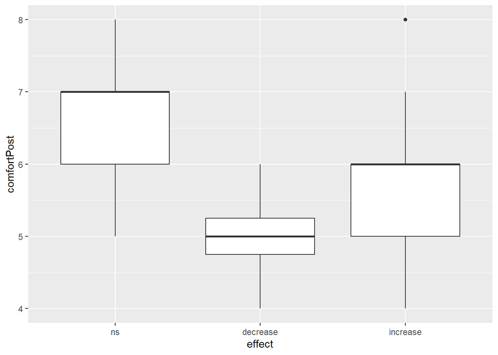

```r
ggplot(d |> filter(ROI=="Nose"), aes(effect, comfortPost))+
  geom_boxplot()
```

Nose temperature had *increased and decreased less often* when the speaker felt more comfortable at the end of the experiment.

```r
tidy(m <- nnet::multinom(effect ~ comfortPost, data=d |> filter(ROI=="Nose"))) |>
  as_tibble() |>
  mutate(estimate = plogis(estimate)) # plogis transforms log odds (the output of the model) into probabilities
```

```
## # A tibble: 4 × 6
##   y.level  term        estimate std.error statistic p.value
##   <chr>    <chr>          <dbl>     <dbl>     <dbl>   <dbl>
## 1 decrease (Intercept)    1.00      4.76       2.17  0.0297
## 2 decrease comfortPost    0.120     0.883     -2.25  0.0242
## 3 increase (Intercept)    0.997     2.55       2.31  0.0211
## 4 increase comfortPost    0.304     0.399     -2.08  0.0377
```

```r
tidy(m <- nnet::multinom(effect ~ comfortPre, data=d |> filter(ROI=="Nose"))) |>
  as_tibble() |>
  mutate(estimate = plogis(estimate)) # plogis transforms log odds (the output of the model) into probabilities
```

```
## # A tibble: 4 × 6
##   y.level  term        estimate std.error statistic p.value
##   <chr>    <chr>          <dbl>     <dbl>     <dbl>   <dbl>
## 1 decrease (Intercept)    0.994     3.68      1.41    0.158
## 2 decrease comfortPre     0.255     0.658    -1.63    0.102
## 3 increase (Intercept)    0.883     2.21      0.913   0.361
## 4 increase comfortPre     0.449     0.347    -0.591   0.554
```

##### Eyes

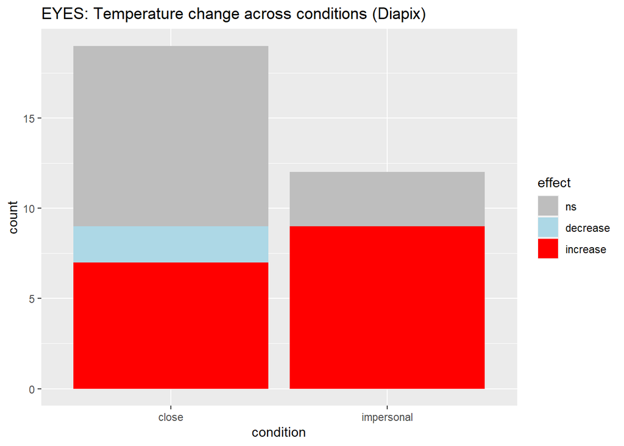

```r
ggplot(d |> filter(ROI=="Eyes"), aes(condition, fill=effect))+
  geom_bar()+
  ggtitle("EYES: Temperature change across conditions (Diapix)")+
  scale_fill_manual(values = c("decrease" = "lightblue", "increase" = "red", "ns" = "gray"))
```

No effect of condition

```r
tidy(m <- nnet::multinom(effect ~ condition, data=d |> filter(ROI=="Eyes"))) |>
  as_tibble() |>
  mutate(estimate = plogis(estimate)) # plogis transforms log odds (the output of the model) into probabilities
```

```
## # A tibble: 4 × 6
##   y.level  term                estimate std.error statistic p.value
##   <chr>    <chr>                  <dbl>     <dbl>     <dbl>   <dbl>
## 1 decrease (Intercept)         0.167        0.775    -2.08   0.0377
## 2 decrease conditionimpersonal 0.000524    56.4      -0.134  0.893
## 3 increase (Intercept)         0.412        0.493    -0.724  0.469
## 4 increase conditionimpersonal 0.811        0.829     1.76   0.0792
```

```r
emmeans(m, pairwise~condition, by="effect")
```

```
## $emmeans
## effect = ns:
##  condition      prob      SE df lower.CL upper.CL
##  close      5.26e-01 0.11455  4  0.20830  0.84437
##  impersonal 2.50e-01 0.12500  4 -0.09706  0.59703
##
## effect = decrease:
##  condition      prob      SE df lower.CL upper.CL
##  close      1.05e-01 0.07040  4 -0.09022  0.30072
##  impersonal 2.62e-05 0.00148  4 -0.00408  0.00413
##
## effect = increase:
##  condition      prob      SE df lower.CL upper.CL
##  close      3.68e-01 0.11066  4  0.06116  0.67567
##  impersonal 7.50e-01 0.12500  4  0.40293  1.09705
##
## Confidence level used: 0.95
##
## $contrasts
## effect = ns:
##  contrast           estimate     SE df t.ratio p.value
##  close - impersonal    0.276 0.1695  4   1.630  0.1784
##
## effect = decrease:
##  contrast           estimate     SE df t.ratio p.value
##  close - impersonal    0.105 0.0704  4   1.494  0.2094
##
## effect = increase:
##  contrast           estimate     SE df t.ratio p.value
##  close - impersonal   -0.382 0.1669  4  -2.286  0.0843
```

```r
summary(glmer(sign ~ condition + (1|speaker), d |> filter(ROI=="Eyes"), family=binomial))
```

```
## boundary (singular) fit: see help('isSingular')
```

```
## Generalized linear mixed model fit by maximum likelihood (Laplace
##   Approximation) [glmerMod]
##  Family: binomial  ( logit )
## Formula: sign ~ condition + (1 | speaker)
##    Data: filter(d, ROI == "Eyes")
##
##      AIC      BIC   logLik deviance df.resid
##     45.8     50.1    -19.9     39.8       28
##
## Scaled residuals:
##     Min      1Q  Median      3Q     Max
## -1.7321 -0.9487  0.5774  1.0541  1.0541
##
## Random effects:
##  Groups  Name        Variance Std.Dev.
##  speaker (Intercept) 4e-12    2e-06
## Number of obs: 31, groups:  speaker, 31
##
## Fixed effects:
##                     Estimate Std. Error z value Pr(>|z|)
## (Intercept)          -0.1054     0.4595  -0.229    0.819
## conditionimpersonal   1.2040     0.8097   1.487    0.137
##
## Correlation of Fixed Effects:
##             (Intr)
## cndtnmprsnl -0.567
## optimizer (Nelder_Mead) convergence code: 0 (OK)
## boundary (singular) fit: see help('isSingular')
```

Eye temperature *increased less often* when the speaker felt *closer* to their partner.

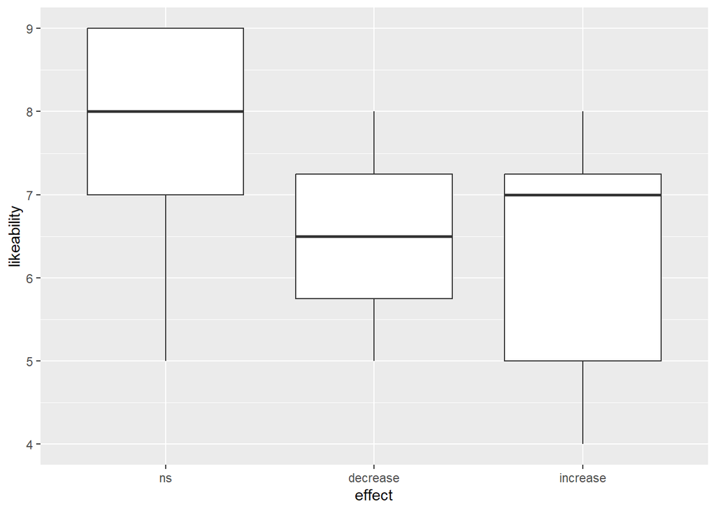

```r
ggplot(d |> filter(ROI=="Eyes"), aes(effect, likeability))+
  geom_boxplot()
```

```r
tidy(m <- nnet::multinom(effect ~ closeness, data=d |> filter(ROI=="Eyes"))) |>
  as_tibble() |>
  mutate(estimate = plogis(estimate)) # plogis transforms log odds (the output of the model) into probabilities
```

```
## # A tibble: 4 × 6
##   y.level  term        estimate std.error statistic p.value
##   <chr>    <chr>          <dbl>     <dbl>     <dbl>   <dbl>
## 1 decrease (Intercept)    0.754     1.69      0.664  0.506
## 2 decrease closeness      0.274     0.651    -1.49   0.135
## 3 increase (Intercept)    0.880     0.973     2.04   0.0409
## 4 increase closeness      0.383     0.235    -2.03   0.0425
```

```r
tidy(m <- nnet::multinom(effect ~ becomeFriends, data=d |> filter(ROI=="Eyes"))) |>
  as_tibble() |>
  mutate(estimate = plogis(estimate)) # plogis transforms log odds (the output of the model) into probabilities
```

```
## # A tibble: 4 × 6
##   y.level  term          estimate std.error statistic p.value
##   <chr>    <chr>            <dbl>     <dbl>     <dbl>   <dbl>
## 1 decrease (Intercept)     0.0968     3.58     -0.625   0.532
## 2 decrease becomeFriends   0.514      0.539     0.104   0.917
## 3 increase (Intercept)     0.833      1.56      1.03    0.305
## 4 increase becomeFriends   0.443      0.246    -0.929   0.353
```

```r
tidy(m <- nnet::multinom(effect ~ similarity, data=d |> filter(ROI=="Eyes"))) |>
  as_tibble() |>
  mutate(estimate = plogis(estimate)) # plogis transforms log odds (the output of the model) into probabilities
```

```
## # A tibble: 4 × 6
##   y.level  term        estimate std.error statistic p.value
##   <chr>    <chr>          <dbl>     <dbl>     <dbl>   <dbl>
## 1 decrease (Intercept)    0.151     2.63    -0.658    0.510
## 2 decrease similarity     0.494     0.418   -0.0563   0.955
## 3 increase (Intercept)    0.766     1.26     0.946    0.344
## 4 increase similarity     0.458     0.206   -0.823    0.410
```

```r
tidy(m <- nnet::multinom(effect ~ likeability, data=d |> filter(ROI=="Eyes"))) |>
  as_tibble() |>
  mutate(estimate = plogis(estimate)) # plogis transforms log odds (the output of the model) into probabilities
```

```
## # A tibble: 4 × 6
##   y.level  term        estimate std.error statistic p.value
##   <chr>    <chr>          <dbl>     <dbl>     <dbl>   <dbl>
## 1 decrease (Intercept)    0.858     3.81      0.473  0.636
## 2 decrease likeability    0.372     0.559    -0.939  0.348
## 3 increase (Intercept)    0.983     2.17      1.88   0.0603
## 4 increase likeability    0.364     0.303    -1.84   0.0664
```

Eye temperature *increased less often* when the speaker scored higher on agreeableness.

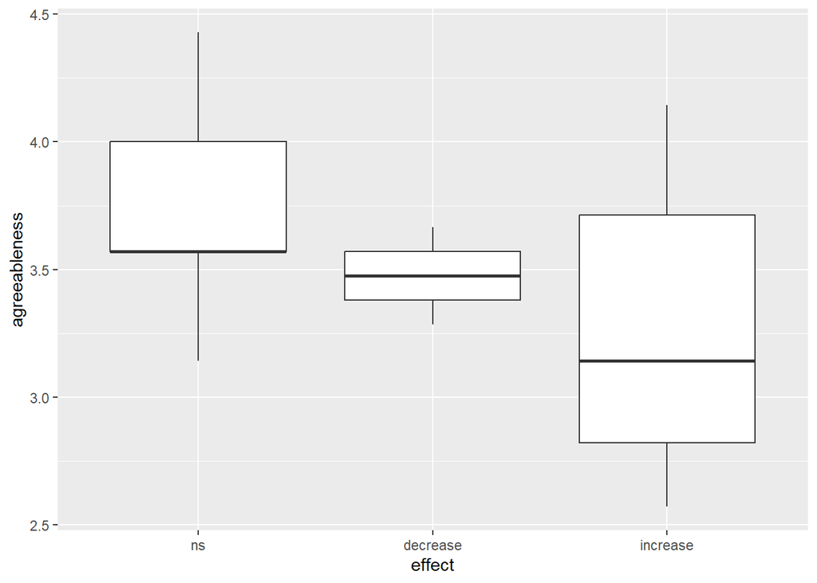

```r
ggplot(d |> filter(ROI=="Eyes"), aes(effect, agreeableness))+
  geom_boxplot()
```

```r
tidy(m <- nnet::multinom(effect ~ agreeableness, data=d |> filter(ROI=="Eyes"))) |>
  as_tibble() |>
  mutate(estimate = plogis(estimate)) # plogis transforms log odds (the output of the model) into probabilities
```

```
## # A tibble: 4 × 6
##   y.level  term          estimate std.error statistic p.value
##   <chr>    <chr>            <dbl>     <dbl>     <dbl>   <dbl>
## 1 decrease (Intercept)     0.883      5.92      0.342  0.732
## 2 decrease agreeableness   0.253      1.67     -0.649  0.516
## 3 increase (Intercept)     1.00       3.47      2.36   0.0181
## 4 increase agreeableness   0.0901     0.991    -2.33   0.0196
```

```r
tidy(m <- nnet::multinom(effect ~ extraversion, data=d |> filter(ROI=="Eyes"))) |>
  as_tibble() |>
  mutate(estimate = plogis(estimate)) # plogis transforms log odds (the output of the model) into probabilities
```

```
## # A tibble: 4 × 6
##   y.level  term         estimate std.error statistic p.value
##   <chr>    <chr>           <dbl>     <dbl>     <dbl>   <dbl>
## 1 decrease (Intercept)    0.0529     4.57     -0.631   0.528
## 2 decrease extraversion   0.570      1.25      0.227   0.820
## 3 increase (Intercept)    0.804      2.17      0.649   0.516
## 4 increase extraversion   0.414      0.619    -0.563   0.573
```

```r
tidy(m <- nnet::multinom(effect ~ openness, data=d |> filter(ROI=="Eyes"))) |>
  as_tibble() |>
  mutate(estimate = plogis(estimate)) # plogis transforms log odds (the output of the model) into probabilities
```

```
## # A tibble: 4 × 6
##   y.level  term        estimate std.error statistic p.value
##   <chr>    <chr>          <dbl>     <dbl>     <dbl>   <dbl>
## 1 decrease (Intercept)   0.0154     3.86     -1.08    0.281
## 2 decrease openness      0.649      0.977     0.629   0.529
## 3 increase (Intercept)   0.787      1.60      0.816   0.415
## 4 increase openness      0.420      0.457    -0.708   0.479
```

```r
tidy(m <- nnet::multinom(effect ~ conscientiousness, data=d |> filter(ROI=="Eyes"))) |>
  as_tibble() |>
  mutate(estimate = plogis(estimate)) # plogis transforms log odds (the output of the model) into probabilities
```

```
## # A tibble: 4 × 6
##   y.level  term              estimate std.error statistic p.value
##   <chr>    <chr>                <dbl>     <dbl>     <dbl>   <dbl>
## 1 decrease (Intercept)        0.00197     8.29     -0.752   0.452
## 2 decrease conscientiousness  0.739       1.94      0.537   0.592
## 3 increase (Intercept)        0.983       3.28      1.24    0.215
## 4 increase conscientiousness  0.275       0.814    -1.19    0.234
```

```r
tidy(m <- nnet::multinom(effect ~ neuroticism, data=d |> filter(ROI=="Eyes"))) |>
  as_tibble() |>
  mutate(estimate = plogis(estimate)) # plogis transforms log odds (the output of the model) into probabilities
```

```
## # A tibble: 4 × 6
##   y.level  term        estimate std.error statistic p.value
##   <chr>    <chr>          <dbl>     <dbl>     <dbl>   <dbl>
## 1 decrease (Intercept)    0.195     3.77    -0.376    0.707
## 2 decrease neuroticism    0.463     1.23    -0.122    0.903
## 3 increase (Intercept)    0.572     1.87     0.156    0.876
## 4 increase neuroticism    0.493     0.600   -0.0460   0.963
```

No effect of thermal comfort

```r
tidy(m <- nnet::multinom(effect ~ comfortPre, data=d |> filter(ROI=="Eyes"))) |>
  as_tibble() |>
  mutate(estimate = plogis(estimate)) # plogis transforms log odds (the output of the model) into probabilities
```

```
## # A tibble: 4 × 6
##   y.level  term           estimate std.error statistic p.value
##   <chr>    <chr>             <dbl>     <dbl>     <dbl>   <dbl>
## 1 decrease (Intercept) 0.000000201     9.41    -1.64     0.101
## 2 decrease comfortPre  0.877           1.27     1.54     0.124
## 3 increase (Intercept) 0.572           2.28     0.128    0.898
## 4 increase comfortPre  0.497           0.370   -0.0374   0.970
```

```r
tidy(m <- nnet::multinom(effect ~ comfortPost, data=d |> filter(ROI=="Eyes"))) |>
  as_tibble() |>
  mutate(estimate = plogis(estimate)) # plogis transforms log odds (the output of the model) into probabilities
```

```
## # A tibble: 4 × 6
##   y.level  term          estimate std.error statistic p.value
##   <chr>    <chr>            <dbl>     <dbl>     <dbl>   <dbl>
## 1 decrease (Intercept) 0.00000217     8.25      -1.58   0.114
## 2 decrease comfortPost 0.835          1.12       1.45   0.146
## 3 increase (Intercept) 0.961          2.31       1.38   0.167
## 4 increase comfortPost 0.374          0.392     -1.31   0.189
```

##### Forehead

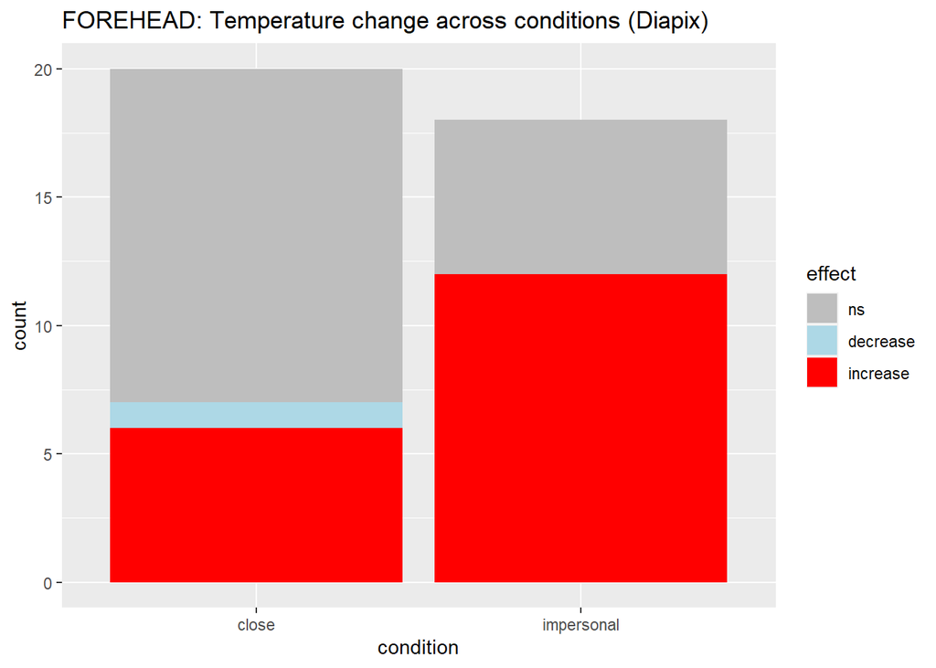

```r
ggplot(d |> filter(ROI=="Forehead"), aes(condition, fill=effect))+
  geom_bar()+
  ggtitle("FOREHEAD: Temperature change across conditions (Diapix)")+
  scale_fill_manual(values = c("decrease" = "lightblue", "increase" = "red", "ns" = "gray"))
```

More increases in *impersonal*, but adjusted p value = 0.07

```r
tidy(m <- nnet::multinom(effect ~ condition, data=d |> filter(ROI=="Forehead"))) |>
  as_tibble() |>
  mutate(estimate = plogis(estimate)) # plogis transforms log odds (the output of the model) into probabilities
```

```
## # A tibble: 4 × 6
##   y.level  term                estimate std.error statistic p.value
##   <chr>    <chr>                  <dbl>     <dbl>     <dbl>   <dbl>
## 1 decrease (Intercept)          0.0713      1.04     -2.47   0.0135
## 2 decrease conditionimpersonal  0.00317    26.2      -0.220  0.826
## 3 increase (Intercept)          0.316       0.494    -1.57   0.117
## 4 increase conditionimpersonal  0.813       0.703     2.09   0.0368
```

```r
emmeans(m, pairwise~condition, by="effect")
```

```
## $emmeans
## effect = ns:
##  condition      prob      SE df lower.CL upper.CL
##  close      6.50e-01 0.10665  4  0.35393  0.94615
##  impersonal 3.33e-01 0.11109  4  0.02465  0.64153
##
## effect = decrease:
##  condition      prob      SE df lower.CL upper.CL
##  close      4.99e-02 0.04869  4 -0.08528  0.18507
##  impersonal 8.13e-05 0.00213  4 -0.00582  0.00598
##
## effect = increase:
##  condition      prob      SE df lower.CL upper.CL
##  close      3.00e-01 0.10248  4  0.01555  0.58459
##  impersonal 6.67e-01 0.11110  4  0.35837  0.97528
##
## Confidence level used: 0.95
##
## $contrasts
## effect = ns:
##  contrast           estimate     SE df t.ratio p.value
##  close - impersonal   0.3169 0.1540  4   2.058  0.1087
##
## effect = decrease:
##  contrast           estimate     SE df t.ratio p.value
##  close - impersonal   0.0498 0.0487  4   1.022  0.3645
##
## effect = increase:
##  contrast           estimate     SE df t.ratio p.value
##  close - impersonal  -0.3668 0.1511  4  -2.427  0.0722
```

```r
summary(glmer(sign ~ condition + (1|speaker), d |> filter(ROI=="Forehead"), family=binomial))
```

```
## boundary (singular) fit: see help('isSingular')
```

```
## Generalized linear mixed model fit by maximum likelihood (Laplace
##   Approximation) [glmerMod]
##  Family: binomial  ( logit )
## Formula: sign ~ condition + (1 | speaker)
##    Data: filter(d, ROI == "Forehead")
##
##      AIC      BIC   logLik deviance df.resid
##     54.8     59.7    -24.4     48.8       35
##
## Scaled residuals:
##      Min       1Q   Median       3Q      Max
## -1.41421 -0.73380 -0.01335  0.70711  1.36277
##
## Random effects:
##  Groups  Name        Variance Std.Dev.
##  speaker (Intercept) 1e-12    1e-06
## Number of obs: 38, groups:  speaker, 38
##
## Fixed effects:
##                     Estimate Std. Error z value Pr(>|z|)
## (Intercept)          -0.6190     0.4688  -1.320   0.1867
## conditionimpersonal   1.3122     0.6854   1.914   0.0556 .
## ---
## Signif. codes:  0 '***' 0.001 '**' 0.01 '*' 0.05 '.' 0.1 ' ' 1
##
## Correlation of Fixed Effects:
##             (Intr)
## cndtnmprsnl -0.684
## optimizer (Nelder_Mead) convergence code: 0 (OK)
## boundary (singular) fit: see help('isSingular')
```

Forehead temperature *increased less often* when the speaker *liked* their partner *more*.

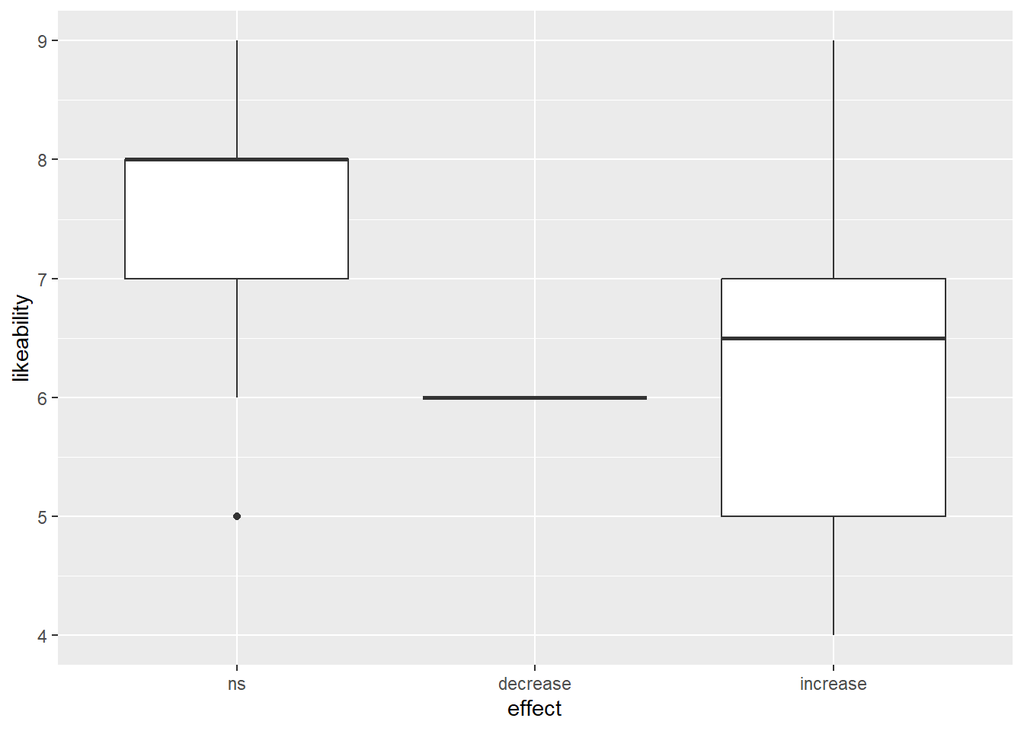

```r
ggplot(d |> filter(ROI=="Forehead"), aes(effect, likeability))+
  geom_boxplot()
```

```r
tidy(m <- nnet::multinom(effect ~ likeability, data=d |> filter(ROI=="Forehead"))) |>
  as_tibble() |>
  mutate(estimate = plogis(estimate)) # plogis transforms log odds (the output of the model) into probabilities
```

```
## # A tibble: 4 × 6
##   y.level  term        estimate std.error statistic p.value
##   <chr>    <chr>          <dbl>     <dbl>     <dbl>   <dbl>
## 1 decrease (Intercept)    0.930     4.84      0.534  0.594
## 2 decrease likeability    0.306     0.772    -1.06   0.290
## 3 increase (Intercept)    0.990     2.00      2.29   0.0219
## 4 increase likeability    0.338     0.283    -2.37   0.0178
```

```r
tidy(m <- nnet::multinom(effect ~ becomeFriends, data=d |> filter(ROI=="Forehead"))) |>
  as_tibble() |>
  mutate(estimate = plogis(estimate)) # plogis transforms log odds (the output of the model) into probabilities
```

```
## # A tibble: 4 × 6
##   y.level  term          estimate std.error statistic p.value
##   <chr>    <chr>            <dbl>     <dbl>     <dbl>   <dbl>
## 1 decrease (Intercept)      0.936     3.46      0.773   0.439
## 2 decrease becomeFriends    0.217     1.04     -1.24    0.216
## 3 increase (Intercept)      0.682     1.25      0.612   0.540
## 4 increase becomeFriends    0.466     0.199    -0.680   0.496
```

```r
tidy(m <- nnet::multinom(effect ~ closeness, data=d |> filter(ROI=="Forehead"))) |>
  as_tibble() |>
  mutate(estimate = plogis(estimate)) # plogis transforms log odds (the output of the model) into probabilities
```

```
## # A tibble: 4 × 6
##   y.level  term        estimate std.error statistic p.value
##   <chr>    <chr>          <dbl>     <dbl>     <dbl>   <dbl>
## 1 decrease (Intercept)   0.0634     2.45     -1.10   0.272
## 2 decrease closeness     0.485      0.556    -0.110  0.912
## 3 increase (Intercept)   0.770      0.791     1.53   0.127
## 4 increase closeness     0.414      0.198    -1.75   0.0808
```

```r
tidy(m <- nnet::multinom(effect ~ similarity, data=d |> filter(ROI=="Forehead"))) |>
  as_tibble() |>
  mutate(estimate = plogis(estimate)) # plogis transforms log odds (the output of the model) into probabilities
```

```
## # A tibble: 4 × 6
##   y.level  term        estimate std.error statistic p.value
##   <chr>    <chr>          <dbl>     <dbl>     <dbl>   <dbl>
## 1 decrease (Intercept)    0.712     3.17      0.286   0.775
## 2 decrease similarity     0.316     0.725    -1.06    0.288
## 3 increase (Intercept)    0.838     1.18      1.39    0.165
## 4 increase similarity     0.426     0.200    -1.50    0.134
```

Forehead temperature *increased less often* when the speaker scored higher in *extraversion.*

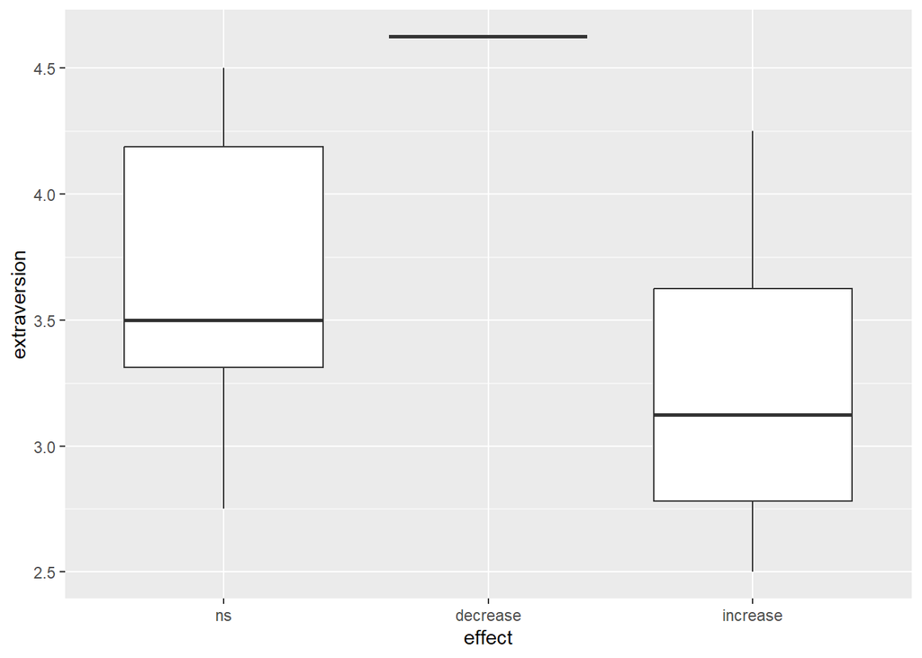

```r
ggplot(d |> filter(ROI=="Forehead"), aes(effect, extraversion))+
  geom_boxplot()
```

```r
tidy(m <- nnet::multinom(effect ~ extraversion, data=d |> filter(ROI=="Forehead"))) |>
  as_tibble() |>
  mutate(estimate = plogis(estimate)) # plogis transforms log odds (the output of the model) into probabilities
```

```
## # A tibble: 4 × 6
##   y.level  term         estimate std.error statistic p.value
##   <chr>    <chr>           <dbl>     <dbl>     <dbl>   <dbl>
## 1 decrease (Intercept)  1.55e-16    39.4      -0.923  0.356
## 2 decrease extraversion 1.00e+ 0     8.81      0.885  0.376
## 3 increase (Intercept)  9.98e- 1     2.61      2.47   0.0135
## 4 increase extraversion 1.31e- 1     0.761    -2.49   0.0127
```

Forehead temperature also *increased less often* when the speaker scored higher in *openness*.

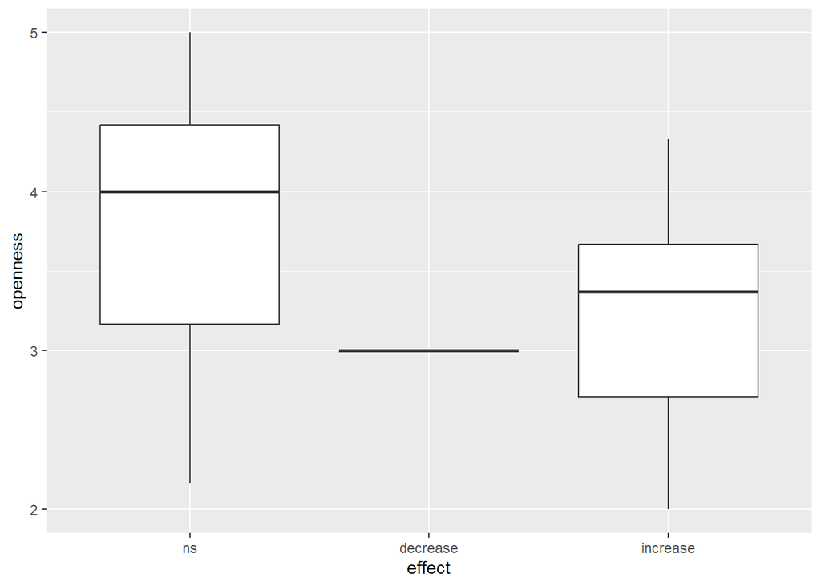

```r
ggplot(d |> filter(ROI=="Forehead"), aes(effect, openness))+
  geom_boxplot()
```

```r
tidy(m <- nnet::multinom(effect ~ openness, data=d |> filter(ROI=="Forehead"))) |>
  as_tibble() |>
  mutate(estimate = plogis(estimate)) # plogis transforms log odds (the output of the model) into probabilities
```

```
## # A tibble: 4 × 6
##   y.level  term        estimate std.error statistic p.value
##   <chr>    <chr>          <dbl>     <dbl>     <dbl>   <dbl>
## 1 decrease (Intercept)    0.855     4.43      0.402  0.688
## 2 decrease openness       0.200     1.41     -0.984  0.325
## 3 increase (Intercept)    0.964     1.70      1.94   0.0523
## 4 increase openness       0.279     0.470    -2.02   0.0438
```

```r
tidy(m <- nnet::multinom(effect ~ agreeableness, data=d |> filter(ROI=="Forehead"))) |>
  as_tibble() |>
  mutate(estimate = plogis(estimate)) # plogis transforms log odds (the output of the model) into probabilities
```

```
## # A tibble: 4 × 6
##   y.level  term          estimate std.error statistic p.value
##   <chr>    <chr>            <dbl>     <dbl>     <dbl>   <dbl>
## 1 decrease (Intercept)    0.00307     7.74     -0.747   0.455
## 2 decrease agreeableness  0.687       2.07      0.379   0.705
## 3 increase (Intercept)    0.858       2.31      0.777   0.437
## 4 increase agreeableness  0.369       0.664    -0.808   0.419
```

```r
tidy(m <- nnet::multinom(effect ~ conscientiousness, data=d |> filter(ROI=="Forehead"))) |>
  as_tibble() |>
  mutate(estimate = plogis(estimate)) # plogis transforms log odds (the output of the model) into probabilities
```

```
## # A tibble: 4 × 6
##   y.level  term              estimate std.error statistic p.value
##   <chr>    <chr>                <dbl>     <dbl>     <dbl>   <dbl>
## 1 decrease (Intercept)          0.950     6.19      0.477   0.633
## 2 decrease conscientiousness    0.183     1.64     -0.913   0.361
## 3 increase (Intercept)          0.976     2.64      1.40    0.161
## 4 increase conscientiousness    0.283     0.646    -1.44    0.151
```

```r
tidy(m <- nnet::multinom(effect ~ neuroticism, data=d |> filter(ROI=="Forehead"))) |>
  as_tibble() |>
  mutate(estimate = plogis(estimate)) # plogis transforms log odds (the output of the model) into probabilities
```

```
## # A tibble: 4 × 6
##   y.level  term        estimate std.error statistic p.value
##   <chr>    <chr>          <dbl>     <dbl>     <dbl>   <dbl>
## 1 decrease (Intercept)    0.771     4.25      0.285   0.776
## 2 decrease neuroticism    0.188     1.62     -0.902   0.367
## 3 increase (Intercept)    0.586     1.50      0.233   0.816
## 4 increase neuroticism    0.468     0.461    -0.276   0.783
```

No effect of thermal comfort

```r
tidy(m <- nnet::multinom(effect ~ comfortPre, data=d |> filter(ROI=="Forehead"))) |>
  as_tibble() |>
  mutate(estimate = plogis(estimate)) # plogis transforms log odds (the output of the model) into probabilities
```

```
## # A tibble: 4 × 6
##   y.level  term        estimate std.error statistic p.value
##   <chr>    <chr>          <dbl>     <dbl>     <dbl>   <dbl>
## 1 decrease (Intercept)    0.974     6.43      0.564   0.573
## 2 decrease comfortPre     0.233     1.26     -0.948   0.343
## 3 increase (Intercept)    0.548     1.89      0.101   0.919
## 4 increase comfortPre     0.490     0.303    -0.132   0.895
```

```r
tidy(m <- nnet::multinom(effect ~ comfortPost, data=d |> filter(ROI=="Forehead"))) |>
  as_tibble() |>
  mutate(estimate = plogis(estimate)) # plogis transforms log odds (the output of the model) into probabilities
```

```
## # A tibble: 4 × 6
##   y.level  term        estimate std.error statistic p.value
##   <chr>    <chr>          <dbl>     <dbl>     <dbl>   <dbl>
## 1 decrease (Intercept)    0.983     6.97      0.585   0.559
## 2 decrease comfortPost    0.218     1.36     -0.938   0.348
## 3 increase (Intercept)    0.799     1.90      0.729   0.466
## 4 increase comfortPost    0.440     0.314    -0.768   0.443
```

##### Cheeks

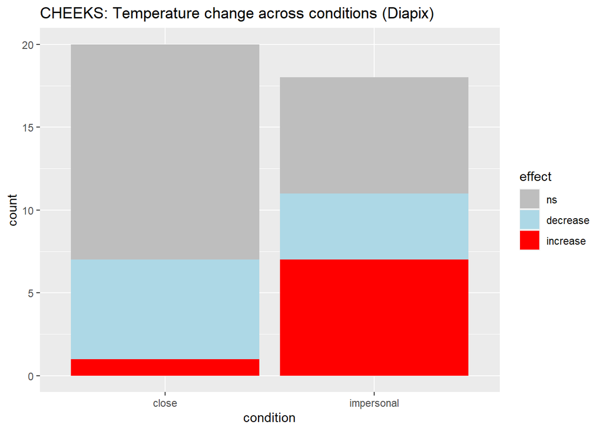

```r
ggplot(d |> filter(ROI=="Cheeks"), aes(condition, fill=effect))+
  geom_bar()+
  ggtitle("CHEEKS: Temperature change across conditions (Diapix)")+
  scale_fill_manual(values = c("decrease" = "lightblue", "increase" = "red", "ns" = "gray"))
```

Cheek temperature tended to *increase more often* in the *impersonal* condition, but the adjusted p value was slightly above 0.05 (i.e., 0.053).

```r
tidy(m <- nnet::multinom(effect ~ condition, data=d |> filter(ROI=="Cheeks"))) |>
  as_tibble() |>
  mutate(estimate = plogis(estimate)) # plogis transforms log odds (the output of the model) into probabilities
```

```
## # A tibble: 4 × 6
##   y.level  term                estimate std.error statistic p.value
##   <chr>    <chr>                  <dbl>     <dbl>     <dbl>   <dbl>
## 1 decrease (Intercept)           0.316      0.494    -1.57   0.117
## 2 decrease conditionimpersonal   0.553      0.798     0.268  0.789
## 3 increase (Intercept)           0.0714     1.04     -2.47   0.0134
## 4 increase conditionimpersonal   0.929      1.17      2.20   0.0280
```

```r
emmeans(m, pairwise~condition, by="effect")
```

```
## $emmeans
## effect = ns:
##  condition   prob     SE df lower.CL upper.CL
##  close      0.650 0.1067  4   0.3539    0.946
##  impersonal 0.389 0.1149  4   0.0699    0.708
##
## effect = decrease:
##  condition   prob     SE df lower.CL upper.CL
##  close      0.300 0.1025  4   0.0155    0.585
##  impersonal 0.222 0.0980  4  -0.0498    0.494
##
## effect = increase:
##  condition   prob     SE df lower.CL upper.CL
##  close      0.050 0.0487  4  -0.0853    0.185
##  impersonal 0.389 0.1149  4   0.0699    0.708
##
## Confidence level used: 0.95
##
## $contrasts
## effect = ns:
##  contrast           estimate    SE df t.ratio p.value
##  close - impersonal   0.2611 0.157  4   1.666  0.1711
##
## effect = decrease:
##  contrast           estimate    SE df t.ratio p.value
##  close - impersonal   0.0778 0.142  4   0.549  0.6125
##
## effect = increase:
##  contrast           estimate    SE df t.ratio p.value
##  close - impersonal  -0.3389 0.125  4  -2.715  0.0532
```

```r
summary(m <- glmer(sign ~ condition + (1|speaker), d |> filter(ROI=="Cheeks"), family=binomial))
```

```
## boundary (singular) fit: see help('isSingular')
```

```
## Generalized linear mixed model fit by maximum likelihood (Laplace
##   Approximation) [glmerMod]
##  Family: binomial  ( logit )
## Formula: sign ~ condition + (1 | speaker)
##    Data: filter(d, ROI == "Cheeks")
##
##      AIC      BIC   logLik deviance df.resid
##     56.0     60.9    -25.0     50.0       35
##
## Scaled residuals:
##     Min      1Q  Median      3Q     Max
## -1.2536 -0.7338 -0.7338  0.7977  1.3628
##
## Random effects:
##  Groups  Name        Variance  Std.Dev.
##  speaker (Intercept) 6.261e-09 7.913e-05
## Number of obs: 38, groups:  speaker, 38
##
## Fixed effects:
##                     Estimate Std. Error z value Pr(>|z|)
## (Intercept)          -0.6190     0.4692  -1.319    0.187
## conditionimpersonal   1.0710     0.6743   1.588    0.112
##
## Correlation of Fixed Effects:
##             (Intr)
## cndtnmprsnl -0.697
## optimizer (Nelder_Mead) convergence code: 0 (OK)
## boundary (singular) fit: see help('isSingular')
```

No effect of the perception of their partner.

```r
tidy(m <- nnet::multinom(effect ~ becomeFriends, data=d |> filter(ROI=="Cheeks"))) |>
  as_tibble() |>
  mutate(estimate = plogis(estimate)) # plogis transforms log odds (the output of the model) into probabilities
```

```
## # A tibble: 4 × 6
##   y.level  term          estimate std.error statistic p.value
##   <chr>    <chr>            <dbl>     <dbl>     <dbl>   <dbl>
## 1 decrease (Intercept)      0.450     1.37     -0.146   0.884
## 2 decrease becomeFriends    0.479     0.223    -0.373   0.709
## 3 increase (Intercept)      0.362     1.49     -0.379   0.705
## 4 increase becomeFriends    0.485     0.242    -0.244   0.808
```

```r
tidy(m <- nnet::multinom(effect ~ closeness, data=d |> filter(ROI=="Cheeks"))) |>
  as_tibble() |>
  mutate(estimate = plogis(estimate)) # plogis transforms log odds (the output of the model) into probabilities
```

```
## # A tibble: 4 × 6
##   y.level  term        estimate std.error statistic p.value
##   <chr>    <chr>          <dbl>     <dbl>     <dbl>   <dbl>
## 1 decrease (Intercept)    0.454     0.891    -0.205   0.837
## 2 decrease closeness      0.467     0.214    -0.623   0.533
## 3 increase (Intercept)    0.599     0.936     0.428   0.669
## 4 increase closeness      0.405     0.262    -1.46    0.143
```

```r
tidy(m <- nnet::multinom(effect ~ similarity, data=d |> filter(ROI=="Cheeks"))) |>
  as_tibble() |>
  mutate(estimate = plogis(estimate)) # plogis transforms log odds (the output of the model) into probabilities
```

```
## # A tibble: 4 × 6
##   y.level  term        estimate std.error statistic p.value
##   <chr>    <chr>          <dbl>     <dbl>     <dbl>   <dbl>
## 1 decrease (Intercept)    0.785     1.38      0.936  0.349
## 2 decrease similarity     0.414     0.237    -1.47   0.143
## 3 increase (Intercept)    0.865     1.47      1.27   0.205
## 4 increase similarity     0.376     0.268    -1.89   0.0591
```

```r
tidy(m <- nnet::multinom(effect ~ likeability, data=d |> filter(ROI=="Cheeks"))) |>
  as_tibble() |>
  mutate(estimate = plogis(estimate)) # plogis transforms log odds (the output of the model) into probabilities
```

```
## # A tibble: 4 × 6
##   y.level  term        estimate std.error statistic p.value
##   <chr>    <chr>          <dbl>     <dbl>     <dbl>   <dbl>
## 1 decrease (Intercept)   0.0736     2.23     -1.14    0.256
## 2 decrease likeability   0.564      0.302     0.848   0.396
## 3 increase (Intercept)   0.898      2.02      1.08    0.280
## 4 increase likeability   0.383      0.313    -1.53    0.127
```

Cheek temperature *increased* less often when the speaker scored higher in agreeableness.

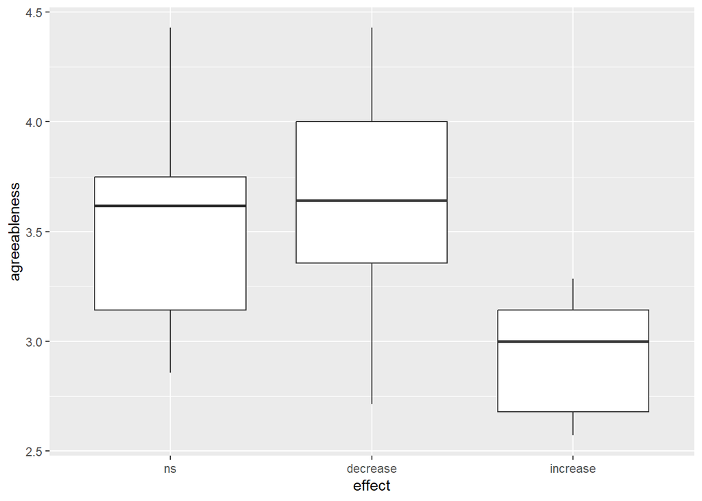

```r
ggplot(d |> filter(ROI=="Cheeks"), aes(effect, agreeableness))+
  geom_boxplot()
```

```r
tidy(m <- nnet::multinom(effect ~ agreeableness, data=d |> filter(ROI=="Cheeks"))) |>
  as_tibble() |>
  mutate(estimate = plogis(estimate)) # plogis transforms log odds (the output of the model) into probabilities
```

```
## # A tibble: 4 × 6
##   y.level  term          estimate std.error statistic p.value
##   <chr>    <chr>            <dbl>     <dbl>     <dbl>   <dbl>
## 1 decrease (Intercept)     0.0971     3.13     -0.712  0.476
## 2 decrease agreeableness   0.605      0.856     0.496  0.620
## 3 increase (Intercept)     1.00       5.23      2.46   0.0140
## 4 increase agreeableness   0.0134     1.69     -2.54   0.0110
```

```r
tidy(m <- nnet::multinom(effect ~ extraversion, data=d |> filter(ROI=="Cheeks"))) |>
  as_tibble() |>
  mutate(estimate = plogis(estimate)) # plogis transforms log odds (the output of the model) into probabilities
```

```
## # A tibble: 4 × 6
##   y.level  term         estimate std.error statistic p.value
##   <chr>    <chr>           <dbl>     <dbl>     <dbl>   <dbl>
## 1 decrease (Intercept)   0.00887     2.71      -1.74  0.0819
## 2 decrease extraversion  0.752       0.729      1.52  0.128
## 3 increase (Intercept)   0.984       2.99       1.39  0.165
## 4 increase extraversion  0.173       0.939     -1.67  0.0957
```

```r
tidy(m <- nnet::multinom(effect ~ openness, data=d |> filter(ROI=="Cheeks"))) |>
  as_tibble() |>
  mutate(estimate = plogis(estimate)) # plogis transforms log odds (the output of the model) into probabilities
```

```
## # A tibble: 4 × 6
##   y.level  term        estimate std.error statistic p.value
##   <chr>    <chr>          <dbl>     <dbl>     <dbl>   <dbl>
## 1 decrease (Intercept)   0.0315     2.05     -1.67   0.0948
## 2 decrease openness      0.677      0.534     1.39   0.165
## 3 increase (Intercept)   0.581      1.82      0.180  0.857
## 4 increase openness      0.408      0.536    -0.694  0.488
```

```r
tidy(m <- nnet::multinom(effect ~ conscientiousness, data=d |> filter(ROI=="Cheeks"))) |>
  as_tibble() |>
  mutate(estimate = plogis(estimate)) # plogis transforms log odds (the output of the model) into probabilities
```

```
## # A tibble: 4 × 6
##   y.level  term              estimate std.error statistic p.value
##   <chr>    <chr>                <dbl>     <dbl>     <dbl>   <dbl>
## 1 decrease (Intercept)        0.00222     3.62     -1.69   0.0918
## 2 decrease conscientiousness  0.789       0.861     1.53   0.126
## 3 increase (Intercept)        0.207       2.91     -0.462  0.644
## 4 increase conscientiousness  0.527       0.728     0.148  0.882
```

```r
tidy(m <- nnet::multinom(effect ~ neuroticism, data=d |> filter(ROI=="Cheeks"))) |>
  as_tibble() |>
  mutate(estimate = plogis(estimate)) # plogis transforms log odds (the output of the model) into probabilities
```

```
## # A tibble: 4 × 6
##   y.level  term        estimate std.error statistic p.value
##   <chr>    <chr>          <dbl>     <dbl>     <dbl>   <dbl>
## 1 decrease (Intercept)    0.277     1.75    -0.549    0.583
## 2 decrease neuroticism    0.521     0.537    0.157    0.876
## 3 increase (Intercept)    0.290     1.87    -0.480    0.631
## 4 increase neuroticism    0.499     0.580   -0.0102   0.992
```

No effect of thermal comfort

```r
tidy(m <- nnet::multinom(effect ~ comfortPre, data=d |> filter(ROI=="Cheeks"))) |>
  as_tibble() |>
  mutate(estimate = plogis(estimate)) # plogis transforms log odds (the output of the model) into probabilities
```

```
## # A tibble: 4 × 6
##   y.level  term        estimate std.error statistic p.value
##   <chr>    <chr>          <dbl>     <dbl>     <dbl>   <dbl>
## 1 decrease (Intercept)    0.751     2.21      0.500   0.617
## 2 decrease comfortPre     0.426     0.362    -0.818   0.413
## 3 increase (Intercept)    0.593     2.39      0.157   0.875
## 4 increase comfortPre     0.447     0.387    -0.545   0.586
```

```r
tidy(m <- nnet::multinom(effect ~ comfortPost, data=d |> filter(ROI=="Cheeks"))) |>
  as_tibble() |>
  mutate(estimate = plogis(estimate)) # plogis transforms log odds (the output of the model) into probabilities
```

```
## # A tibble: 4 × 6
##   y.level  term        estimate std.error statistic p.value
##   <chr>    <chr>          <dbl>     <dbl>     <dbl>   <dbl>
## 1 decrease (Intercept)    0.279     2.18     -0.435   0.663
## 2 decrease comfortPost    0.511     0.359     0.119   0.905
## 3 increase (Intercept)    0.371     2.36     -0.223   0.823
## 4 increase comfortPost    0.484     0.393    -0.168   0.867
```

#### Entire experiment

```r
d <- merge(all |>
             filter(section == "entireExp") |>
             select(-condition) |>
             mutate_at(c("sign", "effect"), as.factor),
           meta, by="speaker") |>
  mutate_at("condition", as.factor)
```

```r
# data set for poisson regression

dt <- d |>
  group_by(effect, condition, ROI) |>
  summarize(count = n()) |>
  right_join(crossing(effect = unique(d$effect), condition = unique(d$condition), ROI = unique(d$ROI))) |>
  mutate(count = replace_na(count, 0))
conditionCount <- d |>
  group_by(condition, ROI) |>
  summarize(condCount = n())
dt <- merge(dt, conditionCount, by=c("condition", "ROI"))

dt$effect <- relevel(dt$effect, ref="ns")
contrasts(dt$condition) <- c(-.5,+.5)
```

##### All ROIs together

- With all ROIs taken together, there were overall more changes in the impersonal condition, both increases and decreases.

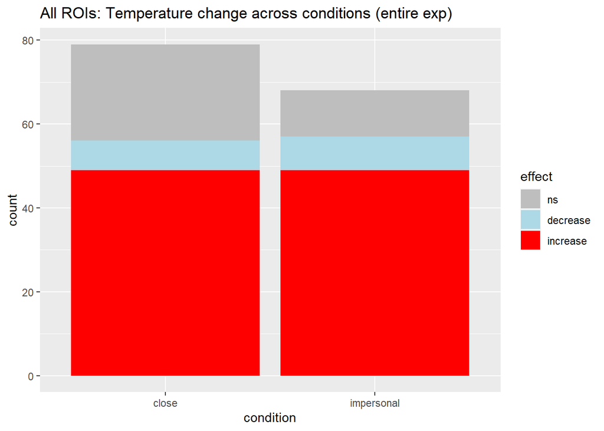

```r
ggplot(d, aes(condition, fill=effect))+
  geom_bar()+
  # facet_wrap(~condition)+
  ggtitle("All ROIs: Temperature change across conditions (entire exp)")+
  scale_fill_manual(values = c("decrease" = "lightblue", "increase" = "red", "ns" = "gray"))
```

No significant effect of condition, but almost

```r
tidy(m <- nnet::multinom(effect ~ condition, data=d)) |>
  as_tibble() |>
  mutate(estimate = plogis(estimate)) # plogis transforms log odds (the output of the model) into probabilities
```

```
## # A tibble: 4 × 6
##   y.level  term                estimate std.error statistic p.value
##   <chr>    <chr>                  <dbl>     <dbl>     <dbl>   <dbl>
## 1 decrease (Intercept)            0.233     0.432     -2.76 0.00586
## 2 decrease conditionimpersonal    0.705     0.634      1.37 0.170
## 3 increase (Intercept)            0.681     0.253      2.99 0.00277
## 4 increase conditionimpersonal    0.676     0.419      1.76 0.0780
```

```r
emmeans(m, pairwise~condition, by="effect")
```

```
## $emmeans
## effect = ns:
##  condition    prob     SE df  lower.CL upper.CL
##  close      0.2911 0.0511  4  0.149228    0.433
##  impersonal 0.1618 0.0447  4  0.037782    0.286
##
## effect = decrease:
##  condition    prob     SE df  lower.CL upper.CL
##  close      0.0886 0.0320  4 -0.000145    0.177
##  impersonal 0.1176 0.0391  4  0.009168    0.226
##
## effect = increase:
##  condition    prob     SE df  lower.CL upper.CL
##  close      0.6202 0.0546  4  0.468621    0.772
##  impersonal 0.7206 0.0544  4  0.569512    0.872
##
## Confidence level used: 0.95
##
## $contrasts
## effect = ns:
##  contrast           estimate     SE df t.ratio p.value
##  close - impersonal    0.129 0.0679  4   1.906  0.1293
##
## effect = decrease:
##  contrast           estimate     SE df t.ratio p.value
##  close - impersonal   -0.029 0.0505  4  -0.575  0.5964
##
## effect = increase:
##  contrast           estimate     SE df t.ratio p.value
##  close - impersonal   -0.100 0.0771  4  -1.302  0.2628
```

```r
summary(m <- glmer(sign ~ condition + (1|speaker), d, family=binomial))
```

```
## boundary (singular) fit: see help('isSingular')
```

```
## Generalized linear mixed model fit by maximum likelihood (Laplace
##   Approximation) [glmerMod]
##  Family: binomial  ( logit )
## Formula: sign ~ condition + (1 | speaker)
##    Data: d
##
##      AIC      BIC   logLik deviance df.resid
##    161.5    170.5    -77.7    155.5      144
##
## Scaled residuals:
##     Min      1Q  Median      3Q     Max
## -2.2764  0.4393  0.4393  0.6409  0.6409
##
## Random effects:
##  Groups  Name        Variance  Std.Dev.
##  speaker (Intercept) 4.159e-20 2.039e-10
## Number of obs: 147, groups:  speaker, 38
##
## Fixed effects:
##                     Estimate Std. Error z value Pr(>|z|)
## (Intercept)           0.8899     0.2477   3.593 0.000327 ***
## conditionimpersonal   0.7553     0.4121   1.833 0.066800 .
## ---
## Signif. codes:  0 '***' 0.001 '**' 0.01 '*' 0.05 '.' 0.1 ' ' 1
##
## Correlation of Fixed Effects:
##             (Intr)
## cndtnmprsnl -0.601
## optimizer (Nelder_Mead) convergence code: 0 (OK)
## boundary (singular) fit: see help('isSingular')
```

##### Nose

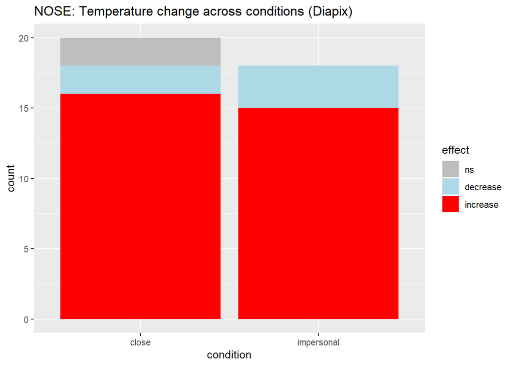

```r
ggplot(d |> filter(ROI=="Nose"), aes(condition, fill=effect))+
  geom_bar()+
  ggtitle("NOSE: Temperature change across conditions (Diapix)")+
  scale_fill_manual(values = c("decrease" = "lightblue", "increase" = "red", "ns" = "gray"))
```

No effect of condition

```r
tidy(m <- nnet::multinom(effect ~ condition, data=d |> filter(ROI=="Nose"))) |>
  as_tibble() |>
  mutate(estimate = plogis(estimate)) # plogis transforms log odds (the output of the model) into probabilities
```

```
## # A tibble: 4 × 6
##   y.level  term                estimate std.error statistic p.value
##   <chr>    <chr>                  <dbl>     <dbl>     <dbl>   <dbl>
## 1 decrease (Intercept)            0.500     1.00   0.000328 1.00
## 2 decrease conditionimpersonal    1.00     44.2    0.196    0.844
## 3 increase (Intercept)            0.889     0.750  2.77     0.00556
## 4 increase conditionimpersonal    1.00     44.2    0.186    0.853
```

```r
emmeans(m, pairwise~condition, by="effect")
```

```
## $emmeans
## effect = ns:
##  condition      prob      SE df lower.CL upper.CL
##  close      1.00e-01 0.06708  4 -0.08625  0.28621
##  impersonal 2.85e-05 0.00126  4 -0.00346  0.00352
##
## effect = decrease:
##  condition      prob      SE df lower.CL upper.CL
##  close      1.00e-01 0.06709  4 -0.08625  0.28627
##  impersonal 1.67e-01 0.08783  4 -0.07723  0.41050
##
## effect = increase:
##  condition      prob      SE df lower.CL upper.CL
##  close      8.00e-01 0.08944  4  0.55168  1.04834
##  impersonal 8.33e-01 0.08784  4  0.58945  1.07722
##
## Confidence level used: 0.95
##
## $contrasts
## effect = ns:
##  contrast           estimate     SE df t.ratio p.value
##  close - impersonal   0.1000 0.0671  4   1.490  0.2105
##
## effect = decrease:
##  contrast           estimate     SE df t.ratio p.value
##  close - impersonal  -0.0666 0.1105  4  -0.603  0.5792
##
## effect = increase:
##  contrast           estimate     SE df t.ratio p.value
##  close - impersonal  -0.0333 0.1254  4  -0.266  0.8035
```

```r
summary(glm(sign ~ condition, d |> filter(ROI=="Nose"), family=binomial)) # not converging with the random intercepts
```

```
##
## Call:
## glm(formula = sign ~ condition, family = binomial, data = filter(d,
##     ROI == "Nose"))
##
## Deviance Residuals:
##      Min        1Q    Median        3Q       Max
## -2.14597   0.00005   0.00005   0.45904   0.45904
##
## Coefficients:
##                      Estimate Std. Error z value Pr(>|z|)
## (Intercept)            2.1972     0.7454   2.948   0.0032 **
## conditionimpersonal   18.3688  4179.0883   0.004   0.9965
## ---
## Signif. codes:  0 '***' 0.001 '**' 0.01 '*' 0.05 '.' 0.1 ' ' 1
##
## (Dispersion parameter for binomial family taken to be 1)
##
##     Null deviance: 15.671  on 37  degrees of freedom
## Residual deviance: 13.003  on 36  degrees of freedom
## AIC: 17.003
##
## Number of Fisher Scoring iterations: 19
```

No effect of perception of partner.

```r
tidy(m <- nnet::multinom(effect ~ becomeFriends, data=d |> filter(ROI=="Nose"))) |>
  as_tibble() |>
  mutate(estimate = plogis(estimate)) # plogis transforms log odds (the output of the model) into probabilities
```

```
## # A tibble: 4 × 6
##   y.level  term          estimate std.error statistic p.value
##   <chr>    <chr>            <dbl>     <dbl>     <dbl>   <dbl>
## 1 decrease (Intercept)      0.395     2.38   -0.178     0.858
## 2 decrease becomeFriends    0.567     0.468   0.579     0.562
## 3 increase (Intercept)      0.502     2.08    0.00349   0.997
## 4 increase becomeFriends    0.625     0.418   1.22      0.221
```

```r
tidy(m <- nnet::multinom(effect ~ closeness, data=d |> filter(ROI=="Nose"))) |>
  as_tibble() |>
  mutate(estimate = plogis(estimate)) # plogis transforms log odds (the output of the model) into probabilities
```

```
## # A tibble: 4 × 6
##   y.level  term        estimate std.error statistic p.value
##   <chr>    <chr>          <dbl>     <dbl>     <dbl>   <dbl>
## 1 decrease (Intercept)    0.668     1.74      0.402   0.688
## 2 decrease closeness      0.517     0.500     0.140   0.889
## 3 increase (Intercept)    0.866     1.53      1.22    0.221
## 4 increase closeness      0.564     0.440     0.586   0.558
```

```r
tidy(m <- nnet::multinom(effect ~ similarity, data=d |> filter(ROI=="Nose"))) |>
  as_tibble() |>
  mutate(estimate = plogis(estimate)) # plogis transforms log odds (the output of the model) into probabilities
```

```
## # A tibble: 4 × 6
##   y.level  term        estimate std.error statistic p.value
##   <chr>    <chr>          <dbl>     <dbl>     <dbl>   <dbl>
## 1 decrease (Intercept)   0.0606     2.82     -0.971   0.331
## 2 decrease similarity    0.700      0.693     1.22    0.222
## 3 increase (Intercept)   0.157      2.53     -0.666   0.506
## 4 increase similarity    0.728      0.657     1.50    0.135
```

```r
tidy(m <- nnet::multinom(effect ~ likeability, data=d |> filter(ROI=="Nose"))) |>
  as_tibble() |>
  mutate(estimate = plogis(estimate)) # plogis transforms log odds (the output of the model) into probabilities
```

```
## # A tibble: 4 × 6
##   y.level  term        estimate std.error statistic p.value
##   <chr>    <chr>          <dbl>     <dbl>     <dbl>   <dbl>
## 1 decrease (Intercept)    0.191     4.04     -0.358   0.721
## 2 decrease likeability    0.585     0.587     0.586   0.558
## 3 increase (Intercept)    0.842     3.34      0.500   0.617
## 4 increase likeability    0.540     0.500     0.321   0.748
```

No effect of BFI scores

```r
tidy(m <- nnet::multinom(effect ~ extraversion, data=d |> filter(ROI=="Nose"))) |>
  as_tibble() |>
  mutate(estimate = plogis(estimate)) # plogis transforms log odds (the output of the model) into probabilities
```

```
## # A tibble: 4 × 6
##   y.level  term         estimate std.error statistic p.value
##   <chr>    <chr>           <dbl>     <dbl>     <dbl>   <dbl>
## 1 decrease (Intercept)    0.0745      5.38    -0.468   0.640
## 2 decrease extraversion   0.716       1.45     0.636   0.525
## 3 increase (Intercept)    0.990       4.49     1.02    0.306
## 4 increase extraversion   0.369       1.25    -0.429   0.668
```

```r
tidy(m <- nnet::multinom(effect ~ openness, data=d |> filter(ROI=="Nose"))) |>
  as_tibble() |>
  mutate(estimate = plogis(estimate)) # plogis transforms log odds (the output of the model) into probabilities
```

```
## # A tibble: 4 × 6
##   y.level  term        estimate std.error statistic p.value
##   <chr>    <chr>          <dbl>     <dbl>     <dbl>   <dbl>
## 1 decrease (Intercept)   0.0196      3.73    -1.05    0.294
## 2 decrease openness      0.814       1.17     1.26    0.208
## 3 increase (Intercept)   0.277       3.08    -0.312   0.755
## 4 increase openness      0.762       1.04     1.13    0.260
```

```r
tidy(m <- nnet::multinom(effect ~ agreeableness, data=d |> filter(ROI=="Nose"))) |>
  as_tibble() |>
  mutate(estimate = plogis(estimate)) # plogis transforms log odds (the output of the model) into probabilities
```

```
## # A tibble: 4 × 6
##   y.level  term          estimate std.error statistic p.value
##   <chr>    <chr>            <dbl>     <dbl>     <dbl>   <dbl>
## 1 decrease (Intercept)      0.995      6.78     0.792   0.429
## 2 decrease agreeableness    0.232      1.78    -0.673   0.501
## 3 increase (Intercept)      1.00       6.17     1.52    0.128
## 4 increase agreeableness    0.139      1.60    -1.14    0.254
```

```r
tidy(m <- nnet::multinom(effect ~ conscientiousness, data=d |> filter(ROI=="Nose"))) |>
  as_tibble() |>
  mutate(estimate = plogis(estimate)) # plogis transforms log odds (the output of the model) into probabilities
```

```
## # A tibble: 4 × 6
##   y.level  term              estimate std.error statistic p.value
##   <chr>    <chr>                <dbl>     <dbl>     <dbl>   <dbl>
## 1 decrease (Intercept)          0.369      6.82   -0.0786   0.937
## 2 decrease conscientiousness    0.586      1.64    0.214    0.831
## 3 increase (Intercept)          0.988      5.74    0.770    0.441
## 4 increase conscientiousness    0.398      1.39   -0.299    0.765
```

```r
tidy(m <- nnet::multinom(effect ~ neuroticism, data=d |> filter(ROI=="Nose"))) |>
  as_tibble() |>
  mutate(estimate = plogis(estimate)) # plogis transforms log odds (the output of the model) into probabilities
```

```
## # A tibble: 4 × 6
##   y.level  term        estimate std.error statistic p.value
##   <chr>    <chr>          <dbl>     <dbl>     <dbl>   <dbl>
## 1 decrease (Intercept)   0.0517      3.84    -0.758   0.448
## 2 decrease neuroticism   0.769       1.22     0.986   0.324
## 3 increase (Intercept)   0.782       3.10     0.413   0.680
## 4 increase neuroticism   0.620       1.04     0.469   0.639
```

No effect of thermal comfort

```r
tidy(m <- nnet::multinom(effect ~ comfortPre, data=d |> filter(ROI=="Nose"))) |>
  as_tibble() |>
  mutate(estimate = plogis(estimate)) # plogis transforms log odds (the output of the model) into probabilities
```

```
## # A tibble: 4 × 6
##   y.level  term        estimate std.error statistic p.value
##   <chr>    <chr>          <dbl>     <dbl>     <dbl>   <dbl>
## 1 decrease (Intercept)    0.996     5.02      1.12    0.264
## 2 decrease comfortPre     0.301     0.867    -0.971   0.332
## 3 increase (Intercept)    0.793     4.24      0.317   0.751
## 4 increase comfortPre     0.557     0.694     0.329   0.742
```

```r
tidy(m <- nnet::multinom(effect ~ comfortPost, data=d |> filter(ROI=="Nose"))) |>
  as_tibble() |>
  mutate(estimate = plogis(estimate)) # plogis transforms log odds (the output of the model) into probabilities
```

```
## # A tibble: 4 × 6
##   y.level  term        estimate std.error statistic p.value
##   <chr>    <chr>          <dbl>     <dbl>     <dbl>   <dbl>
## 1 decrease (Intercept)    0.827     5.01     0.312    0.755
## 2 decrease comfortPost    0.470     0.904   -0.132    0.895
## 3 increase (Intercept)    0.393     4.38    -0.0993   0.921
## 4 increase comfortPost    0.634     0.781    0.705    0.481
```

##### Eyes

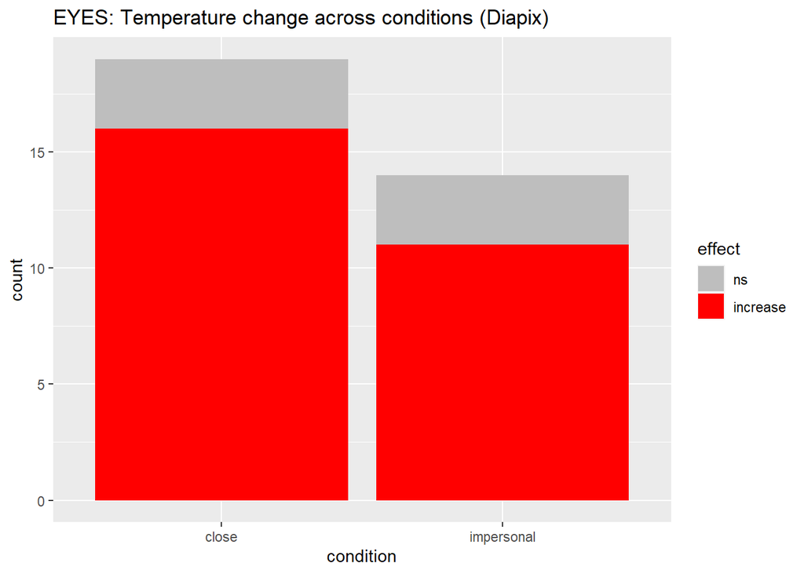

```r
ggplot(d |> filter(ROI=="Eyes"), aes(condition, fill=effect))+
  geom_bar()+
  ggtitle("EYES: Temperature change across conditions (Diapix)")+
  scale_fill_manual(values = c("decrease" = "lightblue", "increase" = "red", "ns" = "gray"))
```

No effect of condition

```r
tidy(m <- nnet::multinom(effect ~ condition, data=d |> filter(ROI=="Eyes"))) |>
  as_tibble() |>
  mutate(estimate = plogis(estimate)) # plogis transforms log odds (the output of the model) into probabilities
```

```
## # A tibble: 2 × 6
##   y.level term                estimate std.error statistic p.value
##   <chr>   <chr>                  <dbl>     <dbl>     <dbl>   <dbl>
## 1 1       (Intercept)            0.842     0.629     2.66  0.00780
## 2 1       conditionimpersonal    0.407     0.906    -0.414 0.679
```

```r
emmeans(m, pairwise~condition, by="effect")
```

```
## $emmeans
## effect = ns:
##  condition   prob     SE df lower.CL upper.CL
##  close      0.158 0.0837  2   -0.202    0.518
##  impersonal 0.214 0.1097  2   -0.258    0.686
##
## effect = increase:
##  condition   prob     SE df lower.CL upper.CL
##  close      0.842 0.0837  2    0.482    1.202
##  impersonal 0.786 0.1097  2    0.314    1.258
##
## Confidence level used: 0.95
##
## $contrasts
## effect = ns:
##  contrast           estimate    SE df t.ratio p.value
##  close - impersonal  -0.0564 0.138  2  -0.409  0.7223
##
## effect = increase:
##  contrast           estimate    SE df t.ratio p.value
##  close - impersonal   0.0564 0.138  2   0.409  0.7223
```

```r
summary(glmer(sign ~ condition + (1|speaker), d |> filter(ROI=="Eyes"), family=binomial))
```

```
## Generalized linear mixed model fit by maximum likelihood (Laplace
##   Approximation) [glmerMod]
##  Family: binomial  ( logit )
## Formula: sign ~ condition + (1 | speaker)
##    Data: filter(d, ROI == "Eyes")
##
##      AIC      BIC   logLik deviance df.resid
##     37.1     41.6    -15.6     31.1       30
##
## Scaled residuals:
##     Min      1Q  Median      3Q     Max
## -2.3094  0.4330  0.4330  0.5222  0.5222
##
## Random effects:
##  Groups  Name        Variance  Std.Dev.
##  speaker (Intercept) 1.695e-08 0.0001302
## Number of obs: 33, groups:  speaker, 33
##
## Fixed effects:
##                     Estimate Std. Error z value Pr(>|z|)
## (Intercept)           1.6740     0.6337   2.642  0.00825 **
## conditionimpersonal  -0.3747     0.9057  -0.414  0.67908
## ---
## Signif. codes:  0 '***' 0.001 '**' 0.01 '*' 0.05 '.' 0.1 ' ' 1
##
## Correlation of Fixed Effects:
##             (Intr)
## cndtnmprsnl -0.691
## optimizer (Nelder_Mead) convergence code: 0 (OK)
## Model is nearly unidentifiable: large eigenvalue ratio
##  - Rescale variables?
```

No effect of perception of partner.

```r
# there's a warning about the `decrease` level being empty, but I already checked with a dataset where I `droplevel()`'d `effect` and it didn't affect the model

tidy(m <- nnet::multinom(effect ~ closeness, data=d |> filter(ROI=="Eyes"))) |>
  as_tibble() |>
  mutate(estimate = plogis(estimate)) # plogis transforms log odds (the output of the model) into probabilities
```

```
## # A tibble: 2 × 6
##   y.level term        estimate std.error statistic p.value
##   <chr>   <chr>          <dbl>     <dbl>     <dbl>   <dbl>
## 1 1       (Intercept)    0.829     0.986    1.60     0.109
## 2 1       closeness      0.495     0.240   -0.0876   0.930
```

```r
tidy(m <- nnet::multinom(effect ~ becomeFriends, data=d |> filter(ROI=="Eyes"))) |>
  as_tibble() |>
  mutate(estimate = plogis(estimate)) # plogis transforms log odds (the output of the model) into probabilities
```

```
## # A tibble: 2 × 6
##   y.level term          estimate std.error statistic p.value
##   <chr>   <chr>            <dbl>     <dbl>     <dbl>   <dbl>
## 1 1       (Intercept)      0.975     2.29      1.59    0.111
## 2 1       becomeFriends    0.416     0.343    -0.993   0.321
```

```r
tidy(m <- nnet::multinom(effect ~ similarity, data=d |> filter(ROI=="Eyes"))) |>
  as_tibble() |>
  mutate(estimate = plogis(estimate)) # plogis transforms log odds (the output of the model) into probabilities
```

```
## # A tibble: 2 × 6
##   y.level term        estimate std.error statistic p.value
##   <chr>   <chr>          <dbl>     <dbl>     <dbl>   <dbl>
## 1 1       (Intercept)    0.946     1.72      1.66   0.0965
## 2 1       similarity     0.443     0.267    -0.850  0.396
```

```r
tidy(m <- nnet::multinom(effect ~ likeability, data=d |> filter(ROI=="Eyes"))) |>
  as_tibble() |>
  mutate(estimate = plogis(estimate)) # plogis transforms log odds (the output of the model) into probabilities
```

```
## # A tibble: 2 × 6
##   y.level term        estimate std.error statistic p.value
##   <chr>   <chr>          <dbl>     <dbl>     <dbl>   <dbl>
## 1 1       (Intercept)    0.988     2.75       1.61   0.108
## 2 1       likeability    0.399     0.368     -1.11   0.266
```

Eye temperature seemed to *increase less often* when the speaker scored higher on neuroticism.

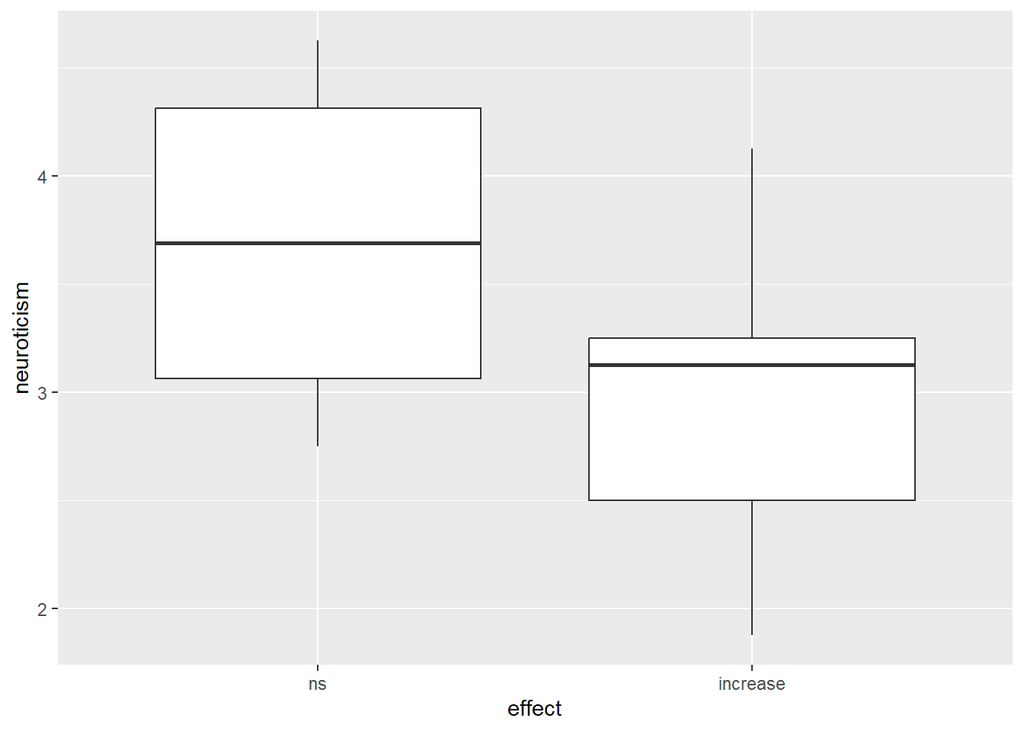

```r
ggplot(d |> filter(ROI=="Eyes"), aes(effect, neuroticism))+
  geom_boxplot()
```

```r
tidy(m <- nnet::multinom(effect ~ neuroticism, data=d |> filter(ROI=="Eyes"))) |>
  as_tibble() |>
  mutate(estimate = plogis(estimate)) # plogis transforms log odds (the output of the model) into probabilities
```

```
## # A tibble: 2 × 6
##   y.level term        estimate std.error statistic p.value
##   <chr>   <chr>          <dbl>     <dbl>     <dbl>   <dbl>
## 1 1       (Intercept)    1.00      3.05       2.52  0.0119
## 2 1       neuroticism    0.135     0.867     -2.15  0.0318
```

```r
tidy(m <- nnet::multinom(effect ~ agreeableness, data=d |> filter(ROI=="Eyes"))) |>
  as_tibble() |>
  mutate(estimate = plogis(estimate)) # plogis transforms log odds (the output of the model) into probabilities
```

```
## # A tibble: 2 × 6
##   y.level term          estimate std.error statistic p.value
##   <chr>   <chr>            <dbl>     <dbl>     <dbl>   <dbl>
## 1 1       (Intercept)      0.983     3.33      1.22    0.223
## 2 1       agreeableness    0.325     0.927    -0.788   0.431
```

```r
tidy(m <- nnet::multinom(effect ~ extraversion, data=d |> filter(ROI=="Eyes"))) |>
  as_tibble() |>
  mutate(estimate = plogis(estimate)) # plogis transforms log odds (the output of the model) into probabilities
```

```
## # A tibble: 2 × 6
##   y.level term         estimate std.error statistic p.value
##   <chr>   <chr>           <dbl>     <dbl>     <dbl>   <dbl>
## 1 1       (Intercept)     0.537     2.55     0.0587   0.953
## 2 1       extraversion    0.597     0.743    0.531    0.595
```

```r
tidy(m <- nnet::multinom(effect ~ openness, data=d |> filter(ROI=="Eyes"))) |>
  as_tibble() |>
  mutate(estimate = plogis(estimate)) # plogis transforms log odds (the output of the model) into probabilities
```

```
## # A tibble: 2 × 6
##   y.level term        estimate std.error statistic p.value
##   <chr>   <chr>          <dbl>     <dbl>     <dbl>   <dbl>
## 1 1       (Intercept)    0.658     1.88      0.348   0.728
## 2 1       openness       0.562     0.544     0.456   0.648
```

```r
tidy(m <- nnet::multinom(effect ~ conscientiousness, data=d |> filter(ROI=="Eyes"))) |>
  as_tibble() |>
  mutate(estimate = plogis(estimate)) # plogis transforms log odds (the output of the model) into probabilities
```

```
## # A tibble: 2 × 6
##   y.level term              estimate std.error statistic p.value
##   <chr>   <chr>                <dbl>     <dbl>     <dbl>   <dbl>
## 1 1       (Intercept)          0.485     3.03    -0.0201   0.984
## 2 1       conscientiousness    0.599     0.772    0.517    0.605
```

No effect of thermal comfort

```r
tidy(m <- nnet::multinom(effect ~ comfortPre, data=d |> filter(ROI=="Eyes"))) |>
  as_tibble() |>
  mutate(estimate = plogis(estimate)) # plogis transforms log odds (the output of the model) into probabilities
```

```
## # A tibble: 2 × 6
##   y.level term        estimate std.error statistic p.value
##   <chr>   <chr>          <dbl>     <dbl>     <dbl>   <dbl>
## 1 1       (Intercept)    0.335     2.68     -0.256   0.798
## 2 1       comfortPre     0.590     0.447     0.813   0.416
```

```r
tidy(m <- nnet::multinom(effect ~ comfortPost, data=d |> filter(ROI=="Eyes"))) |>
  as_tibble() |>
  mutate(estimate = plogis(estimate)) # plogis transforms log odds (the output of the model) into probabilities
```

```
## # A tibble: 2 × 6
##   y.level term        estimate std.error statistic p.value
##   <chr>   <chr>          <dbl>     <dbl>     <dbl>   <dbl>
## 1 1       (Intercept)    0.943     2.46      1.14    0.255
## 2 1       comfortPost    0.446     0.395    -0.543   0.587
```

##### Forehead

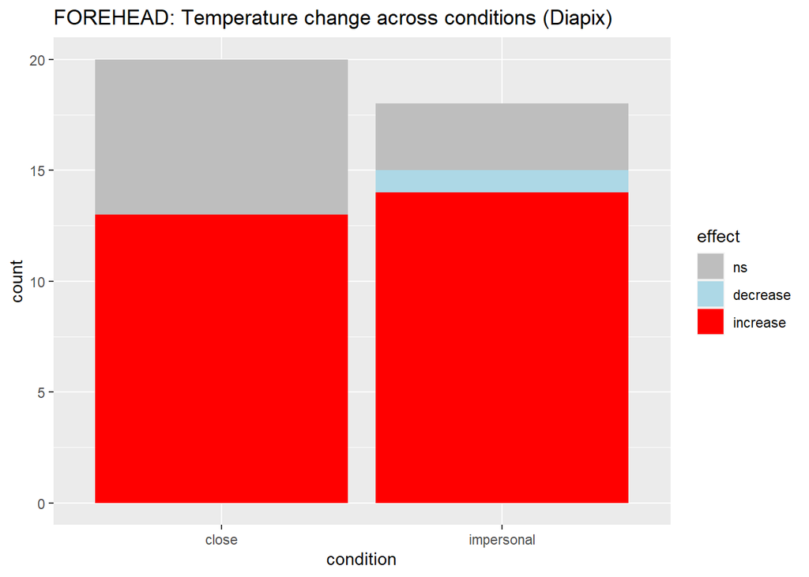

```r
ggplot(d |> filter(ROI=="Forehead"), aes(condition, fill=effect))+
  geom_bar()+
  ggtitle("FOREHEAD: Temperature change across conditions (Diapix)")+
  scale_fill_manual(values = c("decrease" = "lightblue", "increase" = "red", "ns" = "gray"))
```

No effect of condition

```r
tidy(m <- nnet::multinom(effect ~ condition, data=d |> filter(ROI=="Forehead"))) |>
  as_tibble() |>
  mutate(estimate = plogis(estimate)) # plogis transforms log odds (the output of the model) into probabilities
```

```
## # A tibble: 4 × 6
##   y.level  term                 estimate std.error statistic p.value
##   <chr>    <chr>                   <dbl>     <dbl>     <dbl>   <dbl>
## 1 decrease (Intercept)         0.0000804    42.1      -0.224   0.823
## 2 decrease conditionimpersonal 1.00         42.2       0.198   0.843
## 3 increase (Intercept)         0.650         0.469     1.32    0.187
## 4 increase conditionimpersonal 0.715         0.790     1.17    0.244
```

```r
emmeans(m, pairwise~condition, by="effect")
```

```
## $emmeans
## effect = ns:
##  condition      prob      SE df lower.CL upper.CL
##  close      3.50e-01 0.10665  4  0.05387  0.64611
##  impersonal 1.67e-01 0.08785  4 -0.07720  0.41063
##
## effect = decrease:
##  condition      prob      SE df lower.CL upper.CL
##  close      2.82e-05 0.00119  4 -0.00327  0.00332
##  impersonal 5.55e-02 0.05399  4 -0.09434  0.20543
##
## effect = increase:
##  condition      prob      SE df lower.CL upper.CL
##  close      6.50e-01 0.10665  4  0.35386  0.94610
##  impersonal 7.78e-01 0.09800  4  0.50566  1.04982
##
## Confidence level used: 0.95
##
## $contrasts
## effect = ns:
##  contrast           estimate    SE df t.ratio p.value
##  close - impersonal   0.1833 0.138  4   1.326  0.2554
##
## effect = decrease:
##  contrast           estimate    SE df t.ratio p.value
##  close - impersonal  -0.0555 0.054  4  -1.028  0.3620
##
## effect = increase:
##  contrast           estimate    SE df t.ratio p.value
##  close - impersonal  -0.1278 0.145  4  -0.882  0.4276
```

```r
summary(glmer(sign ~ condition + (1|speaker), d |> filter(ROI=="Forehead"), family=binomial))
```

```
## Generalized linear mixed model fit by maximum likelihood (Laplace
##   Approximation) [glmerMod]
##  Family: binomial  ( logit )
## Formula: sign ~ condition + (1 | speaker)
##    Data: filter(d, ROI == "Forehead")
##
##      AIC      BIC   logLik deviance df.resid
##     48.1     53.0    -21.1     42.1       35
##
## Scaled residuals:
##     Min      1Q  Median      3Q     Max
## -2.2361 -0.9103  0.4472  0.7338  0.7338
##
## Random effects:
##  Groups  Name        Variance Std.Dev.
##  speaker (Intercept) 1.62e-08 0.0001273
## Number of obs: 38, groups:  speaker, 38
##
## Fixed effects:
##                     Estimate Std. Error z value Pr(>|z|)
## (Intercept)           0.6190     0.4692   1.319    0.187
## conditionimpersonal   0.9904     0.7876   1.257    0.209
##
## Correlation of Fixed Effects:
##             (Intr)
## cndtnmprsnl -0.593
## optimizer (Nelder_Mead) convergence code: 0 (OK)
## Model is nearly unidentifiable: large eigenvalue ratio
##  - Rescale variables?
```

No effect of the perception of their partner.

```r
tidy(m <- nnet::multinom(effect ~ becomeFriends, data=d |> filter(ROI=="Forehead"))) |>
  as_tibble() |>
  mutate(estimate = plogis(estimate)) # plogis transforms log odds (the output of the model) into probabilities
```

```
## # A tibble: 4 × 6
##   y.level  term          estimate std.error statistic p.value
##   <chr>    <chr>            <dbl>     <dbl>     <dbl>   <dbl>
## 1 decrease (Intercept)   6.15e-21    66.1      -0.704   0.481
## 2 decrease becomeFriends 9.96e- 1     7.37      0.734   0.463
## 3 increase (Intercept)   3.08e- 1     1.28     -0.633   0.527
## 4 increase becomeFriends 5.78e- 1     0.222     1.42    0.155
```

```r
tidy(m <- nnet::multinom(effect ~ closeness, data=d |> filter(ROI=="Forehead"))) |>
  as_tibble() |>
  mutate(estimate = plogis(estimate)) # plogis transforms log odds (the output of the model) into probabilities
```

```
## # A tibble: 4 × 6
##   y.level  term         estimate std.error statistic p.value
##   <chr>    <chr>           <dbl>     <dbl>     <dbl>   <dbl>
## 1 decrease (Intercept) 0.0000539     7.00    -1.40     0.161
## 2 decrease closeness   0.794         1.02     1.31     0.189
## 3 increase (Intercept) 0.731         0.833    1.20     0.229
## 4 increase closeness   0.499         0.207   -0.0115   0.991
```

```r
tidy(m <- nnet::multinom(effect ~ similarity, data=d |> filter(ROI=="Forehead"))) |>
  as_tibble() |>
  mutate(estimate = plogis(estimate)) # plogis transforms log odds (the output of the model) into probabilities
```

```
## # A tibble: 4 × 6
##   y.level  term        estimate std.error statistic p.value
##   <chr>    <chr>          <dbl>     <dbl>     <dbl>   <dbl>
## 1 decrease (Intercept)   0.0757     3.79    -0.660    0.509
## 2 decrease similarity    0.508      0.609    0.0553   0.956
## 3 increase (Intercept)   0.845      1.29     1.32     0.188
## 4 increase similarity    0.469      0.213   -0.581    0.562
```

```r
tidy(m <- nnet::multinom(effect ~ likeability, data=d |> filter(ROI=="Forehead"))) |>
  as_tibble() |>
  mutate(estimate = plogis(estimate)) # plogis transforms log odds (the output of the model) into probabilities
```

```
## # A tibble: 4 × 6
##   y.level  term        estimate std.error statistic p.value
##   <chr>    <chr>          <dbl>     <dbl>     <dbl>   <dbl>
## 1 decrease (Intercept) 1.52e-12    30.0      -0.908  0.364
## 2 decrease likeability 9.50e- 1     3.37      0.874  0.382
## 3 increase (Intercept) 9.75e- 1     2.11      1.74   0.0825
## 4 increase likeability 4.05e- 1     0.291    -1.32   0.185
```

```r
tidy(m <- nnet::multinom(effect ~ extraversion, data=d |> filter(ROI=="Forehead"))) |>
  as_tibble() |>
  mutate(estimate = plogis(estimate)) # plogis transforms log odds (the output of the model) into probabilities
```

```
## # A tibble: 4 × 6
##   y.level  term         estimate std.error statistic p.value
##   <chr>    <chr>           <dbl>     <dbl>     <dbl>   <dbl>
## 1 decrease (Intercept)     0.894     6.51      0.327  0.743
## 2 decrease extraversion    0.225     1.88     -0.659  0.510
## 3 increase (Intercept)     0.997     2.57      2.26   0.0236
## 4 increase extraversion    0.205     0.698    -1.95   0.0515
```

```r
tidy(m <- nnet::multinom(effect ~ openness, data=d |> filter(ROI=="Forehead"))) |>
  as_tibble() |>
  mutate(estimate = plogis(estimate)) # plogis transforms log odds (the output of the model) into probabilities
```

```
## # A tibble: 4 × 6
##   y.level  term        estimate std.error statistic p.value
##   <chr>    <chr>          <dbl>     <dbl>     <dbl>   <dbl>
## 1 decrease (Intercept) 2.01e-12    25.2       -1.07  0.286
## 2 decrease openness    9.96e- 1     5.25       1.04  0.299
## 3 increase (Intercept) 9.63e- 1     1.89       1.72  0.0848
## 4 increase openness    3.47e- 1     0.504     -1.25  0.211
```

```r
tidy(m <- nnet::multinom(effect ~ agreeableness, data=d |> filter(ROI=="Forehead"))) |>
  as_tibble() |>
  mutate(estimate = plogis(estimate)) # plogis transforms log odds (the output of the model) into probabilities
```

```
## # A tibble: 4 × 6
##   y.level  term          estimate std.error statistic p.value
##   <chr>    <chr>            <dbl>     <dbl>     <dbl>   <dbl>
## 1 decrease (Intercept)     1.00      10.2       0.986   0.324
## 2 decrease agreeableness   0.0193     3.50     -1.12    0.262
## 3 increase (Intercept)     0.930      2.64      0.978   0.328
## 4 increase agreeableness   0.388      0.742    -0.613   0.540
```

```r
tidy(m <- nnet::multinom(effect ~ conscientiousness, data=d |> filter(ROI=="Forehead"))) |>
  as_tibble() |>
  mutate(estimate = plogis(estimate)) # plogis transforms log odds (the output of the model) into probabilities
```

```
## # A tibble: 4 × 6
##   y.level  term              estimate std.error statistic p.value
##   <chr>    <chr>                <dbl>     <dbl>     <dbl>   <dbl>
## 1 decrease (Intercept)       5.49e-16    34.6      -1.02   0.310
## 2 decrease conscientiousness 9.99e- 1     7.30      0.981  0.327
## 3 increase (Intercept)       9.97e- 1     3.47      1.70   0.0889
## 4 increase conscientiousness 2.31e- 1     0.828    -1.45   0.147
```

```r
tidy(m <- nnet::multinom(effect ~ neuroticism, data=d |> filter(ROI=="Forehead"))) |>
  as_tibble() |>
  mutate(estimate = plogis(estimate)) # plogis transforms log odds (the output of the model) into probabilities
```

```
## # A tibble: 4 × 6
##   y.level  term         estimate std.error statistic p.value
##   <chr>    <chr>           <dbl>     <dbl>     <dbl>   <dbl>
## 1 decrease (Intercept) 0.0000122     9.06     -1.25    0.212
## 2 decrease neuroticism 0.918         2.21      1.09    0.275
## 3 increase (Intercept) 0.848         1.72      1.00    0.316
## 4 increase neuroticism 0.443         0.527    -0.438   0.661
```

No effect of thermal comfort

```r
tidy(m <- nnet::multinom(effect ~ comfortPre, data=d |> filter(ROI=="Forehead"))) |>
  as_tibble() |>
  mutate(estimate = plogis(estimate)) # plogis transforms log odds (the output of the model) into probabilities
```

```
## # A tibble: 4 × 6
##   y.level  term        estimate std.error statistic p.value
##   <chr>    <chr>          <dbl>     <dbl>     <dbl>   <dbl>
## 1 decrease (Intercept) 1.09e-14    32.9      -0.977   0.329
## 2 decrease comfortPre  9.83e- 1     4.16      0.972   0.331
## 3 increase (Intercept) 6.78e- 1     2.13      0.349   0.727
## 4 increase comfortPre  5.11e- 1     0.348     0.123   0.902
```

```r
tidy(m <- nnet::multinom(effect ~ comfortPost, data=d |> filter(ROI=="Forehead"))) |>
  as_tibble() |>
  mutate(estimate = plogis(estimate)) # plogis transforms log odds (the output of the model) into probabilities
```

```
## # A tibble: 4 × 6
##   y.level  term        estimate std.error statistic p.value
##   <chr>    <chr>          <dbl>     <dbl>     <dbl>   <dbl>
## 1 decrease (Intercept) 0.000617     7.32     -1.01    0.312
## 2 decrease comfortPost 0.685        1.04      0.742   0.458
## 3 increase (Intercept) 0.908        2.12      1.08    0.280
## 4 increase comfortPost 0.446        0.347    -0.628   0.530
```

##### Cheeks

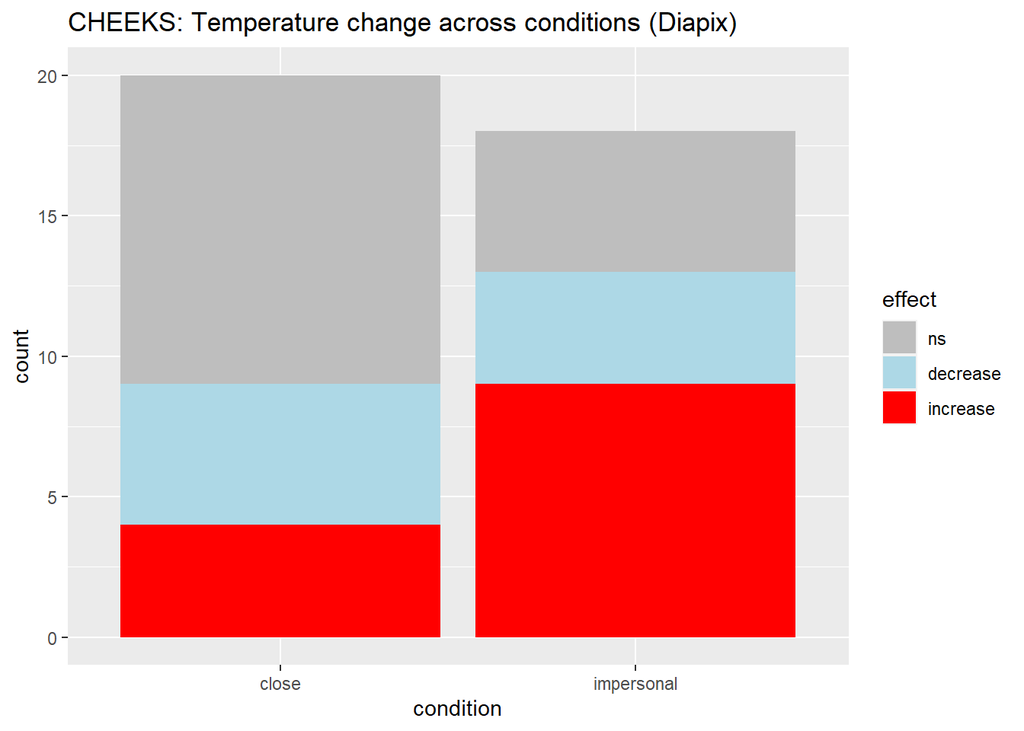

```r
ggplot(d |> filter(ROI=="Cheeks"), aes(condition, fill=effect))+
  geom_bar()+
  ggtitle("CHEEKS: Temperature change across conditions (Diapix)")+
  scale_fill_manual(values = c("decrease" = "lightblue", "increase" = "red", "ns" = "gray"))
```

Cheek temperature tended to *increase more often* in the *impersonal* condition, but the adjusted p value was above 0.05.

```r
tidy(m <- nnet::multinom(effect ~ condition, data=d |> filter(ROI=="Cheeks"))) |>
  as_tibble() |>
  mutate(estimate = plogis(estimate)) # plogis transforms log odds (the output of the model) into probabilities
```

```
## # A tibble: 4 × 6
##   y.level  term                estimate std.error statistic p.value
##   <chr>    <chr>                  <dbl>     <dbl>     <dbl>   <dbl>
## 1 decrease (Intercept)            0.313     0.539    -1.46   0.144
## 2 decrease conditionimpersonal    0.638     0.861     0.657  0.511
## 3 increase (Intercept)            0.267     0.584    -1.73   0.0832
## 4 increase conditionimpersonal    0.832     0.807     1.98   0.0476
```

```r
emmeans(m, pairwise~condition, by="effect")
```

```
## $emmeans
## effect = ns:
##  condition   prob     SE df lower.CL upper.CL
##  close      0.550 0.1112  4   0.2411    0.859
##  impersonal 0.278 0.1056  4  -0.0153    0.571
##
## effect = decrease:
##  condition   prob     SE df lower.CL upper.CL
##  close      0.250 0.0968  4  -0.0188    0.519
##  impersonal 0.222 0.0980  4  -0.0498    0.494
##
## effect = increase:
##  condition   prob     SE df lower.CL upper.CL
##  close      0.200 0.0894  4  -0.0483    0.448
##  impersonal 0.500 0.1179  4   0.1728    0.827
##
## Confidence level used: 0.95
##
## $contrasts
## effect = ns:
##  contrast           estimate    SE df t.ratio p.value
##  close - impersonal   0.2722 0.153  4   1.775  0.1506
##
## effect = decrease:
##  contrast           estimate    SE df t.ratio p.value
##  close - impersonal   0.0278 0.138  4   0.202  0.8500
##
## effect = increase:
##  contrast           estimate    SE df t.ratio p.value
##  close - impersonal  -0.3000 0.148  4  -2.028  0.1125
```

```r
summary(m <- glmer(sign ~ condition + (1|speaker), d |> filter(ROI=="Cheeks"), family=binomial))
```

```
## boundary (singular) fit: see help('isSingular')
```

```
## Generalized linear mixed model fit by maximum likelihood (Laplace
##   Approximation) [glmerMod]
##  Family: binomial  ( logit )
## Formula: sign ~ condition + (1 | speaker)
##    Data: filter(d, ROI == "Cheeks")
##
##      AIC      BIC   logLik deviance df.resid
##     54.8     59.7    -24.4     48.8       35
##
## Scaled residuals:
##     Min      1Q  Median      3Q     Max
## -1.6124 -0.9045  0.6202  0.6202  1.1055
##
## Random effects:
##  Groups  Name        Variance  Std.Dev.
##  speaker (Intercept) 1.343e-11 3.664e-06
## Number of obs: 38, groups:  speaker, 38
##
## Fixed effects:
##                     Estimate Std. Error z value Pr(>|z|)
## (Intercept)          -0.2007     0.4495  -0.446   0.6553
## conditionimpersonal   1.1562     0.6921   1.671   0.0948 .
## ---
## Signif. codes:  0 '***' 0.001 '**' 0.01 '*' 0.05 '.' 0.1 ' ' 1
##
## Correlation of Fixed Effects:
##             (Intr)
## cndtnmprsnl -0.649
## optimizer (Nelder_Mead) convergence code: 0 (OK)
## boundary (singular) fit: see help('isSingular')
```

No effect of the perception of their partner.

```r
tidy(m <- nnet::multinom(effect ~ becomeFriends, data=d |> filter(ROI=="Cheeks"))) |>
  as_tibble() |>
  mutate(estimate = plogis(estimate)) # plogis transforms log odds (the output of the model) into probabilities
```

```
## # A tibble: 4 × 6
##   y.level  term          estimate std.error statistic p.value
##   <chr>    <chr>            <dbl>     <dbl>     <dbl>   <dbl>
## 1 decrease (Intercept)      0.382     1.47    -0.326    0.744
## 2 decrease becomeFriends    0.496     0.239   -0.0671   0.946
## 3 increase (Intercept)      0.418     1.35    -0.247    0.805
## 4 increase becomeFriends    0.505     0.217    0.0970   0.923
```

```r
tidy(m <- nnet::multinom(effect ~ closeness, data=d |> filter(ROI=="Cheeks"))) |>
  as_tibble() |>
  mutate(estimate = plogis(estimate)) # plogis transforms log odds (the output of the model) into probabilities
```

```
## # A tibble: 4 × 6
##   y.level  term        estimate std.error statistic p.value
##   <chr>    <chr>          <dbl>     <dbl>     <dbl>   <dbl>
## 1 decrease (Intercept)    0.419     0.961    -0.340   0.734
## 2 decrease closeness      0.484     0.224    -0.285   0.776
## 3 increase (Intercept)    0.654     0.846     0.753   0.451
## 4 increase closeness      0.442     0.213    -1.10    0.271
```

```r
tidy(m <- nnet::multinom(effect ~ similarity, data=d |> filter(ROI=="Cheeks"))) |>
  as_tibble() |>
  mutate(estimate = plogis(estimate)) # plogis transforms log odds (the output of the model) into probabilities
```

```
## # A tibble: 4 × 6
##   y.level  term        estimate std.error statistic p.value
##   <chr>    <chr>          <dbl>     <dbl>     <dbl>   <dbl>
## 1 decrease (Intercept)    0.647     1.44      0.421   0.674
## 2 decrease similarity     0.449     0.243    -0.846   0.397
## 3 increase (Intercept)    0.794     1.30      1.04    0.300
## 4 increase similarity     0.432     0.221    -1.24    0.213
```

```r
tidy(m <- nnet::multinom(effect ~ likeability, data=d |> filter(ROI=="Cheeks"))) |>
  as_tibble() |>
  mutate(estimate = plogis(estimate)) # plogis transforms log odds (the output of the model) into probabilities
```

```
## # A tibble: 4 × 6
##   y.level  term        estimate std.error statistic p.value
##   <chr>    <chr>          <dbl>     <dbl>     <dbl>   <dbl>
## 1 decrease (Intercept)   0.0315     2.51     -1.37    0.172
## 2 decrease likeability   0.597      0.337     1.17    0.241
## 3 increase (Intercept)   0.803      1.81      0.777   0.437
## 4 increase likeability   0.440      0.267    -0.910   0.363
```

Cheek temperature tended to *increase less often* when the speaker scored higher in agreeableness, but the pairwise comparison isn’t computing. And the effect also seems rather small.

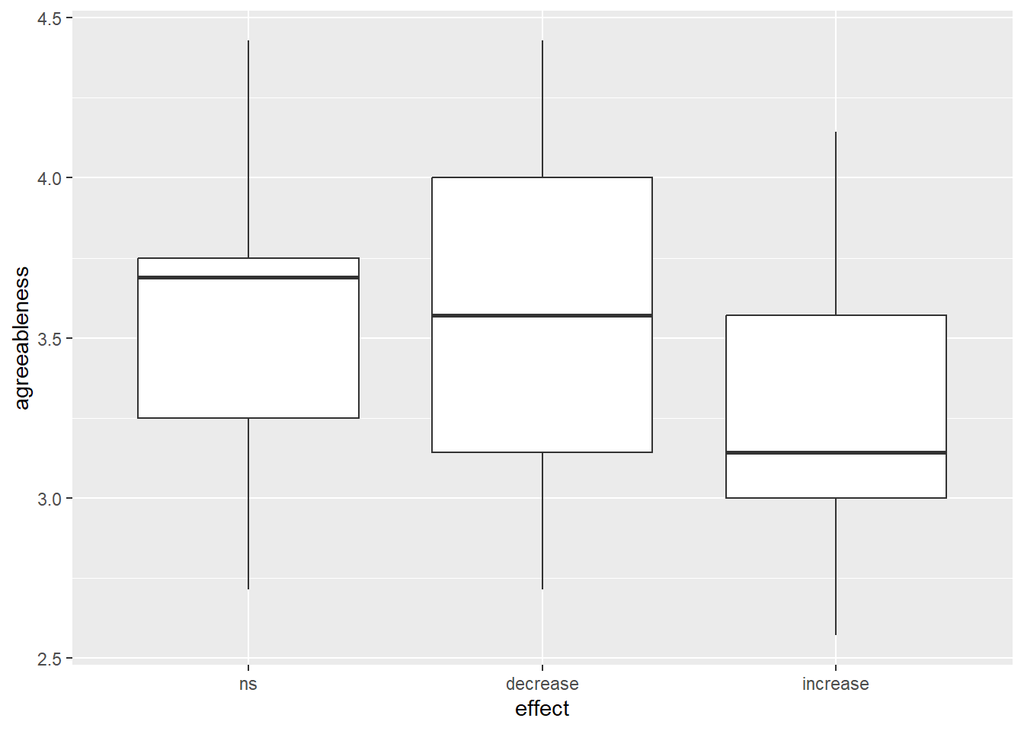

```r
ggplot(d |> filter(ROI=="Cheeks"), aes(effect, agreeableness))+
  geom_boxplot()
```

```r
tidy(m <- nnet::multinom(effect ~ agreeableness, data=d |> filter(ROI=="Cheeks"))) |>
  as_tibble() |>
  mutate(estimate = plogis(estimate)) # plogis transforms log odds (the output of the model) into probabilities
```

```
## # A tibble: 4 × 6
##   y.level  term          estimate std.error statistic p.value
##   <chr>    <chr>            <dbl>     <dbl>     <dbl>   <dbl>
## 1 decrease (Intercept)      0.303     3.11    -0.268   0.789
## 2 decrease agreeableness    0.518     0.855    0.0830  0.934
## 3 increase (Intercept)      0.997     2.97     1.91    0.0559
## 4 increase agreeableness    0.149     0.878   -1.98    0.0473
```

```r
tidy(m <- nnet::multinom(effect ~ extraversion, data=d |> filter(ROI=="Cheeks"))) |>
  as_tibble() |>
  mutate(estimate = plogis(estimate)) # plogis transforms log odds (the output of the model) into probabilities
```

```
## # A tibble: 4 × 6
##   y.level  term         estimate std.error statistic p.value
##   <chr>    <chr>           <dbl>     <dbl>     <dbl>   <dbl>
## 1 decrease (Intercept)    0.0154     2.77     -1.50    0.134
## 2 decrease extraversion   0.729      0.749     1.32    0.186
## 3 increase (Intercept)    0.872      2.33      0.824   0.410
## 4 increase extraversion   0.346      0.691    -0.921   0.357
```

```r
tidy(m <- nnet::multinom(effect ~ openness, data=d |> filter(ROI=="Cheeks"))) |>
  as_tibble() |>
  mutate(estimate = plogis(estimate)) # plogis transforms log odds (the output of the model) into probabilities
```

```
## # A tibble: 4 × 6
##   y.level  term        estimate std.error statistic p.value
##   <chr>    <chr>          <dbl>     <dbl>     <dbl>   <dbl>
## 1 decrease (Intercept)    0.115     1.99    -1.03     0.305
## 2 decrease openness       0.600     0.532    0.761    0.446
## 3 increase (Intercept)    0.511     1.64     0.0261   0.979
## 4 increase openness       0.482     0.462   -0.157    0.875
```

```r
tidy(m <- nnet::multinom(effect ~ conscientiousness, data=d |> filter(ROI=="Cheeks"))) |>
  as_tibble() |>
  mutate(estimate = plogis(estimate)) # plogis transforms log odds (the output of the model) into probabilities
```

```
## # A tibble: 4 × 6
##   y.level  term              estimate std.error statistic p.value
##   <chr>    <chr>                <dbl>     <dbl>     <dbl>   <dbl>
## 1 decrease (Intercept)        0.00371     4.15      -1.35   0.177
## 2 decrease conscientiousness  0.768       0.973      1.23   0.218
## 3 increase (Intercept)        0.952       2.72       1.10   0.272
## 4 increase conscientiousness  0.307       0.687     -1.19   0.235
```

```r
tidy(m <- nnet::multinom(effect ~ neuroticism, data=d |> filter(ROI=="Cheeks"))) |>
  as_tibble() |>
  mutate(estimate = plogis(estimate)) # plogis transforms log odds (the output of the model) into probabilities
```

```
## # A tibble: 4 × 6
##   y.level  term        estimate std.error statistic p.value
##   <chr>    <chr>          <dbl>     <dbl>     <dbl>   <dbl>
## 1 decrease (Intercept)    0.110     1.95     -1.07    0.285
## 2 decrease neuroticism    0.617     0.592     0.802   0.423
## 3 increase (Intercept)    0.306     1.67     -0.490   0.624
## 4 increase neuroticism    0.549     0.522     0.376   0.707
```

No effect of thermal comfort

```r
tidy(m <- nnet::multinom(effect ~ comfortPre, data=d |> filter(ROI=="Cheeks"))) |>
  as_tibble() |>
  mutate(estimate = plogis(estimate)) # plogis transforms log odds (the output of the model) into probabilities
```

```
## # A tibble: 4 × 6
##   y.level  term        estimate std.error statistic p.value
##   <chr>    <chr>          <dbl>     <dbl>     <dbl>   <dbl>
## 1 decrease (Intercept)    0.880     2.44      0.815   0.415
## 2 decrease comfortPre     0.397     0.396    -1.06    0.291
## 3 increase (Intercept)    0.898     2.21      0.988   0.323
## 4 increase comfortPre     0.404     0.355    -1.09    0.274
```

```r
tidy(m <- nnet::multinom(effect ~ comfortPost, data=d |> filter(ROI=="Cheeks"))) |>
  as_tibble() |>
  mutate(estimate = plogis(estimate)) # plogis transforms log odds (the output of the model) into probabilities
```

```
## # A tibble: 4 × 6
##   y.level  term        estimate std.error statistic p.value
##   <chr>    <chr>          <dbl>     <dbl>     <dbl>   <dbl>
## 1 decrease (Intercept)    0.657     2.37      0.274   0.784
## 2 decrease comfortPost    0.449     0.391    -0.521   0.602
## 3 increase (Intercept)    0.840     2.15      0.770   0.441
## 4 increase comfortPost    0.422     0.358    -0.877   0.381
```

## All speakers together

### Temperature across time

#### Nose

Nose got warmer across time, no difference between conditions.

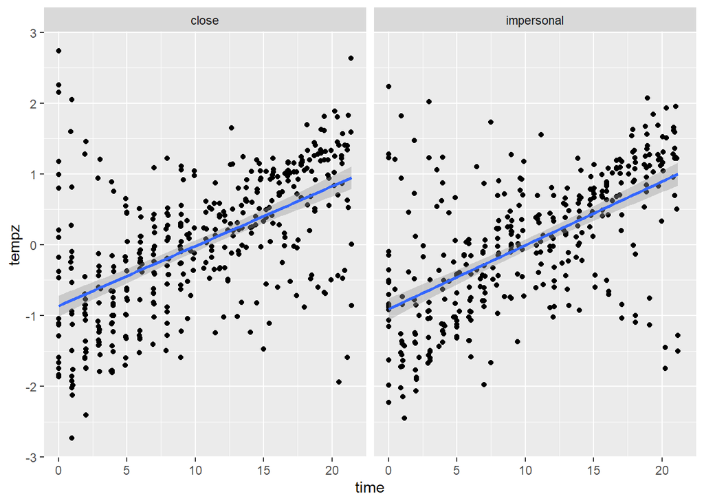

```r
ggplot(dat |> filter(ROI=="Nose"), aes(time, tempz))+
  geom_point()+
  geom_smooth(method="lm")+
  facet_wrap(~condition)
```

```r
summary(m0 <- lmer(tempz ~ time + (time||speaker) , dat |> filter(ROI=="Nose")))
```

```
## Linear mixed model fit by REML. t-tests use Satterthwaite's method [
## lmerModLmerTest]
## Formula: tempz ~ time + (time || speaker)
##    Data: filter(dat, ROI == "Nose")
##
## REML criterion at convergence: 1615.2
##
## Scaled residuals:
##     Min      1Q  Median      3Q     Max
## -2.8920 -0.5915  0.0331  0.5705  4.0661
##
## Random effects:
##  Groups    Name        Variance Std.Dev.
##  speaker   (Intercept) 0.749356 0.8657
##  speaker.1 time        0.008779 0.0937
##  Residual              0.331481 0.5757
## Number of obs: 777, groups:  speaker, 38
##
## Fixed effects:
##             Estimate Std. Error       df t value Pr(>|t|)
## (Intercept) -0.91250    0.14597 36.76013  -6.251 2.95e-07 ***
## time         0.09265    0.01571 33.31683   5.898 1.26e-06 ***
## ---
## Signif. codes:  0 '***' 0.001 '**' 0.01 '*' 0.05 '.' 0.1 ' ' 1
##
## Correlation of Fixed Effects:
##      (Intr)
## time -0.055
```

```r
summary(m1 <- lmer(tempz ~ time + roomTemp + (time||speaker) , dat |> filter(ROI=="Nose")))
```

```
## Linear mixed model fit by REML. t-tests use Satterthwaite's method [
## lmerModLmerTest]
## Formula: tempz ~ time + roomTemp + (time || speaker)
##    Data: filter(dat, ROI == "Nose")
##
## REML criterion at convergence: 1603.8
##
## Scaled residuals:
##     Min      1Q  Median      3Q     Max
## -2.9176 -0.5993  0.0381  0.5629  4.1424
##
## Random effects:
##  Groups    Name        Variance Std.Dev.
##  speaker   (Intercept) 0.439810 0.66318
##  speaker.1 time        0.007943 0.08912
##  Residual              0.334602 0.57845
## Number of obs: 777, groups:  speaker, 38
##
## Fixed effects:
##             Estimate Std. Error       df t value Pr(>|t|)
## (Intercept)  4.17419    1.12237 36.85494   3.719 0.000663 ***
## time         0.09522    0.01500 33.27326   6.349 3.35e-07 ***
## roomTemp    -0.20134    0.04419 36.74832  -4.557 5.57e-05 ***
## ---
## Signif. codes:  0 '***' 0.001 '**' 0.01 '*' 0.05 '.' 0.1 ' ' 1
##
## Correlation of Fixed Effects:
##          (Intr) time
## time      0.027
## roomTemp -0.995 -0.034
```

```r
summary(m2 <- lmer(tempz ~ time : condition + roomTemp + (time||speaker) , dat |> filter(ROI=="Nose")))
```

```
## Linear mixed model fit by REML. t-tests use Satterthwaite's method [
## lmerModLmerTest]
## Formula: tempz ~ time:condition + roomTemp + (time || speaker)
##    Data: filter(dat, ROI == "Nose")
##
## REML criterion at convergence: 1609
##
## Scaled residuals:
##     Min      1Q  Median      3Q     Max
## -2.9161 -0.5991  0.0361  0.5646  4.1410
##
## Random effects:
##  Groups    Name        Variance Std.Dev.
##  speaker   (Intercept) 0.443265 0.66578
##  speaker.1 time        0.008211 0.09061
##  Residual              0.334398 0.57827
## Number of obs: 777, groups:  speaker, 38
##
## Fixed effects:
##                          Estimate Std. Error       df t value Pr(>|t|)
## (Intercept)               4.16514    1.12640 36.87685   3.698 0.000704 ***
## roomTemp                 -0.20098    0.04435 36.77017  -4.532 5.99e-05 ***
## time:conditionclose       0.09837    0.02094 32.13811   4.699 4.72e-05 ***
## time:conditionimpersonal  0.09168    0.02213 32.42624   4.143 0.000230 ***
## ---
## Signif. codes:  0 '***' 0.001 '**' 0.01 '*' 0.05 '.' 0.1 ' ' 1
##
## Correlation of Fixed Effects:
##             (Intr) romTmp tm:cndtnc
## roomTemp    -0.995
## tm:cndtncls  0.006 -0.012
## tm:cndtnmpr  0.032 -0.037  0.003
```

```r
anova(m0, m1)
```

```
## refitting model(s) with ML (instead of REML)
```

```
## Data: filter(dat, ROI == "Nose")
## Models:
## m0: tempz ~ time + (time || speaker)
## m1: tempz ~ time + roomTemp + (time || speaker)
##    npar    AIC    BIC  logLik deviance  Chisq Df Pr(>Chisq)
## m0    5 1616.7 1639.9 -803.33   1606.7
## m1    6 1602.3 1630.2 -795.15   1590.3 16.367  1  5.217e-05 ***
## ---
## Signif. codes:  0 '***' 0.001 '**' 0.01 '*' 0.05 '.' 0.1 ' ' 1
```

```r
anova(m1, m2)
```

```
## refitting model(s) with ML (instead of REML)
```

```
## Data: filter(dat, ROI == "Nose")
## Models:
## m1: tempz ~ time + roomTemp + (time || speaker)
## m2: tempz ~ time:condition + roomTemp + (time || speaker)
##    npar    AIC    BIC  logLik deviance  Chisq Df Pr(>Chisq)
## m1    6 1602.3 1630.2 -795.15   1590.3
## m2    7 1604.2 1636.8 -795.13   1590.2 0.0442  1     0.8335
```